# SVA Model 1

**CTL vs AD:**  
17 probes pass the epigenome-wide significance threshold of 2.4x10-7  
*The top 50 CTL vs AD associated DMPs:*

| ProbeID | Position | F | p (F) | FDR.Anova | Difference | CI lower | CI upper | pCvM | FDR | Difference | CI lower | CI upper | pCvA | FDR | Difference | CI lower | CI upper | pMvA | FDR | UCSC Gene | UCSC Gene Group | UCSC Relation to CpG Island | Gene Closest TSS | Distance Closest TSS | GREAT Annotation 1 | GREAT Annotation 2 |
| --- | --- | --- | --- | --- | --- | --- | --- | --- | --- | --- | --- | --- | --- | --- | --- | --- | --- | --- | --- | --- | --- | --- | --- | --- | --- | --- |
| cg22822140 | chr X: 153046577 | 60.112 | 2.16e-20 | 2.09e-16 | 9.33e-04 | -0.021 | 0.023 | 0.994 | 1 | -0.087 | -0.109 | -0.065 | 4.83e-14 | 4.66e-10 | -0.088 | -0.11 | -0.067 | 4.90e-14 | 1.29e-10 | SRPK3;SRPK3;SRPK3 | 1stExon;1stExon;1stExon | Island | SRPK3 | 122 | SRPK3 (122) | (NA) |
| cg24496423 | chr X: 153046480 | 47.202 | 5.64e-17 | 1.81e-13 | 0.006 | -0.014 | 0.025 | 0.76 | 1 | -0.066 | -0.086 | -0.047 | 7.65e-13 | 3.04e-09 | -0.072 | -0.092 | -0.053 | 5.34e-14 | 1.29e-10 | SRPK3;SRPK3;SRPK3;SRPK3;SRPK3;SRPK3 | 5'UTR;1stExon;1stExon;5'UTR;5'UTR;1stExon | Island | SRPK3 | 25 | SRPK3 (25) | (NA) |
| cg12230162 | chr X: 153046482 | 47.713 | 4.07e-17 | 1.81e-13 | 0.01 | -0.015 | 0.034 | 0.621 | 1 | -0.083 | -0.108 | -0.058 | 1.23e-12 | 3.04e-09 | -0.093 | -0.117 | -0.068 | 5.05e-14 | 1.29e-10 | SRPK3;SRPK3;SRPK3;SRPK3;SRPK3;SRPK3 | 5'UTR;1stExon;1stExon;5'UTR;5'UTR;1stExon | Island | SRPK3 | 27 | SRPK3 (27) | (NA) |
| cg12468189 | chr X: 153046767 | 31.199 | 3.07e-12 | 3.29e-09 | -0.023 | -0.038 | -0.008 | 0.002 | 0.076 | -0.052 | -0.067 | -0.036 | 1.26e-12 | 3.04e-09 | -0.029 | -0.044 | -0.014 | 4.33e-05 | 0.008 | SRPK3;SRPK3;SRPK3 | Body;Body;Body | Island | SRPK3 | 312 | SRPK3 (312) | (NA) |
| cg19938385 | chr X: 107020894 | 29.767 | 8.77e-12 | 7.87e-09 | -0.047 | -0.065 | -0.029 | 2.09e-08 | 1.83e-05 | -0.056 | -0.074 | -0.037 | 6.72e-11 | 1.30e-07 | -0.009 | -0.027 | 0.009 | 0.474 | 1 |  |  | S_Shore | TSC22D3 | -1692 | TSC22D3 (-1878) | (NA) |
| cg16529483 | chr X: 153046451 | 32.446 | 1.25e-12 | 2.00e-09 | -0.004 | -0.028 | 0.02 | 0.914 | 1 | -0.073 | -0.098 | -0.049 | 9.07e-11 | 1.46e-07 | -0.069 | -0.093 | -0.045 | 4.24e-10 | 4.54e-07 | SRPK3;SRPK3;SRPK3 | TSS200;TSS200;TSS200 | Island | SRPK3 | -4 | SRPK3 (-4) | (NA) |
| cg17405188 | chr X: 73164102 | 24.952 | 3.30e-10 | 2.12e-07 | 0.006 | 0.001 | 0.011 | 0.008 | 0.196 | 0.014 | 0.009 | 0.019 | 1.49e-10 | 2.05e-07 | 0.008 | 0.003 | 0.013 | 1.75e-04 | 0.021 | LOC554203 | TSS200 | Island | JPX | -56 | ZCCHC13 (-359922) | CHIC1 (381119) |
| cg07344627 | chr X: 125687011 | 20.491 | 1.10e-08 | 3.93e-06 | -0.033 | -0.056 | -0.01 | 0.003 | 0.106 | -0.064 | -0.087 | -0.040 | 4.50e-09 | 5.42e-06 | -0.031 | -0.054 | -0.008 | 0.006 | 0.203 | DCAF12L1 | TSS200 | S_Shore | DCAF12L1 | -169 | DCAF12L1 (-170) | (NA) |
| cg12039689 | chr X: 153141750 | 20.988 | 7.39e-09 | 2.85e-06 | -0.018 | -0.039 | 0.002 | 0.096 | 0.681 | -0.056 | -0.077 | -0.035 | 6.24e-09 | 6.69e-06 | -0.038 | -0.058 | -0.017 | 6.86e-05 | 0.011 | L1CAM;L1CAM;L1CAM | TSS1500;TSS1500;TSS1500 |  | L1CAM | -351 | L1CAM (-352) | (NA) |
| cg04710661 | chr X: 2848381 | 18.813 | 4.28e-08 | 1.15e-05 | 0.007 | 3.33e-06 | 0.014 | 0.05 | 0.51 | 0.018 | 0.011 | 0.024 | 2.45e-08 | 2.25e-05 | 0.011 | 0.004 | 0.018 | 5.83e-04 | 0.049 | ARSD;ARSD | TSS1500;TSS1500 | S_Shore | ARSD | -965 | ARSD (-966) | (NA) |
| cg09661041 | chr X: 153141905 | 23.013 | 1.49e-09 | 7.97e-07 | -0.005 | -0.028 | 0.018 | 0.878 | 1 | -0.060 | -0.084 | -0.037 | 2.56e-08 | 2.25e-05 | -0.055 | -0.078 | -0.032 | 1.72e-07 | 8.76e-05 | L1CAM;L1CAM;L1CAM | TSS1500;TSS1500;TSS1500 |  | L1CAM | -506 | L1CAM (-507) | (NA) |
| cg22574818 | chr X: 55479616 | 18.027 | 8.15e-08 | 2.07e-05 | -0.031 | -0.054 | -0.008 | 0.004 | 0.14 | -0.059 | -0.082 | -0.036 | 3.53e-08 | 2.84e-05 | -0.028 | -0.051 | -0.005 | 0.013 | 0.324 | MAGEH1;MAGEH1 | 1stExon;3'UTR |  | MAGEH1 | 1079 | MAGEH1 (1079) | USP51 (36014) |
| cg23914849 | chr X: 52950051 | 17.393 | 1.38e-07 | 3.16e-05 | 0.003 | 5.73e-04 | 0.005 | 0.009 | 0.208 | 0.006 | 0.003 | 0.008 | 5.96e-08 | 4.42e-05 | 0.003 | 5.96e-04 | 0.005 | 0.009 | 0.258 |  |  | Island | FAM156A | 13799 | FAM156B (21967) | FAM156A (74599) |
| cg09768654 | chr X: 153046386 | 29.736 | 8.98e-12 | 7.87e-09 | 0.012 | -0.01 | 0.035 | 0.403 | 1 | -0.057 | -0.080 | -0.034 | 6.61e-08 | 4.56e-05 | -0.07 | -0.092 | -0.047 | 3.85e-11 | 5.30e-08 | SRPK3;SRPK3;SRPK3 | TSS200;TSS200;TSS200 | Island | SRPK3 | -69 | SRPK3 (-69) | (NA) |
| cg04768884 | chr X: 19443172 | 19.767 | 1.97e-08 | 5.97e-06 | 0.005 | -0.009 | 0.019 | 0.638 | 1 | 0.035 | 0.020 | 0.049 | 9.20e-08 | 5.92e-05 | 0.029 | 0.015 | 0.043 | 4.21e-06 | 0.001 | MAP3K15 | Body |  | MAP3K15 | 35099 | PDHA1 (81162) | MAP3K15 (90206) |
| cg00072799 | chr X: 78427682 | 18.807 | 4.30e-08 | 1.15e-05 | -0.007 | -0.021 | 0.007 | 0.477 | 1 | -0.034 | -0.048 | -0.020 | 1.12e-07 | 6.77e-05 | -0.027 | -0.041 | -0.014 | 1.59e-05 | 0.003 | GPR174;GPR174 | 1stExon;3'UTR |  | GPR174 | 1214 | GPR174 (1214) | ITM2A (195366) |
| cg00779763 | chr X: 47479114 | 16.395 | 3.15e-07 | 6.21e-05 | 0.009 | -9.50e-04 | 0.019 | 0.085 | 0.653 | 0.024 | 0.014 | 0.034 | 1.94e-07 | 1.10e-04 | 0.015 | 0.005 | 0.025 | 0.001 | 0.079 | SYN1;SYN1 | 1stExon;1stExon | Island | SYN1 | 142 | SYN1 (141) | (NA) |
| cg21364342 | chr X: 107226611 | 18.224 | 6.93e-08 | 1.81e-05 | -0.019 | -0.027 | -0.01 | 5.77e-06 | 0.002 | -0.021 | -0.030 | -0.012 | 3.96e-07 | 2.12e-04 | -0.002 | -0.011 | 0.006 | 0.792 | 1 | TEX13B | TSS1500 |  | TEX13B | -1011 | VSIG1 (-61588) | MID2 (157528) |
| cg06616051 | chr X: 153094332 | 15.425 | 7.13e-07 | 1.23e-04 | 0.015 | -0.003 | 0.032 | 0.111 | 0.733 | 0.041 | 0.023 | 0.059 | 4.62e-07 | 2.35e-04 | 0.026 | 0.009 | 0.043 | 0.001 | 0.089 | PDZD4 | Body | Island | PDZD4 | 1019 | IDH3G (-34366) | PDZD4 (1670) |
| cg00805156 | chr X: 3264341 | 17.487 | 1.27e-07 | 2.99e-05 | 0.034 | 0.017 | 0.051 | 9.27e-06 | 0.002 | 0.039 | 0.022 | 0.055 | 6.64e-07 | 3.20e-04 | 0.005 | -0.012 | 0.021 | 0.793 | 1 | MXRA5 | 5'UTR | Island | MXRA5 | 343 | MXRA5 (342) | (NA) |
| cg11138004 | chr X: 154283466 | 14.774 | 1.24e-06 | 1.92e-04 | 0.006 | -0.002 | 0.014 | 0.165 | 0.86 | 0.018 | 0.010 | 0.027 | 9.24e-07 | 4.25e-04 | 0.012 | 0.004 | 0.020 | 0.001 | 0.081 | FUNDC2 | 3'UTR |  | MTCP1 | 16081 | MTCP1NB (16080) | FUNDC2 (28403) |
| cg06068202 | chr X: 150343148 | 15.965 | 4.52e-07 | 8.55e-05 | 0.034 | 0.016 | 0.053 | 4.56e-05 | 0.007 | 0.041 | 0.023 | 0.060 | 1.27e-06 | 5.58e-04 | 0.007 | -0.011 | 0.025 | 0.652 | 1 |  |  | Island | GPR50 | -1907 | GPR50 (-1907) | (NA) |
| cg02329520 | chr X: 153740317 | 14.912 | 1.10e-06 | 1.77e-04 | -0.013 | -0.02 | -0.005 | 3.01e-04 | 0.023 | -0.017 | -0.025 | -0.009 | 1.38e-06 | 5.78e-04 | -0.004 | -0.012 | 0.003 | 0.374 | 1 | FAM3A;FAM3A;FAM3A;FAM3A;FAM3A | Body;Body;Body;Body;Body | N_Shelf | FAM3A | 4249 | SLC10A3 (-21316) | FAM3A (4248) |
| cg24352688 | chr X: 13751727 | 16.663 | 2.52e-07 | 5.18e-05 | 0.002 | -0.005 | 0.009 | 0.832 | 1 | 0.015 | 0.008 | 0.022 | 1.48e-06 | 5.94e-04 | 0.014 | 0.007 | 0.021 | 1.33e-05 | 0.003 | TRAPPC2;OFD1;TRAPPC2;TRAPPC2 | 5'UTR;TSS1500;5'UTR;5'UTR | N_Shore | TRAPPC2 | 1027 | OFD1 (-1104) | TRAPPC2 (1026) |
| cg25896901 | chr X: 125300481 | 22.689 | 1.92e-09 | 9.61e-07 | 0.011 | -0.015 | 0.036 | 0.572 | 1 | -0.057 | -0.082 | -0.031 | 1.65e-06 | 6.19e-04 | -0.067 | -0.093 | -0.042 | 7.06e-09 | 6.19e-06 | DCAF12L2 | TSS1500 | S_Shore | DCAF12L2 | -401 | DCAF12L1 (386360) | (NA) |
| cg00928753 | chr X: 36976515 | 13.702 | 3.09e-06 | 4.04e-04 | 0.019 | -0.001 | 0.04 | 0.075 | 0.615 | 0.046 | 0.025 | 0.067 | 1.67e-06 | 6.19e-04 | 0.027 | 0.006 | 0.048 | 0.007 | 0.221 |  |  | S_Shore | FAM47C | -49916 | PRRG1 (-232012) | CXorf59 (911463) |
| cg20814574 | chr X: 92928640 | 14.152 | 2.10e-06 | 2.98e-04 | 0.003 | -0.002 | 0.009 | 0.276 | 1 | 0.012 | 0.006 | 0.017 | 2.04e-06 | 7.27e-04 | 0.008 | 0.003 | 0.014 | 8.24e-04 | 0.061 | FAM133A;FAM133A;NAP1L3;FAM133A;FAM133A | TSS1500;TSS1500;TSS200;TSS1500;TSS1500 | Island | NAP1L3 | 42 | NAP1L3 (41) | (NA) |
| cg16170760 | chr X: 153708103 | 13.034 | 5.50e-06 | 5.96e-04 | -0.007 | -0.015 | 0.001 | 0.122 | 0.755 | -0.018 | -0.026 | -0.009 | 3.33e-06 | 0.001 | -0.011 | -0.019 | -0.003 | 0.005 | 0.191 | LAGE3 | TSS1500 | S_Shore | LAGE3 | -507 | LAGE3 (-508) | (NA) |
| cg16122592 | chr X: 26210712 | 21.001 | 7.31e-09 | 2.85e-06 | -0.03 | -0.041 | -0.018 | 1.83e-08 | 1.76e-05 | -0.024 | -0.036 | -0.013 | 5.64e-06 | 0.002 | 0.005 | -0.006 | 0.017 | 0.495 | 1 | MAGEB6 | 5'UTR |  | MAGEB6 | 156 | MAGEB6 (156) | (NA) |
| cg08850124 | chr X: 118207749 | 13.271 | 4.48e-06 | 5.21e-04 | -0.011 | -0.018 | -0.004 | 6.23e-04 | 0.04 | -0.015 | -0.022 | -0.008 | 5.66e-06 | 0.002 | -0.004 | -0.01 | 0.003 | 0.442 | 1 |  |  | Island | KIAA1210 | 76793 | PGRMC1 (-162461) | LONRF3 (99037) |
| cg01975035 | chr X: 24761808 | 12.513 | 8.63e-06 | 8.50e-04 | -0.007 | -0.017 | 0.002 | 0.162 | 0.854 | -0.020 | -0.030 | -0.011 | 5.67e-06 | 0.002 | -0.013 | -0.022 | -0.003 | 0.005 | 0.188 | SCARNA23;POLA1 | TSS1500;Body |  | SCARNA23 | -749 | POLA1 (49745) | ARX (272256) |
| cg00123001 | chr X: 13395880 | 15.726 | 5.53e-07 | 9.88e-05 | -0.015 | -0.022 | -0.008 | 8.64e-06 | 0.002 | -0.015 | -0.023 | -0.008 | 6.54e-06 | 0.002 | -3.92e-04 | -0.008 | 0.007 | 0.991 | 1 |  |  | N_Shore | LOC100133123 | 42521 | EGFL6 (-191813) | ATXN3L (-57363) |
| cg16975981 | chr X: 55246829 | 14.569 | 1.47e-06 | 2.22e-04 | -0.004 | -0.019 | 0.012 | 0.849 | 1 | -0.033 | -0.048 | -0.017 | 6.86e-06 | 0.002 | -0.029 | -0.045 | -0.014 | 4.97e-05 | 0.009 | PAGE5;PAGE5;PAGE5;PAGE5 | 5'UTR;5'UTR;1stExon;1stExon |  | PAGE5 | 38 | MAGEH1 (-231708) | MTRNR2L10 (-37886) |
| ch.X.1639000R | chr X: 113225430 | 11.916 | 1.45e-05 | 0.001 | 0.007 | 1.08e-04 | 0.013 | 0.045 | 0.489 | 0.014 | 0.007 | 0.020 | 7.31e-06 | 0.002 | 0.007 | 5.17e-04 | 0.014 | 0.031 | 0.514 |  |  |  | HTR2C | -593120 | HTR2C (-593120) | (NA) |
| cg23247524 | chr X: 35816354 | 12.545 | 8.40e-06 | 8.35e-04 | -0.025 | -0.042 | -0.008 | 0.002 | 0.076 | -0.035 | -0.051 | -0.018 | 8.13e-06 | 0.002 | -0.01 | -0.026 | 0.007 | 0.348 | 1 | MAGEB16 | TSS200 |  | MAGEB16 | -104 | CXorf59 (-248698) | (NA) |
| cg09513996 | chr X: 48685182 | 20.316 | 1.27e-08 | 4.21e-06 | 0.006 | -0.007 | 0.02 | 0.486 | 1 | -0.027 | -0.041 | -0.014 | 1.03e-05 | 0.003 | -0.034 | -0.047 | -0.021 | 2.90e-08 | 1.75e-05 |  |  | Island | ERAS | -2100 | ERAS (-2100) | (NA) |
| cg26101161 | chr X: 122736584 | 14.280 | 1.88e-06 | 2.71e-04 | -0.017 | -0.025 | -0.008 | 4.20e-05 | 0.006 | -0.018 | -0.027 | -0.009 | 1.05e-05 | 0.003 | -0.001 | -0.01 | 0.007 | 0.92 | 1 | THOC2 | 3'UTR |  | THOC2 | 8230 | THOC2 (130319) | GRIA3 (418489) |
| cg20784188 | chr X: 44703983 | 15.494 | 6.72e-07 | 1.18e-04 | 3.07e-04 | -0.009 | 0.01 | 0.997 | 1 | -0.020 | -0.030 | -0.010 | 1.32e-05 | 0.003 | -0.02 | -0.03 | -0.010 | 6.57e-06 | 0.002 | DUSP21;DUSP21 | 3'UTR;1stExon | S_Shore | DUSP21 | 735 | DUSP21 (735) | (NA) |
| cg13145750 | chr X: 110512115 | 12.704 | 7.32e-06 | 7.43e-04 | -0.017 | -0.028 | -0.007 | 3.97e-04 | 0.029 | -0.021 | -0.032 | -0.011 | 1.39e-05 | 0.003 | -0.004 | -0.014 | 0.006 | 0.646 | 1 | CAPN6 | 5'UTR |  | CAPN6 | 1659 | CAPN6 (1658) | PAK3 (145811) |
| cg07069575 | chr X: 49688313 | 21.219 | 6.15e-09 | 2.58e-06 | 0.007 | -0.005 | 0.019 | 0.324 | 1 | -0.024 | -0.036 | -0.012 | 1.43e-05 | 0.003 | -0.031 | -0.042 | -0.019 | 9.67e-09 | 7.77e-06 | CLCN5;CLCN5 | 5'UTR;5'UTR | S_Shore | CLCN5 | 1089 | CLCN5 (1089) | AKAP4 (277350) |
| cg21179255 | chr X: 152772707 | 11.812 | 1.59e-05 | 0.001 | -0.006 | -0.016 | 0.004 | 0.331 | 1 | -0.021 | -0.031 | -0.010 | 1.46e-05 | 0.003 | -0.015 | -0.025 | -0.004 | 0.003 | 0.134 | BGN | Body |  | HAUS7 | -11729 | ATP2B3 (-28872) | BGN (12361) |
| cg13492609 | chr X: 151308320 | 11.250 | 2.61e-05 | 0.002 | -0.008 | -0.018 | 0.002 | 0.133 | 0.779 | -0.020 | -0.029 | -0.010 | 1.54e-05 | 0.004 | -0.012 | -0.021 | -0.002 | 0.013 | 0.335 | MAGEA10;MAGEA10 | TSS1500;TSS1500 |  | MAGEA10 | -1270 | MAGEA5 (-21910) | GABRA3 (311510) |
| cg02754763 | chr X: 44403388 | 15.396 | 7.30e-07 | 1.24e-04 | 7.18e-04 | -0.006 | 0.008 | 0.967 | 1 | -0.014 | -0.021 | -0.007 | 2.09e-05 | 0.005 | -0.014 | -0.021 | -0.008 | 4.95e-06 | 0.001 | FUNDC1 | TSS1500 |  | FUNDC1 | -1167 | DUSP21 (-299860) | EFHC2 (-200466) |
| cg02048654 | chr X: 132551786 | 11.120 | 2.93e-05 | 0.002 | 0.017 | -0.009 | 0.044 | 0.281 | 1 | 0.053 | 0.026 | 0.080 | 2.31e-05 | 0.005 | 0.036 | 0.009 | 0.062 | 0.005 | 0.191 |  |  | S_Shore | GPC4 | -2581 | GPC4 (-2582) | (NA) |
| cg14403309 | chr X: 37213086 | 10.639 | 4.48e-05 | 0.003 | -0.014 | -0.027 | -9.27e-04 | 0.033 | 0.417 | -0.026 | -0.039 | -0.013 | 2.38e-05 | 0.005 | -0.012 | -0.025 | 0.001 | 0.084 | 0.836 | PRRG1;PRRG1 | 5'UTR;5'UTR | S_Shelf | PRRG1 | 4504 | LANCL3 (-217735) | PRRG1 (4559) |
| cg14295696 | chr X: 135230717 | 10.677 | 4.33e-05 | 0.003 | -0.011 | -0.019 | -0.002 | 0.017 | 0.288 | -0.018 | -0.027 | -0.009 | 2.54e-05 | 0.005 | -0.007 | -0.016 | 0.002 | 0.148 | 1 | FHL1;FHL1;FHL1;FHL1;FHL1 | Body;5'UTR;5'UTR;5'UTR;TSS200 | S_Shore | FHL1 | -19 | FHL1 (1159) | MAP7D3 (103020) |
| cg22964346 | chr X: 109411307 | 11.264 | 2.58e-05 | 0.002 | -0.007 | -0.012 | -0.002 | 0.003 | 0.1 | -0.010 | -0.015 | -0.005 | 2.60e-05 | 0.005 | -0.003 | -0.008 | 0.002 | 0.418 | 1 | TMEM164;TMEM164 | Body;Body |  | SNORD96B | 56981 | AMMECR1 (150072) | TMEM164 (164966) |
| cg25877387 | chr X: 49965358 | 11.234 | 2.64e-05 | 0.002 | -0.014 | -0.024 | -0.004 | 0.002 | 0.099 | -0.019 | -0.029 | -0.009 | 2.74e-05 | 0.006 | -0.005 | -0.015 | 0.005 | 0.433 | 1 | AKAP4;AKAP4 | TSS1500;Body |  | AKAP4 | 306 | AKAP4 (305) | (NA) |
| cg14736837 | chr X: 15333837 | 11.130 | 2.90e-05 | 0.002 | -0.017 | -0.029 | -0.005 | 0.002 | 0.099 | -0.023 | -0.035 | -0.011 | 3.07e-05 | 0.006 | -0.006 | -0.018 | 0.006 | 0.448 | 1 | ASB11;ASB11 | TSS1500;TSS200 |  | ASB11 | -91 | ASB11 (-92) | (NA) |
| cg25549901 | chr X: 137951118 | 16.261 | 3.53e-07 | 6.81e-05 | -0.021 | -0.031 | -0.012 | 1.16e-06 | 4.68e-04 | -0.019 | -0.028 | -0.009 | 3.14e-05 | 0.006 | 0.003 | -0.007 | 0.012 | 0.772 | 1 | FGF13;FGF13;FGF13;FGF13 | 5'UTR;Body;TSS1500;Body |  | FGF13 | -1401 | FGF13 (336066) | (NA) |

**MCI vs AD:**  
19 probes pass the epigenome-wide significance threshold of 2.4x10-7

*The top 50 MCI vs AD associated DMPs:*

| ProbeID | Position | F | p (F) | FDR.Anova | Difference | CI lower | CI upper | pCvM | FDR | Difference | CI lower | CI upper | pCvA | FDR | Difference | CI lower | CI upper | pMvA | FDR | UCSC Gene | UCSC Gene Group | UCSC Relation to CpG Island | Gene Closest TSS | Distance Closest TSS | GREAT Annotation 1 | GREAT Annotation 2 |
| --- | --- | --- | --- | --- | --- | --- | --- | --- | --- | --- | --- | --- | --- | --- | --- | --- | --- | --- | --- | --- | --- | --- | --- | --- | --- | --- |
| cg13009143 | chr X: 100548223 | 42.881 | 9.34e-16 | 2.25e-12 | -0.015 | -0.021 | -0.008 | 1.80e-06 | 6.42e-04 | 0.011 | 0.004 | 0.018 | 3.51e-04 | 0.027 | 0.026 | 0.019 | 0.033 | 4.87e-14 | 1.29e-10 | TAF7L | TSS200 | S_Shore | TAF7L | -164 | TAF7L (-165) | (NA) |
| cg22822140 | chr X: 153046577 | 60.112 | 2.16e-20 | 2.09e-16 | 9.33e-04 | -0.021 | 0.023 | 0.994 | 1 | -0.087 | -0.109 | -0.065 | 4.83e-14 | 4.66e-10 | -0.088 | -0.110 | -0.067 | 4.90e-14 | 1.29e-10 | SRPK3;SRPK3;SRPK3 | 1stExon;1stExon;1stExon | Island | SRPK3 | 122 | SRPK3 (122) | (NA) |
| cg12230162 | chr X: 153046482 | 47.713 | 4.07e-17 | 1.81e-13 | 0.01 | -0.015 | 0.034 | 0.621 | 1 | -0.083 | -0.108 | -0.058 | 1.23e-12 | 3.04e-09 | -0.093 | -0.117 | -0.068 | 5.05e-14 | 1.29e-10 | SRPK3;SRPK3;SRPK3;SRPK3;SRPK3;SRPK3 | 5'UTR;1stExon;1stExon;5'UTR;5'UTR;1stExon | Island | SRPK3 | 27 | SRPK3 (27) | (NA) |
| cg24496423 | chr X: 153046480 | 47.202 | 5.64e-17 | 1.81e-13 | 0.006 | -0.014 | 0.025 | 0.76 | 1 | -0.066 | -0.086 | -0.047 | 7.65e-13 | 3.04e-09 | -0.072 | -0.092 | -0.053 | 5.34e-14 | 1.29e-10 | SRPK3;SRPK3;SRPK3;SRPK3;SRPK3;SRPK3 | 5'UTR;1stExon;1stExon;5'UTR;5'UTR;1stExon | Island | SRPK3 | 25 | SRPK3 (25) | (NA) |
| cg03360001 | chr X: 53453272 | 31.237 | 2.99e-12 | 3.29e-09 | -0.009 | -0.015 | -0.003 | 0.001 | 0.058 | 0.011 | 0.005 | 0.017 | 1.38e-04 | 0.014 | 0.020 | 0.014 | 0.026 | 1.11e-12 | 2.15e-09 | RIBC1;RIBC1 | Body;Body | S_Shelf | RIBC1 | 3434 | SMC1A (-3655) | (NA) |
| cg16152676 | chr X: 10126878 | 32.873 | 9.17e-13 | 1.77e-09 | 0.039 | 0.025 | 0.053 | 2.64e-09 | 3.64e-06 | -0.005 | -0.019 | 0.009 | 0.677 | 1 | -0.044 | -0.058 | -0.030 | 2.03e-11 | 3.26e-08 | CLCN4 | 5'UTR | Island | CLCN4 | 550 | CLCN4 (1894) | MID1 (724930) |
| cg09768654 | chr X: 153046386 | 29.736 | 8.98e-12 | 7.87e-09 | 0.012 | -0.010 | 0.035 | 0.403 | 1 | -0.057 | -0.080 | -0.034 | 6.61e-08 | 4.56e-05 | -0.070 | -0.092 | -0.047 | 3.85e-11 | 5.30e-08 | SRPK3;SRPK3;SRPK3 | TSS200;TSS200;TSS200 | Island | SRPK3 | -69 | SRPK3 (-69) | (NA) |
| cg21252909 | chr X: 30326328 | 25.644 | 1.94e-10 | 1.34e-07 | 0.037 | 0.014 | 0.060 | 5.41e-04 | 0.036 | -0.032 | -0.055 | -0.009 | 0.004 | 0.132 | -0.069 | -0.091 | -0.046 | 7.76e-11 | 9.36e-08 | NR0B1 | 1stExon | N_Shore | NR0B1 | 1167 | NR0B1 (1166) | (NA) |
| cg16529483 | chr X: 153046451 | 32.446 | 1.25e-12 | 2.00e-09 | -0.004 | -0.028 | 0.020 | 0.914 | 1 | -0.073 | -0.098 | -0.049 | 9.07e-11 | 1.46e-07 | -0.069 | -0.093 | -0.045 | 4.24e-10 | 4.54e-07 | SRPK3;SRPK3;SRPK3 | TSS200;TSS200;TSS200 | Island | SRPK3 | -4 | SRPK3 (-4) | (NA) |
| cg19280671 | chr X: 149013642 | 28.959 | 1.60e-11 | 1.28e-08 | 0.016 | 0.010 | 0.022 | 2.12e-09 | 3.40e-06 | 7.27e-06 | -0.006 | 0.006 | 1 | 1 | -0.016 | -0.022 | -0.010 | 1.83e-09 | 1.76e-06 | MAGEA8;MAGEA8;MAGEA8 | Body;Body;Body |  | MAGEA8 | 596 | MAMLD1 (-517908) | MAGEA8 (3702) |
| cg25896901 | chr X: 125300481 | 22.689 | 1.92e-09 | 9.61e-07 | 0.011 | -0.015 | 0.036 | 0.572 | 1 | -0.057 | -0.082 | -0.031 | 1.65e-06 | 6.19e-04 | -0.067 | -0.093 | -0.042 | 7.06e-09 | 6.19e-06 | DCAF12L2 | TSS1500 | S_Shore | DCAF12L2 | -401 | DCAF12L1 (386360) | (NA) |
| cg07069575 | chr X: 49688313 | 21.219 | 6.15e-09 | 2.58e-06 | 0.007 | -0.005 | 0.019 | 0.324 | 1 | -0.024 | -0.036 | -0.012 | 1.43e-05 | 0.003 | -0.031 | -0.042 | -0.019 | 9.67e-09 | 7.77e-06 | CLCN5;CLCN5 | 5'UTR;5'UTR | S_Shore | CLCN5 | 1089 | CLCN5 (1089) | AKAP4 (277350) |
| cg22926378 | chr X: 6144633 | 21.484 | 4.98e-09 | 2.18e-06 | 0.014 | 0.007 | 0.021 | 8.31e-06 | 0.002 | -0.004 | -0.011 | 0.003 | 0.392 | 1 | -0.018 | -0.025 | -0.011 | 1.23e-08 | 9.16e-06 | NLGN4X;NLGN4X | 5'UTR;5'UTR | Island | NLGN4X | 483 | NLGN4X (2072) | (NA) |
| cg01737010 | chr X: 101772014 | 19.763 | 1.98e-08 | 5.97e-06 | 0.008 | -0.002 | 0.018 | 0.138 | 0.791 | -0.017 | -0.027 | -0.008 | 1.44e-04 | 0.014 | -0.025 | -0.035 | -0.016 | 1.53e-08 | 1.05e-05 | TMSB15A | TSS1500 | S_Shore | TMSB15A | -315 | TMSB15A (-316) | (NA) |
| cg11179997 | chr X: 119125670 | 24.581 | 4.39e-10 | 2.65e-07 | 0.028 | 0.017 | 0.039 | 3.14e-08 | 2.33e-05 | -1.95e-05 | -0.011 | 0.011 | 1 | 1 | -0.028 | -0.039 | -0.017 | 2.66e-08 | 1.71e-05 |  |  | Island | AK123976 | -44530 | NKAP (-47936) | RHOXF2 (86036) |
| cg09513996 | chr X: 48685182 | 20.316 | 1.27e-08 | 4.21e-06 | 0.006 | -0.007 | 0.020 | 0.486 | 1 | -0.027 | -0.041 | -0.014 | 1.03e-05 | 0.003 | -0.034 | -0.047 | -0.021 | 2.90e-08 | 1.75e-05 |  |  | Island | ERAS | -2100 | ERAS (-2100) | (NA) |
| cg00190642 | chr X: 103268431 | 17.539 | 1.22e-07 | 2.94e-05 | -0.012 | -0.027 | 0.003 | 0.136 | 0.785 | 0.025 | 0.009 | 0.040 | 5.19e-04 | 0.035 | 0.037 | 0.022 | 0.052 | 8.31e-08 | 4.72e-05 | H2BFWT;MIR1256 | TSS200;Body | Island | H2BFWT | -175 | H2BFWT (-176) | (NA) |
| cg00632130 | chr X: 47931806 | 17.180 | 1.64e-07 | 3.68e-05 | -0.009 | -0.022 | 0.004 | 0.214 | 0.947 | 0.022 | 0.009 | 0.035 | 3.19e-04 | 0.025 | 0.031 | 0.018 | 0.044 | 1.39e-07 | 7.44e-05 | ZNF630 | TSS1500 | S_Shore | ZNF630 | -781 | ZNF630 (-1299) | (NA) |
| cg09661041 | chr X: 153141905 | 23.013 | 1.49e-09 | 7.97e-07 | -0.005 | -0.028 | 0.018 | 0.878 | 1 | -0.06 | -0.084 | -0.037 | 2.56e-08 | 2.25e-05 | -0.055 | -0.078 | -0.032 | 1.72e-07 | 8.76e-05 | L1CAM;L1CAM;L1CAM | TSS1500;TSS1500;TSS1500 |  | L1CAM | -506 | L1CAM (-507) | (NA) |
| cg17003204 | chr X: 102861456 | 25.867 | 1.64e-10 | 1.21e-07 | -0.03 | -0.041 | -0.020 | 1.11e-09 | 2.80e-06 | -0.005 | -0.016 | 0.006 | 0.527 | 1 | 0.025 | 0.015 | 0.036 | 2.64e-07 | 1.27e-04 | TCEAL3;TCEAL3 | TSS1500;TSS1500 | N_Shore | TCEAL3 | -1377 | TCEAL3 (-1377) | (NA) |
| cg13788827 | chr X: 12990209 | 15.840 | 5.02e-07 | 9.32e-05 | -0.005 | -0.014 | 0.003 | 0.301 | 1 | 0.015 | 0.006 | 0.023 | 3.95e-04 | 0.03 | 0.020 | 0.011 | 0.029 | 4.88e-07 | 2.24e-04 |  |  | N_Shelf | TMSB4X | -3016 | TMSB4X (-3016) | (NA) |
| cg09167861 | chr X: 135251741 | 13.990 | 2.41e-06 | 3.29e-04 | 0.007 | -0.002 | 0.016 | 0.18 | 0.894 | -0.013 | -0.023 | -0.004 | 0.003 | 0.108 | -0.020 | -0.030 | -0.011 | 1.57e-06 | 6.91e-04 | FHL1;FHL1;FHL1;FHL1;FHL1;FHL1;FHL1;FHL1 | Body;1stExon;5'UTR;5'UTR;TSS200;5'UTR;5'UTR;5'UTR |  | FHL1 | -54 | FHL1 (22183) | MAP7D3 (81996) |
| cg03198117 | chr X: 152939967 | 14.964 | 1.05e-06 | 1.72e-04 | 0.029 | 0.012 | 0.047 | 2.84e-04 | 0.023 | -0.009 | -0.026 | 0.009 | 0.472 | 1 | -0.038 | -0.056 | -0.021 | 1.68e-06 | 7.05e-04 | PNCK;PNCK | TSS1500;TSS200 | S_Shore | PNCK | -151 | PNCK (-152) | (NA) |
| cg17219209 | chr X: 149009840 | 24.202 | 5.89e-10 | 3.34e-07 | 0.022 | 0.014 | 0.030 | 1.76e-09 | 3.39e-06 | 0.005 | -0.003 | 0.013 | 0.336 | 1 | -0.017 | -0.025 | -0.009 | 1.98e-06 | 7.97e-04 | MAGEA8;MAGEA8;MAGEA8 | TSS200;TSS200;TSS200 |  | MAGEA8 | -100 | MAGEA8 (-100) | (NA) |
| cg06452970 | chr X: 13835264 | 20.349 | 1.23e-08 | 4.21e-06 | 0.046 | 0.027 | 0.065 | 8.97e-08 | 5.89e-05 | 0.006 | -0.013 | 0.025 | 0.753 | 1 | -0.040 | -0.059 | -0.022 | 2.58e-06 | 9.95e-04 | GPM6B;GPM6B;GPM6B;GPM6B;GPM6B;GPM6B;GPM6B | 1stExon;5'UTR;5'UTR;Body;5'UTR;1stExon;1stExon |  | GPM6B | 50 | GPM6B (49) | (NA) |
| cg17662252 | chr X: 54560704 | 14.333 | 1.80e-06 | 2.63e-04 | -0.02 | -0.031 | -0.008 | 3.37e-04 | 0.026 | 0.005 | -0.006 | 0.017 | 0.523 | 1 | 0.025 | 0.013 | 0.037 | 3.04e-06 | 0.001 | GNL3L | Body | S_Shelf | GNL3L | 4061 | GNL3L (4061) | ITIH6 (263968) |
| cg26484667 | chr X: 2733164 | 19.344 | 2.78e-08 | 8.12e-06 | -0.027 | -0.038 | -0.015 | 2.51e-07 | 1.35e-04 | -0.003 | -0.014 | 0.009 | 0.847 | 1 | 0.024 | 0.013 | 0.035 | 3.07e-06 | 0.001 | XG;XG;XG | 3'UTR;3'UTR;3'UTR |  | GYG2 | -13698 | GYG2 (-13698) | XG (63072) |
| cg22090245 | chr X: 99661860 | 14.869 | 1.14e-06 | 1.80e-04 | -0.007 | -0.034 | 0.020 | 0.803 | 1 | 0.05 | 0.023 | 0.077 | 7.48e-05 | 0.01 | 0.057 | 0.030 | 0.084 | 3.52e-06 | 0.001 | PCDH19;PCDH19 | 1stExon;1stExon | Island | PCDH19 | 3411 | PCDH19 (3410) | (NA) |
| cg06472309 | chr X: 108776114 | 13.603 | 3.36e-06 | 4.33e-04 | -0.008 | -0.022 | 0.007 | 0.423 | 1 | 0.023 | 0.008 | 0.037 | 8.18e-04 | 0.047 | 0.030 | 0.016 | 0.044 | 3.64e-06 | 0.001 |  |  | N_Shelf | NXT2 | -2895 | NXT2 (-2895) | (NA) |
| cg04768884 | chr X: 19443172 | 19.767 | 1.97e-08 | 5.97e-06 | 0.005 | -0.009 | 0.019 | 0.638 | 1 | 0.035 | 0.020 | 0.049 | 9.20e-08 | 5.92e-05 | 0.029 | 0.015 | 0.043 | 4.21e-06 | 0.001 | MAP3K15 | Body |  | MAP3K15 | 35099 | PDHA1 (81162) | MAP3K15 (90206) |
| cg09626131 | chr X: 82764537 | 13.202 | 4.75e-06 | 5.40e-04 | 0.011 | -0.008 | 0.029 | 0.359 | 1 | -0.028 | -0.047 | -0.009 | 0.001 | 0.071 | -0.039 | -0.057 | -0.020 | 4.37e-06 | 0.001 | POU3F4;POU3F4 | 3'UTR;1stExon | N_Shore | POU3F4 | 1269 | CYLC1 (-351632) | POU3F4 (1269) |
| cg10482495 | chr X: 71351314 | 13.521 | 3.61e-06 | 4.58e-04 | -0.004 | -0.013 | 0.005 | 0.481 | 1 | 0.014 | 0.005 | 0.023 | 6.67e-04 | 0.042 | 0.019 | 0.010 | 0.028 | 4.38e-06 | 0.001 | NHSL2;RGAG4 | Body;1stExon | Island | RGAG4 | 76 | CXCR3 (-512948) | PIN4 (-50211) |
| cg07395961 | chr X: 25041645 | 13.371 | 4.11e-06 | 4.89e-04 | -0.029 | -0.048 | -0.010 | 9.78e-04 | 0.055 | 0.01 | -0.009 | 0.029 | 0.415 | 1 | 0.039 | 0.021 | 0.058 | 4.93e-06 | 0.001 |  |  | S_Shore | ARX | -7580 | ARX (-7581) | (NA) |
| cg02754763 | chr X: 44403388 | 15.396 | 7.30e-07 | 1.24e-04 | 7.18e-04 | -0.006 | 0.008 | 0.967 | 1 | -0.014 | -0.021 | -0.007 | 2.09e-05 | 0.005 | -0.014 | -0.021 | -0.008 | 4.95e-06 | 0.001 | FUNDC1 | TSS1500 |  | FUNDC1 | -1167 | DUSP21 (-299860) | EFHC2 (-200466) |
| cg25880538 | chr X: 68840309 | 13.410 | 3.97e-06 | 4.89e-04 | -0.014 | -0.024 | -0.005 | 7.75e-04 | 0.046 | 0.005 | -0.005 | 0.014 | 0.462 | 1 | 0.019 | 0.010 | 0.028 | 5.32e-06 | 0.001 | EDA;EDA;EDA;EDA;EDA | Body;Body;Body;Body;Body | S_Shelf | EDA | 4399 | EDA (4399) | AWAT2 (429478) |
| cg20784188 | chr X: 44703983 | 15.494 | 6.72e-07 | 1.18e-04 | 3.07e-04 | -0.009 | 0.010 | 0.997 | 1 | -0.02 | -0.030 | -0.010 | 1.32e-05 | 0.003 | -0.020 | -0.030 | -0.010 | 6.57e-06 | 0.002 | DUSP21;DUSP21 | 3'UTR;1stExon | S_Shore | DUSP21 | 735 | DUSP21 (735) | (NA) |
| cg26486175 | chr X: 18658942 | 13.289 | 4.41e-06 | 5.19e-04 | 0.009 | -0.015 | 0.032 | 0.658 | 1 | -0.039 | -0.062 | -0.015 | 3.76e-04 | 0.029 | -0.047 | -0.070 | -0.024 | 7.76e-06 | 0.002 | CDKL5;CDKL5;RS1 | Body;Body;3'UTR |  | RS1 | 31281 | RS1 (31280) | CDKL5 (215218) |
| cg16801826 | chr X: 54587084 | 12.187 | 1.15e-05 | 0.001 | -0.009 | -0.016 | -0.002 | 0.007 | 0.178 | 0.005 | -0.002 | 0.013 | 0.197 | 0.948 | 0.015 | 0.008 | 0.022 | 7.82e-06 | 0.002 | GNL3L | 3'UTR |  | GNL3L | 30441 | GNL3L (30441) | ITIH6 (237588) |
| cg04867253 | chr X: 70472827 | 11.964 | 1.39e-05 | 0.001 | -0.011 | -0.027 | 0.005 | 0.252 | 1 | 0.022 | 0.005 | 0.038 | 0.005 | 0.161 | 0.033 | 0.017 | 0.049 | 9.67e-06 | 0.002 | ZMYM3;ZMYM3;BCYRN1;ZMYM3;ZMYM3 | Body;Body;Body;Body;Body | N_Shore | ZMYM3 | 1211 | ZMYM3 (1210) | GJB1 (37766) |
| cg08333400 | chr X: 10126881 | 14.486 | 1.58e-06 | 2.34e-04 | 0.046 | 0.022 | 0.070 | 3.87e-05 | 0.006 | -0.003 | -0.027 | 0.022 | 0.966 | 1 | -0.049 | -0.073 | -0.025 | 1.19e-05 | 0.003 | CLCN4 | 5'UTR | Island | CLCN4 | 553 | CLCN4 (1897) | MID1 (724927) |
| cg24352688 | chr X: 13751727 | 16.663 | 2.52e-07 | 5.18e-05 | 0.002 | -0.005 | 0.009 | 0.832 | 1 | 0.015 | 0.008 | 0.022 | 1.48e-06 | 5.94e-04 | 0.014 | 0.007 | 0.021 | 1.33e-05 | 0.003 | TRAPPC2;OFD1;TRAPPC2;TRAPPC2 | 5'UTR;TSS1500;5'UTR;5'UTR | N_Shore | TRAPPC2 | 1027 | OFD1 (-1104) | TRAPPC2 (1026) |
| cg24743423 | chr X: 8701002 | 11.848 | 1.54e-05 | 0.001 | 0.023 | 0.007 | 0.039 | 0.003 | 0.113 | -0.009 | -0.026 | 0.007 | 0.368 | 1 | -0.032 | -0.049 | -0.016 | 1.47e-05 | 0.003 | KAL1 | TSS1500 | S_Shore | KAL1 | -775 | KAL1 (-776) | (NA) |
| cg04553232 | chr X: 8700576 | 11.522 | 2.05e-05 | 0.002 | 0.01 | -0.006 | 0.027 | 0.289 | 1 | -0.022 | -0.039 | -0.005 | 0.006 | 0.165 | -0.032 | -0.049 | -0.016 | 1.49e-05 | 0.003 | KAL1 | TSS1500 | S_Shore | KAL1 | -349 | KAL1 (-350) | (NA) |
| cg24401049 | chr X: 11157158 | 11.352 | 2.38e-05 | 0.002 | 0.034 | 0.006 | 0.063 | 0.012 | 0.24 | -0.021 | -0.050 | 0.007 | 0.18 | 0.921 | -0.056 | -0.084 | -0.028 | 1.51e-05 | 0.003 | ARHGAP6;ARHGAP6 | Body;Body | Island | HCCS | 27753 | AMELX (-154374) | HCCS (27753) |
| cg00072799 | chr X: 78427682 | 18.807 | 4.30e-08 | 1.15e-05 | -0.007 | -0.021 | 0.007 | 0.477 | 1 | -0.034 | -0.048 | -0.020 | 1.12e-07 | 6.77e-05 | -0.027 | -0.041 | -0.014 | 1.59e-05 | 0.003 | GPR174;GPR174 | 1stExon;3'UTR |  | GPR174 | 1214 | GPR174 (1214) | ITM2A (195366) |
| cg08464958 | chr X: 2852845 | 17.989 | 8.41e-08 | 2.08e-05 | -0.022 | -0.031 | -0.013 | 3.38e-07 | 1.72e-04 | -0.003 | -0.013 | 0.006 | 0.662 | 1 | 0.018 | 0.009 | 0.028 | 1.69e-05 | 0.004 | ARSE | 3'UTR |  | ARSD | -5429 | ARSD (-5430) | ARSE (29648) |
| cg13269522 | chr X: 152939615 | 10.853 | 3.70e-05 | 0.002 | 0.009 | -0.002 | 0.021 | 0.142 | 0.8 | -0.013 | -0.025 | -0.002 | 0.022 | 0.335 | -0.022 | -0.034 | -0.011 | 2.07e-05 | 0.004 | PNCK;PNCK | 1stExon;TSS1500 | S_Shore | PNCK | 201 | PNCK (200) | (NA) |
| cg06578851 | chr X: 101315561 | 10.327 | 5.91e-05 | 0.003 | 0.031 | 0.001 | 0.061 | 0.04 | 0.458 | -0.026 | -0.057 | 0.004 | 0.107 | 0.731 | -0.057 | -0.087 | -0.027 | 3.24e-05 | 0.007 |  |  |  | TCEAL2 | -65098 | ZMAT1 (-128523) | TCEAL2 (-65098) |
| cg13530507 | chr X: 54833796 | 10.431 | 5.38e-05 | 0.003 | 0.016 | 0.002 | 0.029 | 0.018 | 0.298 | -0.01 | -0.024 | 0.004 | 0.196 | 0.946 | -0.026 | -0.039 | -0.012 | 3.41e-05 | 0.007 | MAGED2;MAGED2 | TSS1500;TSS1500 | N_Shore | MAGED2 | -374 | TRO (-113452) | ITIH6 (-9124) |
| cg13278829 | chr X: 13733633 | 11.247 | 2.62e-05 | 0.002 | 0.013 | 0.004 | 0.023 | 0.002 | 0.081 | -0.004 | -0.013 | 0.005 | 0.609 | 1 | -0.017 | -0.026 | -0.008 | 3.89e-05 | 0.008 | TRAPPC2;TRAPPC2;TRAPPC2 | 3'UTR;Body;Body |  | RAB9A | 6768 | TRAPPC2 (19120) | RAB9A (26394) |

#### Q-Q plot

To inspect whether there is any inflation, a Q-Q plot of p-values has been created and lambda has been calculated as a measure of inflation.

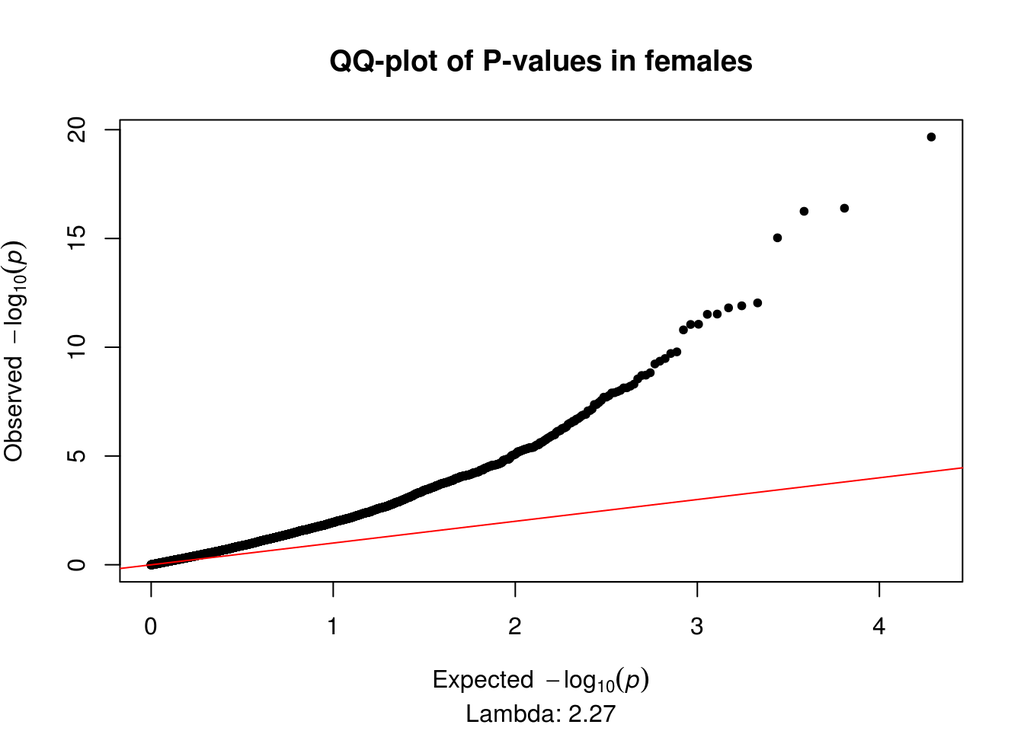

### Model 10 (10 SV)

The ANOVA of diagnosis has been run with 10 SVs. Tables of the top 1000 DMPs have been produced for each variable of interest.

#### Top DMPs

**ANOVA:**  
50 probes pass the epigenome-wide significance threshold of 2.4x10-7  
*The top 50 diagnosis associated DMPs:*

| ProbeID | Position | F | p (F) | FDR.Anova | Difference | CI lower | CI upper | pCvM | FDR | Difference | CI lower | CI upper | pCvA | FDR | Difference | CI lower | CI upper | pMvA | FDR | UCSC Gene | UCSC Gene Group | UCSC Relation to CpG Island | Gene Closest TSS | Distance Closest TSS | GREAT Annotation 1 | GREAT Annotation 2 |
| --- | --- | --- | --- | --- | --- | --- | --- | --- | --- | --- | --- | --- | --- | --- | --- | --- | --- | --- | --- | --- | --- | --- | --- | --- | --- | --- |
| cg22822140 | chr X: 153046577 | 56.698 | 1.61e-19 | 1.56e-15 | -0.001 | -0.022 | 0.020 | 0.992 | 1 | -0.084 | -0.105 | -0.062 | 4.91e-14 | 4.73e-10 | -0.083 | -0.104 | -0.062 | 4.96e-14 | 1.29e-10 | SRPK3;SRPK3;SRPK3 | 1stExon;1stExon;1stExon | Island | SRPK3 | 122 | SRPK3 (122) | (NA) |
| cg24496423 | chr X: 153046480 | 48.770 | 2.08e-17 | 1.01e-13 | 0.003 | -0.015 | 0.021 | 0.919 | 1 | -0.065 | -0.083 | -0.046 | 1.62e-13 | 5.22e-10 | -0.068 | -0.086 | -0.05 | 5.33e-14 | 1.29e-10 | SRPK3;SRPK3;SRPK3;SRPK3;SRPK3;SRPK3 | 5'UTR;1stExon;1stExon;5'UTR;5'UTR;1stExon | Island | SRPK3 | 25 | SRPK3 (25) | (NA) |
| cg12230162 | chr X: 153046482 | 47.570 | 4.46e-17 | 1.43e-13 | 0.007 | -0.017 | 0.031 | 0.765 | 1 | -0.081 | -0.105 | -0.057 | 6.22e-13 | 1.50e-09 | -0.088 | -0.111 | -0.064 | 5.21e-14 | 1.29e-10 | SRPK3;SRPK3;SRPK3;SRPK3;SRPK3;SRPK3 | 5'UTR;1stExon;1stExon;5'UTR;5'UTR;1stExon | Island | SRPK3 | 27 | SRPK3 (27) | (NA) |
| cg13009143 | chr X: 100548223 | 39.963 | 6.57e-15 | 1.58e-11 | -0.014 | -0.02 | -0.007 | 5.14e-06 | 0.001 | 0.011 | 0.004 | 0.018 | 4.74e-04 | 0.029 | 0.025 | 0.018 | 0.031 | 5.23e-14 | 1.29e-10 | TAF7L | TSS200 | S_Shore | TAF7L | -164 | TAF7L (-165) | (NA) |
| cg03360001 | chr X: 53453272 | 34.874 | 2.21e-13 | 4.26e-10 | -0.008 | -0.013 | -0.003 | 9.87e-04 | 0.048 | 0.01 | 0.005 | 0.015 | 2.64e-05 | 0.004 | 0.018 | 0.013 | 0.023 | 1.30e-13 | 2.50e-10 | RIBC1;RIBC1 | Body;Body | S_Shelf | RIBC1 | 3434 | SMC1A (-3655) | (NA) |
| cg12468189 | chr X: 153046767 | 34.391 | 3.11e-13 | 4.99e-10 | -0.024 | -0.038 | -0.009 | 3.67e-04 | 0.024 | -0.051 | -0.065 | -0.036 | 1.60e-13 | 5.22e-10 | -0.027 | -0.041 | -0.013 | 4.00e-05 | 0.007 | SRPK3;SRPK3;SRPK3 | Body;Body;Body | Island | SRPK3 | 312 | SRPK3 (312) | (NA) |
| cg24605338 | chr X: 17395856 | 33.719 | 5.01e-13 | 6.90e-10 | -0.037 | -0.048 | -0.027 | 2.20e-13 | 2.12e-09 | -0.019 | -0.030 | -0.008 | 1.75e-04 | 0.015 | 0.018 | 0.008 | 0.029 | 2.24e-04 | 0.026 | NHS | Body | S_Shore | NHS | 2314 | SCML1 (-359735) | NHS (2314) |
| cg16152676 | chr X: 10126878 | 32.541 | 1.16e-12 | 1.40e-09 | 0.038 | 0.024 | 0.052 | 3.45e-09 | 5.19e-06 | -0.005 | -0.019 | 0.009 | 0.661 | 1 | -0.043 | -0.057 | -0.03 | 2.33e-11 | 3.22e-08 | CLCN4 | 5'UTR | Island | CLCN4 | 550 | CLCN4 (1894) | MID1 (724930) |
| cg19938385 | chr X: 107020894 | 31.283 | 2.89e-12 | 3.10e-09 | -0.046 | -0.063 | -0.028 | 2.12e-08 | 1.57e-05 | -0.056 | -0.074 | -0.039 | 1.48e-11 | 2.86e-08 | -0.011 | -0.028 | 0.007 | 0.321 | 1 |  |  | S_Shore | TSC22D3 | -1692 | TSC22D3 (-1878) | (NA) |
| cg16529483 | chr X: 153046451 | 31.037 | 3.46e-12 | 3.34e-09 | -0.005 | -0.029 | 0.018 | 0.866 | 1 | -0.071 | -0.095 | -0.047 | 1.60e-10 | 2.57e-07 | -0.066 | -0.089 | -0.042 | 1.34e-09 | 1.30e-06 | SRPK3;SRPK3;SRPK3 | TSS200;TSS200;TSS200 | Island | SRPK3 | -4 | SRPK3 (-4) | (NA) |
| cg07069575 | chr X: 49688313 | 29.174 | 1.36e-11 | 1.19e-08 | 0.007 | -0.004 | 0.018 | 0.265 | 0.964 | -0.026 | -0.037 | -0.015 | 2.24e-07 | 1.20e-04 | -0.033 | -0.044 | -0.022 | 3.40e-11 | 4.11e-08 | CLCN5;CLCN5 | 5'UTR;5'UTR | S_Shore | CLCN5 | 1089 | CLCN5 (1089) | AKAP4 (277350) |
| cg09768654 | chr X: 153046386 | 28.734 | 1.88e-11 | 1.51e-08 | 0.011 | -0.011 | 0.033 | 0.469 | 1 | -0.056 | -0.079 | -0.033 | 8.09e-08 | 5.20e-05 | -0.067 | -0.089 | -0.045 | 9.14e-11 | 9.79e-08 | SRPK3;SRPK3;SRPK3 | TSS200;TSS200;TSS200 | Island | SRPK3 | -69 | SRPK3 (-69) | (NA) |
| cg21252909 | chr X: 30326328 | 28.636 | 2.03e-11 | 1.51e-08 | 0.038 | 0.016 | 0.060 | 2.23e-04 | 0.018 | -0.032 | -0.054 | -0.01 | 0.002 | 0.084 | -0.070 | -0.092 | -0.048 | 7.94e-12 | 1.28e-08 | NR0B1 | 1stExon | N_Shore | NR0B1 | 1167 | NR0B1 (1166) | (NA) |
| cg19280671 | chr X: 149013642 | 27.066 | 6.58e-11 | 4.54e-08 | 0.016 | 0.01 | 0.022 | 4.84e-09 | 5.19e-06 | 3.11e-04 | -0.006 | 0.006 | 0.992 | 1 | -0.015 | -0.021 | -0.01 | 8.03e-09 | 6.45e-06 | MAGEA8;MAGEA8;MAGEA8 | Body;Body;Body |  | MAGEA8 | 596 | MAMLD1 (-517908) | MAGEA8 (3702) |
| cg11179997 | chr X: 119125670 | 25.876 | 1.63e-10 | 1.05e-07 | 0.028 | 0.018 | 0.039 | 4.33e-09 | 5.19e-06 | 0.002 | -0.008 | 0.013 | 0.888 | 1 | -0.026 | -0.036 | -0.016 | 4.24e-08 | 2.72e-05 |  |  | Island | AK123976 | -44530 | NKAP (-47936) | RHOXF2 (86036) |
| cg17003204 | chr X: 102861456 | 25.387 | 2.36e-10 | 1.42e-07 | -0.030 | -0.04 | -0.019 | 1.31e-09 | 4.62e-06 | -0.005 | -0.016 | 0.006 | 0.484 | 1 | 0.025 | 0.014 | 0.035 | 4.34e-07 | 2.00e-04 | TCEAL3;TCEAL3 | TSS1500;TSS1500 | N_Shore | TCEAL3 | -1377 | TCEAL3 (-1377) | (NA) |
| cg17405188 | chr X: 73164102 | 24.195 | 5.92e-10 | 3.36e-07 | 0.006 | 0.001 | 0.011 | 0.008 | 0.17 | 0.014 | 0.009 | 0.019 | 2.59e-10 | 3.56e-07 | 0.008 | 0.003 | 0.013 | 2.84e-04 | 0.03 | LOC554203 | TSS200 | Island | JPX | -56 | ZCCHC13 (-359922) | CHIC1 (381119) |
| cg09661041 | chr X: 153141905 | 23.030 | 1.47e-09 | 7.87e-07 | -0.006 | -0.028 | 0.016 | 0.82 | 1 | -0.058 | -0.080 | -0.035 | 1.95e-08 | 1.71e-05 | -0.052 | -0.074 | -0.03 | 2.33e-07 | 1.18e-04 | L1CAM;L1CAM;L1CAM | TSS1500;TSS1500;TSS1500 |  | L1CAM | -506 | L1CAM (-507) | (NA) |
| cg06452970 | chr X: 13835264 | 22.810 | 1.74e-09 | 8.86e-07 | 0.046 | 0.028 | 0.063 | 9.72e-09 | 8.53e-06 | 0.007 | -0.010 | 0.025 | 0.577 | 1 | -0.038 | -0.055 | -0.021 | 1.28e-06 | 5.16e-04 | GPM6B;GPM6B;GPM6B;GPM6B;GPM6B;GPM6B;GPM6B | 1stExon;5'UTR;5'UTR;Body;5'UTR;1stExon;1stExon |  | GPM6B | 50 | GPM6B (49) | (NA) |
| cg17219209 | chr X: 149009840 | 22.616 | 2.03e-09 | 9.81e-07 | 0.021 | 0.014 | 0.029 | 4.48e-09 | 5.19e-06 | 0.005 | -0.003 | 0.013 | 0.294 | 1 | -0.016 | -0.024 | -0.008 | 6.54e-06 | 0.002 | MAGEA8;MAGEA8;MAGEA8 | TSS200;TSS200;TSS200 |  | MAGEA8 | -100 | MAGEA8 (-100) | (NA) |
| cg15907464 | chr X: 70712790 | 22.005 | 3.29e-09 | 1.51e-06 | -0.034 | -0.047 | -0.022 | 1.44e-09 | 4.62e-06 | -0.02 | -0.032 | -0.008 | 5.85e-04 | 0.034 | 0.014 | 0.002 | 0.027 | 0.017 | 0.382 | BCYRN1;INGX | Body;TSS200 | Island | INGX | -186 | OGT (-40121) | TAF1 (126677) |
| cg17513789 | chr X: 73073251 | 21.509 | 4.88e-09 | 2.14e-06 | -0.039 | -0.053 | -0.025 | 2.13e-09 | 4.69e-06 | -0.018 | -0.032 | -0.003 | 0.01 | 0.21 | 0.021 | 0.007 | 0.035 | 0.001 | 0.085 | XIST | TSS1500 |  | XIST | -663 | ZCCHC13 (-450773) | CHIC1 (290268) |
| cg14917571 | chr X: 79269151 | 21.426 | 5.21e-09 | 2.19e-06 | -0.049 | -0.066 | -0.031 | 2.43e-09 | 4.69e-06 | -0.029 | -0.047 | -0.011 | 4.78e-04 | 0.029 | 0.019 | 0.002 | 0.037 | 0.026 | 0.493 | TBX22;TBX22 | TSS1500;TSS1500 |  | TBX22 | -1103 | ITM2A (-646103) | TBX22 (-8590) |
| cg25896901 | chr X: 125300481 | 21.203 | 6.23e-09 | 2.50e-06 | 0.009 | -0.016 | 0.035 | 0.658 | 1 | -0.055 | -0.081 | -0.03 | 2.72e-06 | 9.05e-04 | -0.065 | -0.09 | -0.039 | 2.52e-08 | 1.74e-05 | DCAF12L2 | TSS1500 | S_Shore | DCAF12L2 | -401 | DCAF12L1 (386360) | (NA) |
| cg09513996 | chr X: 48685182 | 21.017 | 7.23e-09 | 2.79e-06 | 0.005 | -0.008 | 0.018 | 0.605 | 1 | -0.028 | -0.041 | -0.015 | 3.87e-06 | 0.001 | -0.033 | -0.046 | -0.02 | 2.46e-08 | 1.74e-05 |  |  | Island | ERAS | -2100 | ERAS (-2100) | (NA) |
| cg01737010 | chr X: 101772014 | 20.782 | 8.71e-09 | 3.23e-06 | 0.008 | -0.001 | 0.017 | 0.111 | 0.672 | -0.017 | -0.026 | -0.007 | 1.13e-04 | 0.011 | -0.025 | -0.034 | -0.016 | 6.39e-09 | 5.60e-06 | TMSB15A | TSS1500 | S_Shore | TMSB15A | -315 | TMSB15A (-316) | (NA) |
| cg16122592 | chr X: 26210712 | 20.720 | 9.16e-09 | 3.27e-06 | -0.029 | -0.04 | -0.017 | 3.39e-08 | 2.04e-05 | -0.024 | -0.036 | -0.013 | 3.36e-06 | 0.001 | 0.004 | -0.007 | 0.016 | 0.644 | 1 | MAGEB6 | 5'UTR |  | MAGEB6 | 156 | MAGEB6 (156) | (NA) |
| cg08630881 | chr X: 70713213 | 20.425 | 1.16e-08 | 4.00e-06 | -0.028 | -0.039 | -0.018 | 7.52e-09 | 7.26e-06 | -0.019 | -0.029 | -0.008 | 1.66e-04 | 0.014 | 0.009 | -0.001 | 0.02 | 0.088 | 0.852 | BCYRN1;INGX | Body;TSS1500 | S_Shore | INGX | -609 | OGT (-39698) | TAF1 (127100) |
| cg12039689 | chr X: 153141750 | 20.061 | 1.56e-08 | 5.18e-06 | -0.018 | -0.038 | 0.002 | 0.09 | 0.618 | -0.054 | -0.074 | -0.033 | 1.20e-08 | 1.25e-05 | -0.036 | -0.056 | -0.016 | 1.29e-04 | 0.018 | L1CAM;L1CAM;L1CAM | TSS1500;TSS1500;TSS1500 |  | L1CAM | -351 | L1CAM (-352) | (NA) |
| ch.X.153018199F | chr X: 153365005 | 19.915 | 1.75e-08 | 5.63e-06 | -0.011 | -0.015 | -0.007 | 1.83e-08 | 1.47e-05 | -0.003 | -0.008 | 9.55e-04 | 0.158 | 0.825 | 0.008 | 0.003 | 0.012 | 9.23e-05 | 0.013 |  |  | S_Shore | MECP2 | -1817 | MECP2 (-1818) | (NA) |
| cg04710661 | chr X: 2848381 | 19.681 | 2.12e-08 | 6.58e-06 | 0.007 | -9.27e-05 | 0.013 | 0.054 | 0.49 | 0.018 | 0.011 | 0.025 | 1.29e-08 | 1.25e-05 | 0.011 | 0.005 | 0.018 | 3.20e-04 | 0.033 | ARSD;ARSD | TSS1500;TSS1500 | S_Shore | ARSD | -965 | ARSD (-966) | (NA) |
| cg07344627 | chr X: 125687011 | 19.603 | 2.25e-08 | 6.79e-06 | -0.033 | -0.056 | -0.010 | 0.003 | 0.087 | -0.061 | -0.084 | -0.038 | 9.51e-09 | 1.15e-05 | -0.028 | -0.051 | -0.006 | 0.01 | 0.275 | DCAF12L1 | TSS200 | S_Shore | DCAF12L1 | -169 | DCAF12L1 (-170) | (NA) |
| cg22926378 | chr X: 6144633 | 19.412 | 2.63e-08 | 7.69e-06 | 0.014 | 0.007 | 0.020 | 6.73e-06 | 0.002 | -0.002 | -0.009 | 0.004 | 0.7 | 1 | -0.016 | -0.023 | -0.009 | 1.29e-07 | 6.92e-05 | NLGN4X;NLGN4X | 5'UTR;5'UTR | Island | NLGN4X | 483 | NLGN4X (2072) | (NA) |
| cg04768884 | chr X: 19443172 | 19.122 | 3.33e-08 | 9.44e-06 | 0.005 | -0.009 | 0.018 | 0.659 | 1 | 0.033 | 0.019 | 0.047 | 1.53e-07 | 9.21e-05 | 0.028 | 0.015 | 0.041 | 5.80e-06 | 0.002 | MAP3K15 | Body |  | MAP3K15 | 35099 | PDHA1 (81162) | MAP3K15 (90206) |
| cg24834461 | chr X: 153637645 | 18.602 | 5.09e-08 | 1.40e-05 | 0.017 | 0.01 | 0.023 | 3.16e-08 | 2.04e-05 | 0.011 | 0.004 | 0.018 | 4.05e-04 | 0.027 | -0.006 | -0.012 | 7.90e-04 | 0.097 | 0.874 | DNASE1L1;DNASE1L1;DNASE1L1;DNASE1L1 | TSS200;5'UTR;5'UTR;5'UTR | N_Shelf | DNASE1L1 | -70 | TAZ (-2231) | (NA) |
| cg26484667 | chr X: 2733164 | 18.471 | 5.66e-08 | 1.52e-05 | -0.026 | -0.037 | -0.015 | 2.79e-07 | 1.34e-04 | -0.004 | -0.015 | 0.008 | 0.709 | 1 | 0.023 | 0.011 | 0.034 | 1.02e-05 | 0.002 | XG;XG;XG | 3'UTR;3'UTR;3'UTR |  | GYG2 | -13698 | GYG2 (-13698) | XG (63072) |
| cg23914849 | chr X: 52950051 | 18.390 | 6.05e-08 | 1.56e-05 | 0.003 | 6.38e-04 | 0.005 | 0.007 | 0.167 | 0.006 | 0.003 | 0.008 | 2.57e-08 | 2.06e-05 | 0.003 | 6.64e-04 | 0.005 | 0.007 | 0.23 |  |  | Island | FAM156A | 13799 | FAM156B (21967) | FAM156A (74599) |
| cg21364342 | chr X: 107226611 | 18.374 | 6.13e-08 | 1.56e-05 | -0.018 | -0.027 | -0.009 | 8.45e-06 | 0.002 | -0.021 | -0.030 | -0.012 | 2.52e-07 | 1.28e-04 | -0.003 | -0.012 | 0.006 | 0.683 | 1 | TEX13B | TSS1500 |  | TEX13B | -1011 | VSIG1 (-61588) | MID2 (157528) |
| cg00072799 | chr X: 78427682 | 18.146 | 7.39e-08 | 1.81e-05 | -0.006 | -0.02 | 0.007 | 0.491 | 1 | -0.032 | -0.046 | -0.019 | 1.87e-07 | 1.06e-04 | -0.026 | -0.039 | -0.013 | 2.25e-05 | 0.005 | GPR174;GPR174 | 1stExon;3'UTR |  | GPR174 | 1214 | GPR174 (1214) | ITM2A (195366) |
| cg24352688 | chr X: 13751727 | 18.129 | 7.49e-08 | 1.81e-05 | 0.002 | -0.005 | 0.009 | 0.781 | 1 | 0.016 | 0.009 | 0.023 | 4.48e-07 | 2.16e-04 | 0.014 | 0.007 | 0.021 | 6.44e-06 | 0.002 | TRAPPC2;OFD1;TRAPPC2;TRAPPC2 | 5'UTR;TSS1500;5'UTR;5'UTR | N_Shore | TRAPPC2 | 1027 | OFD1 (-1104) | TRAPPC2 (1026) |
| cg04817724 | chr X: 103809991 | 18.082 | 7.79e-08 | 1.83e-05 | 0.050 | 0.03 | 0.069 | 3.33e-08 | 2.04e-05 | 0.025 | 0.006 | 0.045 | 0.008 | 0.177 | -0.024 | -0.044 | -0.005 | 0.01 | 0.28 | IL1RAPL2 | TSS1500 | Island | IL1RAPL2 | -1004 | IL1RAPL2 (-1004) | (NA) |
| cg00190642 | chr X: 103268431 | 18.023 | 8.18e-08 | 1.88e-05 | -0.012 | -0.026 | 0.003 | 0.149 | 0.76 | 0.025 | 0.010 | 0.04 | 3.45e-04 | 0.024 | 0.036 | 0.022 | 0.051 | 5.96e-08 | 3.59e-05 | H2BFWT;MIR1256 | TSS200;Body | Island | H2BFWT | -175 | H2BFWT (-176) | (NA) |
| cg00632130 | chr X: 47931806 | 17.921 | 8.89e-08 | 2.00e-05 | -0.010 | -0.023 | 0.003 | 0.171 | 0.805 | 0.022 | 0.009 | 0.035 | 2.97e-04 | 0.021 | 0.032 | 0.019 | 0.044 | 6.92e-08 | 3.92e-05 | ZNF630 | TSS1500 | S_Shore | ZNF630 | -781 | ZNF630 (-1299) | (NA) |
| cg22574818 | chr X: 55479616 | 17.790 | 9.91e-08 | 2.17e-05 | -0.030 | -0.053 | -0.008 | 0.005 | 0.138 | -0.058 | -0.081 | -0.035 | 4.29e-08 | 3.18e-05 | -0.028 | -0.05 | -0.005 | 0.012 | 0.321 | MAGEH1;MAGEH1 | 1stExon;3'UTR |  | MAGEH1 | 1079 | MAGEH1 (1079) | USP51 (36014) |
| cg11315455 | chr X: 122997585 | 17.686 | 1.08e-07 | 2.31e-05 | -0.026 | -0.037 | -0.015 | 9.41e-08 | 5.34e-05 | -0.008 | -0.019 | 0.002 | 0.154 | 0.816 | 0.018 | 0.007 | 0.028 | 3.49e-04 | 0.034 | XIAP | 5'UTR | S_Shelf | XIAP | 3569 | STAG2 (-96889) | XIAP (3569) |
| cg08464958 | chr X: 2852845 | 17.663 | 1.10e-07 | 2.31e-05 | -0.022 | -0.031 | -0.013 | 2.35e-07 | 1.19e-04 | -0.005 | -0.014 | 0.005 | 0.449 | 1 | 0.017 | 0.008 | 0.026 | 5.34e-05 | 0.009 | ARSE | 3'UTR |  | ARSD | -5429 | ARSD (-5430) | ARSE (29648) |
| cg00779763 | chr X: 47479114 | 17.494 | 1.26e-07 | 2.60e-05 | 0.009 | -3.49e-04 | 0.019 | 0.062 | 0.522 | 0.024 | 0.014 | 0.034 | 7.33e-08 | 5.05e-05 | 0.015 | 0.005 | 0.024 | 9.47e-04 | 0.07 | SYN1;SYN1 | 1stExon;1stExon | Island | SYN1 | 142 | SYN1 (141) | (NA) |
| cg25433595 | chr X: 100183764 | 17.463 | 1.30e-07 | 2.61e-05 | 0.042 | 0.024 | 0.060 | 2.91e-07 | 1.34e-04 | 0.035 | 0.017 | 0.053 | 3.27e-05 | 0.005 | -0.007 | -0.025 | 0.01 | 0.585 | 1 | XKRX;XKRX | 5'UTR;1stExon | N_Shore | XKRX | 134 | XKRX (133) | (NA) |
| cg00805156 | chr X: 3264341 | 17.290 | 1.50e-07 | 2.95e-05 | 0.034 | 0.018 | 0.051 | 7.92e-06 | 0.002 | 0.038 | 0.021 | 0.055 | 9.52e-07 | 4.17e-04 | 0.004 | -0.013 | 0.02 | 0.854 | 1 | MXRA5 | 5'UTR | Island | MXRA5 | 343 | MXRA5 (342) | (NA) |
| cg00123001 | chr X: 13395880 | 16.910 | 2.05e-07 | 3.96e-05 | -0.015 | -0.022 | -0.008 | 7.08e-06 | 0.002 | -0.016 | -0.023 | -0.009 | 1.68e-06 | 6.46e-04 | -0.001 | -0.008 | 0.006 | 0.921 | 1 |  |  | N_Shore | LOC100133123 | 42521 | EGFL6 (-191813) | ATXN3L (-57363) |

**CTL vs MCI:**  
19 probes pass the epigenome-wide significance threshold of 2.4x10-7

*The top 50 CTL vs MCI associated DMPs:*

| ProbeID | Position | F | p (F) | FDR.Anova | Difference | CI lower | CI upper | pCvM | FDR | Difference | CI lower | CI upper | pCvA | FDR | Difference | CI lower | CI upper | pMvA | FDR | UCSC Gene | UCSC Gene Group | UCSC Relation to CpG Island | Gene Closest TSS | Distance Closest TSS | GREAT Annotation 1 | GREAT Annotation 2 |
| --- | --- | --- | --- | --- | --- | --- | --- | --- | --- | --- | --- | --- | --- | --- | --- | --- | --- | --- | --- | --- | --- | --- | --- | --- | --- | --- |
| cg24605338 | chr X: 17395856 | 33.719 | 5.01e-13 | 6.90e-10 | -0.037 | -0.048 | -0.027 | 2.20e-13 | 2.12e-09 | -0.019 | -0.030 | -0.008 | 1.75e-04 | 0.015 | 0.018 | 0.008 | 0.029 | 2.24e-04 | 0.026 | NHS | Body | S_Shore | NHS | 2314 | SCML1 (-359735) | NHS (2314) |
| cg17003204 | chr X: 102861456 | 25.387 | 2.36e-10 | 1.42e-07 | -0.030 | -0.040 | -0.019 | 1.31e-09 | 4.62e-06 | -0.005 | -0.016 | 0.006 | 0.484 | 1 | 0.025 | 0.014 | 0.035 | 4.34e-07 | 2.00e-04 | TCEAL3;TCEAL3 | TSS1500;TSS1500 | N_Shore | TCEAL3 | -1377 | TCEAL3 (-1377) | (NA) |
| cg15907464 | chr X: 70712790 | 22.005 | 3.29e-09 | 1.51e-06 | -0.034 | -0.047 | -0.022 | 1.44e-09 | 4.62e-06 | -0.02 | -0.032 | -0.008 | 5.85e-04 | 0.034 | 0.014 | 0.002 | 0.027 | 0.017 | 0.382 | BCYRN1;INGX | Body;TSS200 | Island | INGX | -186 | OGT (-40121) | TAF1 (126677) |
| cg17513789 | chr X: 73073251 | 21.509 | 4.88e-09 | 2.14e-06 | -0.039 | -0.053 | -0.025 | 2.13e-09 | 4.69e-06 | -0.018 | -0.032 | -0.003 | 0.01 | 0.21 | 0.021 | 0.007 | 0.035 | 0.001 | 0.085 | XIST | TSS1500 |  | XIST | -663 | ZCCHC13 (-450773) | CHIC1 (290268) |
| cg14917571 | chr X: 79269151 | 21.426 | 5.21e-09 | 2.19e-06 | -0.049 | -0.066 | -0.031 | 2.43e-09 | 4.69e-06 | -0.029 | -0.047 | -0.011 | 4.78e-04 | 0.029 | 0.019 | 0.002 | 0.037 | 0.026 | 0.493 | TBX22;TBX22 | TSS1500;TSS1500 |  | TBX22 | -1103 | ITM2A (-646103) | TBX22 (-8590) |
| cg16152676 | chr X: 10126878 | 32.541 | 1.16e-12 | 1.40e-09 | 0.038 | 0.024 | 0.052 | 3.45e-09 | 5.19e-06 | -0.005 | -0.019 | 0.009 | 0.661 | 1 | -0.043 | -0.057 | -0.03 | 2.33e-11 | 3.22e-08 | CLCN4 | 5'UTR | Island | CLCN4 | 550 | CLCN4 (1894) | MID1 (724930) |
| cg11179997 | chr X: 119125670 | 25.876 | 1.63e-10 | 1.05e-07 | 0.028 | 0.018 | 0.039 | 4.33e-09 | 5.19e-06 | 0.002 | -0.008 | 0.013 | 0.888 | 1 | -0.026 | -0.036 | -0.016 | 4.24e-08 | 2.72e-05 |  |  | Island | AK123976 | -44530 | NKAP (-47936) | RHOXF2 (86036) |
| cg17219209 | chr X: 149009840 | 22.616 | 2.03e-09 | 9.81e-07 | 0.021 | 0.014 | 0.029 | 4.48e-09 | 5.19e-06 | 0.005 | -0.003 | 0.013 | 0.294 | 1 | -0.016 | -0.024 | -0.008 | 6.54e-06 | 0.002 | MAGEA8;MAGEA8;MAGEA8 | TSS200;TSS200;TSS200 |  | MAGEA8 | -100 | MAGEA8 (-100) | (NA) |
| cg19280671 | chr X: 149013642 | 27.066 | 6.58e-11 | 4.54e-08 | 0.016 | 0.010 | 0.022 | 4.84e-09 | 5.19e-06 | 3.11e-04 | -0.006 | 0.006 | 0.992 | 1 | -0.015 | -0.021 | -0.01 | 8.03e-09 | 6.45e-06 | MAGEA8;MAGEA8;MAGEA8 | Body;Body;Body |  | MAGEA8 | 596 | MAMLD1 (-517908) | MAGEA8 (3702) |
| cg08630881 | chr X: 70713213 | 20.425 | 1.16e-08 | 4.00e-06 | -0.028 | -0.039 | -0.018 | 7.52e-09 | 7.26e-06 | -0.019 | -0.029 | -0.008 | 1.66e-04 | 0.014 | 0.009 | -0.001 | 0.02 | 0.088 | 0.852 | BCYRN1;INGX | Body;TSS1500 | S_Shore | INGX | -609 | OGT (-39698) | TAF1 (127100) |
| cg06452970 | chr X: 13835264 | 22.810 | 1.74e-09 | 8.86e-07 | 0.046 | 0.028 | 0.063 | 9.72e-09 | 8.53e-06 | 0.007 | -0.010 | 0.025 | 0.577 | 1 | -0.038 | -0.055 | -0.021 | 1.28e-06 | 5.16e-04 | GPM6B;GPM6B;GPM6B;GPM6B;GPM6B;GPM6B;GPM6B | 1stExon;5'UTR;5'UTR;Body;5'UTR;1stExon;1stExon |  | GPM6B | 50 | GPM6B (49) | (NA) |
| ch.X.153018199F | chr X: 153365005 | 19.915 | 1.75e-08 | 5.63e-06 | -0.011 | -0.015 | -0.007 | 1.83e-08 | 1.47e-05 | -0.003 | -0.008 | 9.55e-04 | 0.158 | 0.825 | 0.008 | 0.003 | 0.012 | 9.23e-05 | 0.013 |  |  | S_Shore | MECP2 | -1817 | MECP2 (-1818) | (NA) |
| cg19938385 | chr X: 107020894 | 31.283 | 2.89e-12 | 3.10e-09 | -0.046 | -0.063 | -0.028 | 2.12e-08 | 1.57e-05 | -0.056 | -0.074 | -0.039 | 1.48e-11 | 2.86e-08 | -0.011 | -0.028 | 0.007 | 0.321 | 1 |  |  | S_Shore | TSC22D3 | -1692 | TSC22D3 (-1878) | (NA) |
| cg24834461 | chr X: 153637645 | 18.602 | 5.09e-08 | 1.40e-05 | 0.017 | 0.010 | 0.023 | 3.16e-08 | 2.04e-05 | 0.011 | 0.004 | 0.018 | 4.05e-04 | 0.027 | -0.006 | -0.012 | 7.90e-04 | 0.097 | 0.874 | DNASE1L1;DNASE1L1;DNASE1L1;DNASE1L1 | TSS200;5'UTR;5'UTR;5'UTR | N_Shelf | DNASE1L1 | -70 | TAZ (-2231) | (NA) |
| cg04817724 | chr X: 103809991 | 18.082 | 7.79e-08 | 1.83e-05 | 0.050 | 0.030 | 0.069 | 3.33e-08 | 2.04e-05 | 0.025 | 0.006 | 0.045 | 0.008 | 0.177 | -0.024 | -0.044 | -0.005 | 0.01 | 0.28 | IL1RAPL2 | TSS1500 | Island | IL1RAPL2 | -1004 | IL1RAPL2 (-1004) | (NA) |
| cg16122592 | chr X: 26210712 | 20.720 | 9.16e-09 | 3.27e-06 | -0.029 | -0.040 | -0.017 | 3.39e-08 | 2.04e-05 | -0.024 | -0.036 | -0.013 | 3.36e-06 | 0.001 | 0.004 | -0.007 | 0.016 | 0.644 | 1 | MAGEB6 | 5'UTR |  | MAGEB6 | 156 | MAGEB6 (156) | (NA) |
| cg11315455 | chr X: 122997585 | 17.686 | 1.08e-07 | 2.31e-05 | -0.026 | -0.037 | -0.015 | 9.41e-08 | 5.34e-05 | -0.008 | -0.019 | 0.002 | 0.154 | 0.816 | 0.018 | 0.007 | 0.028 | 3.49e-04 | 0.034 | XIAP | 5'UTR | S_Shelf | XIAP | 3569 | STAG2 (-96889) | XIAP (3569) |
| cg09953945 | chr X: 150345040 | 16.469 | 2.96e-07 | 5.30e-05 | -0.024 | -0.034 | -0.014 | 1.52e-07 | 8.14e-05 | -0.015 | -0.025 | -0.005 | 0.002 | 0.084 | 0.009 | -4.58e-04 | 0.019 | 0.065 | 0.756 | GPR50 | TSS200 | N_Shore | GPR50 | -15 | GPR50 (-15) | (NA) |
| cg08464958 | chr X: 2852845 | 17.663 | 1.10e-07 | 2.31e-05 | -0.022 | -0.031 | -0.013 | 2.35e-07 | 1.19e-04 | -0.005 | -0.014 | 0.005 | 0.449 | 1 | 0.017 | 0.008 | 0.026 | 5.34e-05 | 0.009 | ARSE | 3'UTR |  | ARSD | -5429 | ARSD (-5430) | ARSE (29648) |
| cg26484667 | chr X: 2733164 | 18.471 | 5.66e-08 | 1.52e-05 | -0.026 | -0.037 | -0.015 | 2.79e-07 | 1.34e-04 | -0.004 | -0.015 | 0.008 | 0.709 | 1 | 0.023 | 0.011 | 0.034 | 1.02e-05 | 0.002 | XG;XG;XG | 3'UTR;3'UTR;3'UTR |  | GYG2 | -13698 | GYG2 (-13698) | XG (63072) |
| cg25433595 | chr X: 100183764 | 17.463 | 1.30e-07 | 2.61e-05 | 0.042 | 0.024 | 0.060 | 2.91e-07 | 1.34e-04 | 0.035 | 0.017 | 0.053 | 3.27e-05 | 0.005 | -0.007 | -0.025 | 0.01 | 0.585 | 1 | XKRX;XKRX | 5'UTR;1stExon | N_Shore | XKRX | 134 | XKRX (133) | (NA) |
| cg25177692 | chr X: 129193893 | 16.584 | 2.69e-07 | 4.93e-05 | -0.025 | -0.036 | -0.014 | 4.49e-07 | 1.97e-04 | -0.02 | -0.031 | -0.009 | 8.22e-05 | 0.009 | 0.005 | -0.006 | 0.016 | 0.5 | 1 |  |  | N_Shore | BCORL1 | 34929 | ELF4 (50794) | BCORL1 (54730) |
| cg12461113 | chr X: 13587550 | 14.905 | 1.11e-06 | 1.75e-04 | -0.074 | -0.106 | -0.042 | 5.48e-07 | 2.30e-04 | -0.033 | -0.066 | -8.17e-04 | 0.043 | 0.448 | 0.041 | 0.009 | 0.073 | 0.009 | 0.257 | EGFL6;EGFL6 | TSS200;TSS200 | N_Shore | EGFL6 | -143 | EGFL6 (-143) | (NA) |
| cg25549901 | chr X: 137951118 | 16.681 | 2.48e-07 | 4.70e-05 | -0.022 | -0.031 | -0.012 | 5.78e-07 | 2.32e-04 | -0.018 | -0.028 | -0.008 | 4.40e-05 | 0.006 | 0.004 | -0.006 | 0.013 | 0.63 | 1 | FGF13;FGF13;FGF13;FGF13 | 5'UTR;Body;TSS1500;Body |  | FGF13 | -1401 | FGF13 (336066) | (NA) |
| cg05547600 | chr X: 134847106 | 14.579 | 1.46e-06 | 2.23e-04 | -0.032 | -0.046 | -0.018 | 8.32e-07 | 3.21e-04 | -0.013 | -0.027 | 0.001 | 0.084 | 0.619 | 0.019 | 0.005 | 0.033 | 0.005 | 0.188 | CT45A1 | TSS200 |  | CT45A1 | -78 | MMGT1 (209027) | ZNF449 (368411) |
| cg14306994 | chr X: 49019804 | 14.536 | 1.51e-06 | 2.25e-04 | 0.030 | 0.017 | 0.043 | 8.88e-07 | 3.30e-04 | 0.012 | -0.001 | 0.025 | 0.093 | 0.642 | -0.018 | -0.031 | -0.005 | 0.004 | 0.179 | MAGIX;MAGIX;MAGIX;MAGIX | Body;Body;Body;TSS1500 | Island | MAGIX | -316 | GPKOW (-39726) | PLP2 (-8379) |
| cg17970282 | chr X: 70712810 | 14.151 | 2.10e-06 | 2.95e-04 | -0.033 | -0.047 | -0.018 | 1.03e-06 | 3.67e-04 | -0.015 | -0.030 | -5.55e-04 | 0.04 | 0.433 | 0.017 | 0.003 | 0.032 | 0.014 | 0.343 | BCYRN1;INGX | Body;TSS1500 | Island | INGX | -206 | OGT (-40101) | TAF1 (126697) |
| cg05860920 | chr X: 11679501 | 14.040 | 2.31e-06 | 3.06e-04 | 0.053 | 0.029 | 0.077 | 1.25e-06 | 4.31e-04 | 0.033 | 0.008 | 0.057 | 0.005 | 0.14 | -0.021 | -0.045 | 0.003 | 0.101 | 0.892 | ARHGAP6;ARHGAP6 | Body;Body | N_Shelf | ARHGAP6 | 4320 | ARHGAP6 (4319) | AMELX (367969) |
| cg08867267 | chr X: 130033963 | 13.825 | 2.78e-06 | 3.48e-04 | -0.021 | -0.031 | -0.012 | 1.50e-06 | 4.99e-04 | -0.013 | -0.023 | -0.003 | 0.006 | 0.147 | 0.008 | -0.001 | 0.018 | 0.102 | 0.893 | ENOX2;ENOX2 | 5'UTR;5'UTR | N_Shelf | ENOX2 | 3245 | ENOX2 (3244) | RBMX2 (498021) |
| cg18497064 | chr X: 134715899 | 13.730 | 3.02e-06 | 3.64e-04 | -0.038 | -0.055 | -0.021 | 1.60e-06 | 5.15e-04 | -0.017 | -0.034 | 9.86e-04 | 0.069 | 0.56 | 0.022 | 0.004 | 0.039 | 0.01 | 0.273 | DDX26B | 3'UTR |  | DDX26B | 12638 | ZNF449 (237204) | MMGT1 (340234) |
| cg10841064 | chr X: 22292462 | 13.345 | 4.20e-06 | 4.81e-04 | -0.031 | -0.045 | -0.017 | 2.02e-06 | 6.29e-04 | -0.016 | -0.030 | -0.001 | 0.03 | 0.373 | 0.016 | 0.001 | 0.03 | 0.028 | 0.51 | ZNF645;ZNF645 | 3'UTR;1stExon |  | ZNF645 | 1433 | DDX53 (-725615) | ZNF645 (1433) |
| cg03035653 | chr X: 99662932 | 13.396 | 4.02e-06 | 4.69e-04 | 0.037 | 0.020 | 0.055 | 2.92e-06 | 8.67e-04 | 0.013 | -0.004 | 0.031 | 0.184 | 0.883 | -0.024 | -0.042 | -0.007 | 0.003 | 0.152 | PCDH19;PCDH19 | 1stExon;1stExon | Island | PCDH19 | 2339 | PCDH19 (2338) | (NA) |
| cg01325935 | chr X: 67905522 | 13.392 | 4.04e-06 | 4.69e-04 | -0.016 | -0.024 | -0.009 | 2.99e-06 | 8.67e-04 | -0.006 | -0.013 | 0.002 | 0.191 | 0.899 | 0.011 | 0.003 | 0.018 | 0.003 | 0.148 | STARD8;STARD8 | 5'UTR;Body | N_Shore | STARD8 | -7959 | EFNB1 (-143317) | STARD8 (38012) |
| cg27558057 | chr X: 70712724 | 12.962 | 5.85e-06 | 5.94e-04 | -0.027 | -0.040 | -0.015 | 3.05e-06 | 8.67e-04 | -0.012 | -0.025 | 6.70e-04 | 0.067 | 0.556 | 0.015 | 0.002 | 0.028 | 0.015 | 0.356 | BCYRN1;INGX | Body;TSS200 | Island | INGX | -120 | OGT (-40187) | TAF1 (126611) |
| cg25958561 | chr X: 110187179 | 13.336 | 4.23e-06 | 4.81e-04 | 0.029 | 0.015 | 0.042 | 4.16e-06 | 0.001 | 0.021 | 0.007 | 0.035 | 0.001 | 0.05 | -0.007 | -0.021 | 0.006 | 0.386 | 1 | PAK3;PAK3 | TSS1500;TSS1500 |  | PAK3 | -333 | PAK3 (-179125) | CHRDL1 (-148104) |
| cg20881335 | chr X: 14547172 | 13.068 | 5.34e-06 | 5.53e-04 | 0.059 | 0.031 | 0.087 | 4.29e-06 | 0.001 | 0.02 | -0.009 | 0.048 | 0.233 | 0.967 | -0.039 | -0.067 | -0.012 | 0.003 | 0.137 | GLRA2;GLRA2;GLRA2 | TSS1500;TSS1500;TSS1500 |  | GLRA2 | -247 | GLRA2 (-247) | (NA) |
| cg25396787 | chr X: 3733991 | 12.526 | 8.53e-06 | 7.78e-04 | 0.026 | 0.014 | 0.039 | 4.51e-06 | 0.001 | 0.015 | 0.003 | 0.028 | 0.012 | 0.229 | -0.011 | -0.023 | 0.002 | 0.101 | 0.892 |  |  | Island | TRNA_Ile | 22500 | PRKX (-102317) | (NA) |
| cg13009143 | chr X: 100548223 | 39.963 | 6.57e-15 | 1.58e-11 | -0.014 | -0.020 | -0.007 | 5.14e-06 | 0.001 | 0.011 | 0.004 | 0.018 | 4.74e-04 | 0.029 | 0.025 | 0.018 | 0.031 | 5.23e-14 | 1.29e-10 | TAF7L | TSS200 | S_Shore | TAF7L | -164 | TAF7L (-165) | (NA) |
| cg13613450 | chr X: 136657310 | 12.092 | 1.25e-05 | 0.001 | 0.036 | 0.019 | 0.054 | 6.38e-06 | 0.002 | 0.02 | 0.003 | 0.038 | 0.019 | 0.293 | -0.016 | -0.033 | 0.001 | 0.081 | 0.825 |  |  | S_Shore | ZIC3 | 8965 | ZIC3 (8965) | (NA) |
| cg16508637 | chr X: 132094977 | 12.980 | 5.76e-06 | 5.91e-04 | 0.022 | 0.011 | 0.033 | 6.70e-06 | 0.002 | 0.006 | -0.005 | 0.017 | 0.395 | 1 | -0.016 | -0.027 | -0.005 | 0.001 | 0.083 | HS6ST2;HS6ST2 | 5'UTR;5'UTR | S_Shelf | HS6ST2 | 446 | HS6ST2 (445) | (NA) |
| cg22926378 | chr X: 6144633 | 19.412 | 2.63e-08 | 7.69e-06 | 0.014 | 0.007 | 0.020 | 6.73e-06 | 0.002 | -0.002 | -0.009 | 0.004 | 0.7 | 1 | -0.016 | -0.023 | -0.009 | 1.29e-07 | 6.92e-05 | NLGN4X;NLGN4X | 5'UTR;5'UTR | Island | NLGN4X | 483 | NLGN4X (2072) | (NA) |
| cg00123001 | chr X: 13395880 | 16.910 | 2.05e-07 | 3.96e-05 | -0.015 | -0.022 | -0.008 | 7.08e-06 | 0.002 | -0.016 | -0.023 | -0.009 | 1.68e-06 | 6.46e-04 | -0.001 | -0.008 | 0.006 | 0.921 | 1 |  |  | N_Shore | LOC100133123 | 42521 | EGFL6 (-191813) | ATXN3L (-57363) |
| cg26468081 | chr X: 69501565 | 12.549 | 8.37e-06 | 7.76e-04 | -0.013 | -0.019 | -0.007 | 7.41e-06 | 0.002 | -0.004 | -0.010 | 0.002 | 0.289 | 1 | 0.009 | 0.003 | 0.015 | 0.003 | 0.135 | ARR3;RAB41 | Body;TSS1500 |  | RAB41 | -456 | RAB41 (-456) | (NA) |
| cg00805156 | chr X: 3264341 | 17.290 | 1.50e-07 | 2.95e-05 | 0.034 | 0.018 | 0.051 | 7.92e-06 | 0.002 | 0.038 | 0.021 | 0.055 | 9.52e-07 | 4.17e-04 | 0.004 | -0.013 | 0.02 | 0.854 | 1 | MXRA5 | 5'UTR | Island | MXRA5 | 343 | MXRA5 (342) | (NA) |
| cg21364342 | chr X: 107226611 | 18.374 | 6.13e-08 | 1.56e-05 | -0.018 | -0.027 | -0.009 | 8.45e-06 | 0.002 | -0.021 | -0.030 | -0.012 | 2.52e-07 | 1.28e-04 | -0.003 | -0.012 | 0.006 | 0.683 | 1 | TEX13B | TSS1500 |  | TEX13B | -1011 | VSIG1 (-61588) | MID2 (157528) |
| cg05889382 | chr X: 70887722 | 14.147 | 2.11e-06 | 2.95e-04 | -0.018 | -0.027 | -0.009 | 8.97e-06 | 0.002 | -0.017 | -0.026 | -0.008 | 6.24e-05 | 0.008 | 0.001 | -0.007 | 0.01 | 0.915 | 1 | BCYRN1 | Body | Island | LOC100132741 | -29323 | PIN4 (-513803) | CXCR3 (-49356) |
| cg17397814 | chr X: 100670855 | 11.972 | 1.38e-05 | 0.001 | 0.040 | 0.020 | 0.059 | 9.43e-06 | 0.002 | 0.026 | 0.007 | 0.046 | 0.005 | 0.14 | -0.013 | -0.033 | 0.006 | 0.242 | 1 |  |  | N_Shelf | ARMCX4 | -2410 | ARMCX1 (-134658) | HNRNPH2 (7735) |
| cg07892139 | chr X: 84192519 | 14.831 | 1.18e-06 | 1.83e-04 | -0.035 | -0.052 | -0.018 | 9.76e-06 | 0.002 | -0.034 | -0.052 | -0.017 | 2.01e-05 | 0.004 | 7.80e-04 | -0.016 | 0.018 | 0.994 | 1 |  |  | S_Shelf | UBE2DNL | 3363 | APOOL (-66378) | UBE2DNL (3363) |
| cg09979033 | chr X: 16726904 | 12.513 | 8.63e-06 | 7.78e-04 | -0.015 | -0.023 | -0.008 | 9.81e-06 | 0.002 | -0.012 | -0.019 | -0.004 | 0.001 | 0.052 | 0.004 | -0.004 | 0.011 | 0.489 | 1 | CTPS2;CTPS2;CTPS2 | 5'UTR;5'UTR;5'UTR | N_Shelf | CTPS2 | 3436 | CTPS2 (4154) | S100G (58624) |
| cg07089438 | chr X: 133988190 | 11.415 | 2.26e-05 | 0.002 | -0.021 | -0.031 | -0.010 | 1.15e-05 | 0.002 | -0.011 | -0.021 | -2.72e-04 | 0.043 | 0.447 | 0.01 | -1.47e-04 | 0.02 | 0.054 | 0.697 | FAM122C;FAM122C | 3'UTR;Body |  | MOSPD1 | 45374 | PLAC1 (-195678) | MOSPD1 (61106) |

**CTL vs AD:**  
18 probes pass the epigenome-wide significance threshold of 2.4x10-7  
*The top 50 CTL vs AD associated DMPs:*

| ProbeID | Position | F | p (F) | FDR.Anova | Difference | CI lower | CI upper | pCvM | FDR | Difference | CI lower | CI upper | pCvA | FDR | Difference | CI lower | CI upper | pMvA | FDR | UCSC Gene | UCSC Gene Group | UCSC Relation to CpG Island | Gene Closest TSS | Distance Closest TSS | GREAT Annotation 1 | GREAT Annotation 2 |
| --- | --- | --- | --- | --- | --- | --- | --- | --- | --- | --- | --- | --- | --- | --- | --- | --- | --- | --- | --- | --- | --- | --- | --- | --- | --- | --- |
| cg22822140 | chr X: 153046577 | 56.698 | 1.61e-19 | 1.56e-15 | -0.001 | -0.022 | 0.02 | 0.992 | 1 | -0.084 | -0.105 | -0.062 | 4.91e-14 | 4.73e-10 | -0.083 | -0.104 | -0.062 | 4.96e-14 | 1.29e-10 | SRPK3;SRPK3;SRPK3 | 1stExon;1stExon;1stExon | Island | SRPK3 | 122 | SRPK3 (122) | (NA) |
| cg12468189 | chr X: 153046767 | 34.391 | 3.11e-13 | 4.99e-10 | -0.024 | -0.038 | -0.009 | 3.67e-04 | 0.024 | -0.051 | -0.065 | -0.036 | 1.60e-13 | 5.22e-10 | -0.027 | -0.041 | -0.013 | 4.00e-05 | 0.007 | SRPK3;SRPK3;SRPK3 | Body;Body;Body | Island | SRPK3 | 312 | SRPK3 (312) | (NA) |
| cg24496423 | chr X: 153046480 | 48.770 | 2.08e-17 | 1.01e-13 | 0.003 | -0.015 | 0.021 | 0.919 | 1 | -0.065 | -0.083 | -0.046 | 1.62e-13 | 5.22e-10 | -0.068 | -0.086 | -0.050 | 5.33e-14 | 1.29e-10 | SRPK3;SRPK3;SRPK3;SRPK3;SRPK3;SRPK3 | 5'UTR;1stExon;1stExon;5'UTR;5'UTR;1stExon | Island | SRPK3 | 25 | SRPK3 (25) | (NA) |
| cg12230162 | chr X: 153046482 | 47.570 | 4.46e-17 | 1.43e-13 | 0.007 | -0.017 | 0.031 | 0.765 | 1 | -0.081 | -0.105 | -0.057 | 6.22e-13 | 1.50e-09 | -0.088 | -0.111 | -0.064 | 5.21e-14 | 1.29e-10 | SRPK3;SRPK3;SRPK3;SRPK3;SRPK3;SRPK3 | 5'UTR;1stExon;1stExon;5'UTR;5'UTR;1stExon | Island | SRPK3 | 27 | SRPK3 (27) | (NA) |
| cg19938385 | chr X: 107020894 | 31.283 | 2.89e-12 | 3.10e-09 | -0.046 | -0.063 | -0.028 | 2.12e-08 | 1.57e-05 | -0.056 | -0.074 | -0.039 | 1.48e-11 | 2.86e-08 | -0.011 | -0.028 | 0.007 | 0.321 | 1 |  |  | S_Shore | TSC22D3 | -1692 | TSC22D3 (-1878) | (NA) |
| cg16529483 | chr X: 153046451 | 31.037 | 3.46e-12 | 3.34e-09 | -0.005 | -0.029 | 0.018 | 0.866 | 1 | -0.071 | -0.095 | -0.047 | 1.60e-10 | 2.57e-07 | -0.066 | -0.089 | -0.042 | 1.34e-09 | 1.30e-06 | SRPK3;SRPK3;SRPK3 | TSS200;TSS200;TSS200 | Island | SRPK3 | -4 | SRPK3 (-4) | (NA) |
| cg17405188 | chr X: 73164102 | 24.195 | 5.92e-10 | 3.36e-07 | 0.006 | 0.001 | 0.011 | 0.008 | 0.17 | 0.014 | 0.009 | 0.019 | 2.59e-10 | 3.56e-07 | 0.008 | 0.003 | 0.013 | 2.84e-04 | 0.03 | LOC554203 | TSS200 | Island | JPX | -56 | ZCCHC13 (-359922) | CHIC1 (381119) |
| cg07344627 | chr X: 125687011 | 19.603 | 2.25e-08 | 6.79e-06 | -0.033 | -0.056 | -0.01 | 0.003 | 0.087 | -0.061 | -0.084 | -0.038 | 9.51e-09 | 1.15e-05 | -0.028 | -0.051 | -0.006 | 0.01 | 0.275 | DCAF12L1 | TSS200 | S_Shore | DCAF12L1 | -169 | DCAF12L1 (-170) | (NA) |
| cg12039689 | chr X: 153141750 | 20.061 | 1.56e-08 | 5.18e-06 | -0.018 | -0.038 | 0.002 | 0.09 | 0.618 | -0.054 | -0.074 | -0.033 | 1.20e-08 | 1.25e-05 | -0.036 | -0.056 | -0.016 | 1.29e-04 | 0.018 | L1CAM;L1CAM;L1CAM | TSS1500;TSS1500;TSS1500 |  | L1CAM | -351 | L1CAM (-352) | (NA) |
| cg04710661 | chr X: 2848381 | 19.681 | 2.12e-08 | 6.58e-06 | 0.007 | -9.27e-05 | 0.013 | 0.054 | 0.49 | 0.018 | 0.011 | 0.025 | 1.29e-08 | 1.25e-05 | 0.011 | 0.005 | 0.018 | 3.20e-04 | 0.033 | ARSD;ARSD | TSS1500;TSS1500 | S_Shore | ARSD | -965 | ARSD (-966) | (NA) |
| cg09661041 | chr X: 153141905 | 23.030 | 1.47e-09 | 7.87e-07 | -0.006 | -0.028 | 0.016 | 0.82 | 1 | -0.058 | -0.080 | -0.035 | 1.95e-08 | 1.71e-05 | -0.052 | -0.074 | -0.030 | 2.33e-07 | 1.18e-04 | L1CAM;L1CAM;L1CAM | TSS1500;TSS1500;TSS1500 |  | L1CAM | -506 | L1CAM (-507) | (NA) |
| cg23914849 | chr X: 52950051 | 18.390 | 6.05e-08 | 1.56e-05 | 0.003 | 6.38e-04 | 0.005 | 0.007 | 0.167 | 0.006 | 0.003 | 0.008 | 2.57e-08 | 2.06e-05 | 0.003 | 6.64e-04 | 0.005 | 0.007 | 0.23 |  |  | Island | FAM156A | 13799 | FAM156B (21967) | FAM156A (74599) |
| cg22574818 | chr X: 55479616 | 17.790 | 9.91e-08 | 2.17e-05 | -0.03 | -0.053 | -0.008 | 0.005 | 0.138 | -0.058 | -0.081 | -0.035 | 4.29e-08 | 3.18e-05 | -0.028 | -0.05 | -0.005 | 0.012 | 0.321 | MAGEH1;MAGEH1 | 1stExon;3'UTR |  | MAGEH1 | 1079 | MAGEH1 (1079) | USP51 (36014) |
| cg00779763 | chr X: 47479114 | 17.494 | 1.26e-07 | 2.60e-05 | 0.009 | -3.49e-04 | 0.019 | 0.062 | 0.522 | 0.024 | 0.014 | 0.034 | 7.33e-08 | 5.05e-05 | 0.015 | 0.005 | 0.024 | 9.47e-04 | 0.07 | SYN1;SYN1 | 1stExon;1stExon | Island | SYN1 | 142 | SYN1 (141) | (NA) |
| cg09768654 | chr X: 153046386 | 28.734 | 1.88e-11 | 1.51e-08 | 0.011 | -0.011 | 0.033 | 0.469 | 1 | -0.056 | -0.079 | -0.033 | 8.09e-08 | 5.20e-05 | -0.067 | -0.089 | -0.045 | 9.14e-11 | 9.79e-08 | SRPK3;SRPK3;SRPK3 | TSS200;TSS200;TSS200 | Island | SRPK3 | -69 | SRPK3 (-69) | (NA) |
| cg04768884 | chr X: 19443172 | 19.122 | 3.33e-08 | 9.44e-06 | 0.005 | -0.009 | 0.018 | 0.659 | 1 | 0.033 | 0.019 | 0.047 | 1.53e-07 | 9.21e-05 | 0.028 | 0.015 | 0.041 | 5.80e-06 | 0.002 | MAP3K15 | Body |  | MAP3K15 | 35099 | PDHA1 (81162) | MAP3K15 (90206) |
| cg00072799 | chr X: 78427682 | 18.146 | 7.39e-08 | 1.81e-05 | -0.006 | -0.02 | 0.007 | 0.491 | 1 | -0.032 | -0.046 | -0.019 | 1.87e-07 | 1.06e-04 | -0.026 | -0.039 | -0.013 | 2.25e-05 | 0.005 | GPR174;GPR174 | 1stExon;3'UTR |  | GPR174 | 1214 | GPR174 (1214) | ITM2A (195366) |
| cg07069575 | chr X: 49688313 | 29.174 | 1.36e-11 | 1.19e-08 | 0.007 | -0.004 | 0.018 | 0.265 | 0.964 | -0.026 | -0.037 | -0.015 | 2.24e-07 | 1.20e-04 | -0.033 | -0.044 | -0.022 | 3.40e-11 | 4.11e-08 | CLCN5;CLCN5 | 5'UTR;5'UTR | S_Shore | CLCN5 | 1089 | CLCN5 (1089) | AKAP4 (277350) |
| cg21364342 | chr X: 107226611 | 18.374 | 6.13e-08 | 1.56e-05 | -0.018 | -0.027 | -0.009 | 8.45e-06 | 0.002 | -0.021 | -0.030 | -0.012 | 2.52e-07 | 1.28e-04 | -0.003 | -0.012 | 0.006 | 0.683 | 1 | TEX13B | TSS1500 |  | TEX13B | -1011 | VSIG1 (-61588) | MID2 (157528) |
| cg24352688 | chr X: 13751727 | 18.129 | 7.49e-08 | 1.81e-05 | 0.002 | -0.005 | 0.009 | 0.781 | 1 | 0.016 | 0.009 | 0.023 | 4.48e-07 | 2.16e-04 | 0.014 | 0.007 | 0.021 | 6.44e-06 | 0.002 | TRAPPC2;OFD1;TRAPPC2;TRAPPC2 | 5'UTR;TSS1500;5'UTR;5'UTR | N_Shore | TRAPPC2 | 1027 | OFD1 (-1104) | TRAPPC2 (1026) |
| cg06616051 | chr X: 153094332 | 15.041 | 9.85e-07 | 1.58e-04 | 0.016 | -0.001 | 0.033 | 0.071 | 0.56 | 0.040 | 0.023 | 0.057 | 5.45e-07 | 2.51e-04 | 0.024 | 0.007 | 0.041 | 0.003 | 0.151 | PDZD4 | Body | Island | PDZD4 | 1019 | IDH3G (-34366) | PDZD4 (1670) |
| cg00805156 | chr X: 3264341 | 17.290 | 1.50e-07 | 2.95e-05 | 0.034 | 0.018 | 0.051 | 7.92e-06 | 0.002 | 0.038 | 0.021 | 0.055 | 9.52e-07 | 4.17e-04 | 0.004 | -0.013 | 0.020 | 0.854 | 1 | MXRA5 | 5'UTR | Island | MXRA5 | 343 | MXRA5 (342) | (NA) |
| cg07865294 | chr X: 30248557 | 13.767 | 2.92e-06 | 3.57e-04 | 0.022 | -0.002 | 0.046 | 0.073 | 0.565 | 0.054 | 0.029 | 0.078 | 1.57e-06 | 6.46e-04 | 0.031 | 0.007 | 0.055 | 0.006 | 0.23 | MAGEB3;MAGEB3 | 1stExon;5'UTR |  | MAGEB3 | 5 | NR0B1 (78937) | (NA) |
| cg02329520 | chr X: 153740317 | 14.534 | 1.52e-06 | 2.25e-04 | -0.012 | -0.02 | -0.005 | 4.90e-04 | 0.03 | -0.017 | -0.024 | -0.009 | 1.63e-06 | 6.46e-04 | -0.005 | -0.012 | 0.003 | 0.326 | 1 | FAM3A;FAM3A;FAM3A;FAM3A;FAM3A | Body;Body;Body;Body;Body | N_Shelf | FAM3A | 4249 | SLC10A3 (-21316) | FAM3A (4248) |
| cg00123001 | chr X: 13395880 | 16.910 | 2.05e-07 | 3.96e-05 | -0.015 | -0.022 | -0.008 | 7.08e-06 | 0.002 | -0.016 | -0.023 | -0.009 | 1.68e-06 | 6.46e-04 | -0.001 | -0.008 | 0.006 | 0.921 | 1 |  |  | N_Shore | LOC100133123 | 42521 | EGFL6 (-191813) | ATXN3L (-57363) |
| cg06068202 | chr X: 150343148 | 15.428 | 7.11e-07 | 1.18e-04 | 0.033 | 0.015 | 0.051 | 6.28e-05 | 0.007 | 0.040 | 0.021 | 0.058 | 1.92e-06 | 7.11e-04 | 0.007 | -0.011 | 0.024 | 0.659 | 1 |  |  | Island | GPR50 | -1907 | GPR50 (-1907) | (NA) |
| cg20814574 | chr X: 92928640 | 14.059 | 2.28e-06 | 3.05e-04 | 0.003 | -0.002 | 0.008 | 0.344 | 1 | 0.012 | 0.006 | 0.017 | 2.59e-06 | 9.01e-04 | 0.008 | 0.003 | 0.014 | 6.00e-04 | 0.052 | FAM133A;FAM133A;NAP1L3;FAM133A;FAM133A | TSS1500;TSS1500;TSS200;TSS1500;TSS1500 | Island | NAP1L3 | 42 | NAP1L3 (41) | (NA) |
| cg11138004 | chr X: 154283466 | 13.262 | 4.51e-06 | 4.91e-04 | 0.007 | -0.001 | 0.015 | 0.103 | 0.65 | 0.017 | 0.009 | 0.025 | 2.62e-06 | 9.01e-04 | 0.01 | 0.003 | 0.018 | 0.006 | 0.212 | FUNDC2 | 3'UTR |  | MTCP1 | 16081 | MTCP1NB (16080) | FUNDC2 (28403) |
| cg25896901 | chr X: 125300481 | 21.203 | 6.23e-09 | 2.50e-06 | 0.009 | -0.016 | 0.035 | 0.658 | 1 | -0.055 | -0.081 | -0.030 | 2.72e-06 | 9.05e-04 | -0.065 | -0.09 | -0.039 | 2.52e-08 | 1.74e-05 | DCAF12L2 | TSS1500 | S_Shore | DCAF12L2 | -401 | DCAF12L1 (386360) | (NA) |
| cg23247524 | chr X: 35816354 | 13.452 | 3.83e-06 | 4.56e-04 | -0.022 | -0.038 | -0.007 | 0.002 | 0.069 | -0.033 | -0.048 | -0.018 | 3.01e-06 | 9.67e-04 | -0.011 | -0.026 | 0.005 | 0.228 | 1 | MAGEB16 | TSS200 |  | MAGEB16 | -104 | CXorf59 (-248698) | (NA) |
| cg27429569 | chr X: 153170461 | 13.803 | 2.83e-06 | 3.50e-04 | 0.008 | -0.006 | 0.022 | 0.365 | 1 | 0.030 | 0.016 | 0.044 | 3.32e-06 | 0.001 | 0.022 | 0.008 | 0.035 | 6.33e-04 | 0.054 | AVPR2;AVPR2;AVPR2 | TSS200;TSS200;Body |  | AVPR2 | 34 | AVPR2 (34) | (NA) |
| cg16122592 | chr X: 26210712 | 20.720 | 9.16e-09 | 3.27e-06 | -0.029 | -0.04 | -0.017 | 3.39e-08 | 2.04e-05 | -0.024 | -0.036 | -0.013 | 3.36e-06 | 0.001 | 0.004 | -0.007 | 0.016 | 0.644 | 1 | MAGEB6 | 5'UTR |  | MAGEB6 | 156 | MAGEB6 (156) | (NA) |
| cg09513996 | chr X: 48685182 | 21.017 | 7.23e-09 | 2.79e-06 | 0.005 | -0.008 | 0.018 | 0.605 | 1 | -0.028 | -0.041 | -0.015 | 3.87e-06 | 0.001 | -0.033 | -0.046 | -0.020 | 2.46e-08 | 1.74e-05 |  |  | Island | ERAS | -2100 | ERAS (-2100) | (NA) |
| cg00928753 | chr X: 36976515 | 12.649 | 7.67e-06 | 7.26e-04 | 0.019 | -0.001 | 0.04 | 0.07 | 0.555 | 0.044 | 0.023 | 0.065 | 4.02e-06 | 0.001 | 0.025 | 0.004 | 0.046 | 0.013 | 0.328 |  |  | S_Shore | FAM47C | -49916 | PRRG1 (-232012) | CXorf59 (911463) |
| cg16170760 | chr X: 153708103 | 12.603 | 7.98e-06 | 7.48e-04 | -0.007 | -0.015 | 0.001 | 0.124 | 0.706 | -0.017 | -0.025 | -0.009 | 4.79e-06 | 0.001 | -0.01 | -0.018 | -0.002 | 0.007 | 0.23 | LAGE3 | TSS1500 | S_Shore | LAGE3 | -507 | LAGE3 (-508) | (NA) |
| cg17586516 | chr X: 70502859 | 12.011 | 1.34e-05 | 0.001 | 0.02 | 0.003 | 0.037 | 0.014 | 0.236 | 0.035 | 0.018 | 0.052 | 7.21e-06 | 0.002 | 0.015 | -0.002 | 0.032 | 0.092 | 0.868 | NONO;NONO;NONO;BCYRN1;NONO | TSS200;TSS200;TSS200;Body;TSS200 | N_Shore | NONO | -182 | NONO (-182) | (NA) |
| cg01975035 | chr X: 24761808 | 12.044 | 1.30e-05 | 0.001 | -0.008 | -0.017 | 0.001 | 0.118 | 0.688 | -0.020 | -0.029 | -0.010 | 7.55e-06 | 0.002 | -0.012 | -0.021 | -0.002 | 0.01 | 0.277 | SCARNA23;POLA1 | TSS1500;Body |  | SCARNA23 | -749 | POLA1 (49745) | ARX (272256) |
| cg20784188 | chr X: 44703983 | 16.579 | 2.71e-07 | 4.93e-05 | 7.60e-04 | -0.009 | 0.01 | 0.981 | 1 | -0.020 | -0.029 | -0.010 | 8.34e-06 | 0.002 | -0.021 | -0.03 | -0.011 | 2.43e-06 | 8.68e-04 | DUSP21;DUSP21 | 3'UTR;1stExon | S_Shore | DUSP21 | 735 | DUSP21 (735) | (NA) |
| cg08850124 | chr X: 118207749 | 12.948 | 5.92e-06 | 5.95e-04 | -0.011 | -0.018 | -0.004 | 4.07e-04 | 0.025 | -0.014 | -0.021 | -0.007 | 1.03e-05 | 0.003 | -0.003 | -0.01 | 0.004 | 0.598 | 1 |  |  | Island | KIAA1210 | 76793 | PGRMC1 (-162461) | LONRF3 (99037) |
| cg19937286 | chr X: 40017092 | 12.312 | 1.03e-05 | 8.94e-04 | 0.02 | 0.007 | 0.033 | 0.001 | 0.062 | 0.027 | 0.014 | 0.040 | 1.07e-05 | 0.003 | 0.007 | -0.006 | 0.020 | 0.393 | 1 | BCOR;BCOR | 5'UTR;5'UTR | N_Shore | BCOR | 19490 | ATP6AP2 (-423123) | BCOR (-60374) |
| cg19002579 | chr X: 21776218 | 13.258 | 4.53e-06 | 4.91e-04 | 0.051 | 0.022 | 0.081 | 2.08e-04 | 0.017 | 0.061 | 0.031 | 0.091 | 1.10e-05 | 0.003 | 0.01 | -0.02 | 0.039 | 0.718 | 1 | SMPX;SMPX | 1stExon;5'UTR |  | SMPX | 60 | SMPX (59) | (NA) |
| cg13145750 | chr X: 110512115 | 12.752 | 7.01e-06 | 6.77e-04 | -0.017 | -0.027 | -0.006 | 5.17e-04 | 0.031 | -0.021 | -0.031 | -0.011 | 1.12e-05 | 0.003 | -0.004 | -0.015 | 0.006 | 0.569 | 1 | CAPN6 | 5'UTR |  | CAPN6 | 1659 | CAPN6 (1658) | PAK3 (145811) |
| ch.X.1639000R | chr X: 113225430 | 11.432 | 2.22e-05 | 0.002 | 0.007 | 3.38e-04 | 0.013 | 0.037 | 0.398 | 0.013 | 0.007 | 0.020 | 1.13e-05 | 0.003 | 0.006 | 7.61e-07 | 0.013 | 0.05 | 0.669 |  |  |  | HTR2C | -593120 | HTR2C (-593120) | (NA) |
| cg02754763 | chr X: 44403388 | 15.542 | 6.46e-07 | 1.10e-04 | 4.55e-04 | -0.006 | 0.007 | 0.986 | 1 | -0.014 | -0.020 | -0.007 | 1.55e-05 | 0.003 | -0.014 | -0.021 | -0.007 | 5.32e-06 | 0.002 | FUNDC1 | TSS1500 |  | FUNDC1 | -1167 | DUSP21 (-299860) | EFHC2 (-200466) |
| cg06116594 | chr X: 70180220 | 11.066 | 3.07e-05 | 0.002 | -0.018 | -0.036 | 7.25e-04 | 0.063 | 0.526 | -0.037 | -0.056 | -0.019 | 1.60e-05 | 0.003 | -0.019 | -0.038 | -0.001 | 0.035 | 0.575 |  |  |  | SLC7A3 | -29245 | SLC7A3 (-29246) | SNX12 (108010) |
| cg26101161 | chr X: 122736584 | 14.202 | 2.01e-06 | 2.90e-04 | -0.017 | -0.025 | -0.008 | 2.83e-05 | 0.004 | -0.017 | -0.026 | -0.009 | 1.65e-05 | 0.003 | -6.82e-04 | -0.009 | 0.008 | 0.981 | 1 | THOC2 | 3'UTR |  | THOC2 | 8230 | THOC2 (130319) | GRIA3 (418489) |
| cg16084857 | chr X: 130216575 | 11.191 | 2.75e-05 | 0.002 | -0.013 | -0.029 | 0.003 | 0.15 | 0.764 | -0.033 | -0.050 | -0.016 | 1.67e-05 | 0.003 | -0.02 | -0.036 | -0.004 | 0.012 | 0.314 | FLJ30058 | Body | Island | ARHGAP36 | -1108 | ARHGAP36 (24360) | IGSF1 (206827) |
| cg22964346 | chr X: 109411307 | 11.607 | 1.91e-05 | 0.001 | -0.007 | -0.012 | -0.002 | 0.003 | 0.089 | -0.010 | -0.015 | -0.005 | 1.75e-05 | 0.003 | -0.003 | -0.008 | 0.002 | 0.358 | 1 | TMEM164;TMEM164 | Body;Body |  | SNORD96B | 56981 | AMMECR1 (150072) | TMEM164 (164966) |
| cg02629737 | chr X: 138285540 | 11.444 | 2.20e-05 | 0.002 | 0.007 | -0.004 | 0.019 | 0.281 | 0.985 | 0.023 | 0.011 | 0.034 | 1.77e-05 | 0.003 | 0.015 | 0.004 | 0.027 | 0.004 | 0.179 | FGF13;FGF13;FGF13 | 5'UTR;Body;Body | Island | FGF13 | 905 | FGF13 (1644) | (NA) |
| cg07892139 | chr X: 84192519 | 14.831 | 1.18e-06 | 1.83e-04 | -0.035 | -0.052 | -0.018 | 9.76e-06 | 0.002 | -0.034 | -0.052 | -0.017 | 2.01e-05 | 0.004 | 7.80e-04 | -0.016 | 0.018 | 0.994 | 1 |  |  | S_Shelf | UBE2DNL | 3363 | APOOL (-66378) | UBE2DNL (3363) |

**MCI vs AD:**  
19 probes pass the epigenome-wide significance threshold of 2.4x10-7

*The top 50 MCI vs AD associated DMPs:*

| ProbeID | Position | F | p (F) | FDR.Anova | Difference | CI lower | CI upper | pCvM | FDR | Difference | CI lower | CI upper | pCvA | FDR | Difference | CI lower | CI upper | pMvA | FDR | UCSC Gene | UCSC Gene Group | UCSC Relation to CpG Island | Gene Closest TSS | Distance Closest TSS | GREAT Annotation 1 | GREAT Annotation 2 |
| --- | --- | --- | --- | --- | --- | --- | --- | --- | --- | --- | --- | --- | --- | --- | --- | --- | --- | --- | --- | --- | --- | --- | --- | --- | --- | --- |
| cg22822140 | chr X: 153046577 | 56.698 | 1.61e-19 | 1.56e-15 | -0.001 | -0.022 | 0.020 | 0.992 | 1 | -0.084 | -0.105 | -0.062 | 4.91e-14 | 4.73e-10 | -0.083 | -0.104 | -0.062 | 4.96e-14 | 1.29e-10 | SRPK3;SRPK3;SRPK3 | 1stExon;1stExon;1stExon | Island | SRPK3 | 122 | SRPK3 (122) | (NA) |
| cg12230162 | chr X: 153046482 | 47.570 | 4.46e-17 | 1.43e-13 | 0.007 | -0.017 | 0.031 | 0.765 | 1 | -0.081 | -0.105 | -0.057 | 6.22e-13 | 1.50e-09 | -0.088 | -0.111 | -0.064 | 5.21e-14 | 1.29e-10 | SRPK3;SRPK3;SRPK3;SRPK3;SRPK3;SRPK3 | 5'UTR;1stExon;1stExon;5'UTR;5'UTR;1stExon | Island | SRPK3 | 27 | SRPK3 (27) | (NA) |
| cg13009143 | chr X: 100548223 | 39.963 | 6.57e-15 | 1.58e-11 | -0.014 | -0.02 | -0.007 | 5.14e-06 | 0.001 | 0.011 | 0.004 | 0.018 | 4.74e-04 | 0.029 | 0.025 | 0.018 | 0.031 | 5.23e-14 | 1.29e-10 | TAF7L | TSS200 | S_Shore | TAF7L | -164 | TAF7L (-165) | (NA) |
| cg24496423 | chr X: 153046480 | 48.770 | 2.08e-17 | 1.01e-13 | 0.003 | -0.015 | 0.021 | 0.919 | 1 | -0.065 | -0.083 | -0.046 | 1.62e-13 | 5.22e-10 | -0.068 | -0.086 | -0.050 | 5.33e-14 | 1.29e-10 | SRPK3;SRPK3;SRPK3;SRPK3;SRPK3;SRPK3 | 5'UTR;1stExon;1stExon;5'UTR;5'UTR;1stExon | Island | SRPK3 | 25 | SRPK3 (25) | (NA) |
| cg03360001 | chr X: 53453272 | 34.874 | 2.21e-13 | 4.26e-10 | -0.008 | -0.013 | -0.003 | 9.87e-04 | 0.048 | 0.01 | 0.005 | 0.015 | 2.64e-05 | 0.004 | 0.018 | 0.013 | 0.023 | 1.30e-13 | 2.50e-10 | RIBC1;RIBC1 | Body;Body | S_Shelf | RIBC1 | 3434 | SMC1A (-3655) | (NA) |
| cg21252909 | chr X: 30326328 | 28.636 | 2.03e-11 | 1.51e-08 | 0.038 | 0.016 | 0.060 | 2.23e-04 | 0.018 | -0.032 | -0.054 | -0.01 | 0.002 | 0.084 | -0.070 | -0.092 | -0.048 | 7.94e-12 | 1.28e-08 | NR0B1 | 1stExon | N_Shore | NR0B1 | 1167 | NR0B1 (1166) | (NA) |
| cg16152676 | chr X: 10126878 | 32.541 | 1.16e-12 | 1.40e-09 | 0.038 | 0.024 | 0.052 | 3.45e-09 | 5.19e-06 | -0.005 | -0.019 | 0.009 | 0.661 | 1 | -0.043 | -0.057 | -0.030 | 2.33e-11 | 3.22e-08 | CLCN4 | 5'UTR | Island | CLCN4 | 550 | CLCN4 (1894) | MID1 (724930) |
| cg07069575 | chr X: 49688313 | 29.174 | 1.36e-11 | 1.19e-08 | 0.007 | -0.004 | 0.018 | 0.265 | 0.964 | -0.026 | -0.037 | -0.015 | 2.24e-07 | 1.20e-04 | -0.033 | -0.044 | -0.022 | 3.40e-11 | 4.11e-08 | CLCN5;CLCN5 | 5'UTR;5'UTR | S_Shore | CLCN5 | 1089 | CLCN5 (1089) | AKAP4 (277350) |
| cg09768654 | chr X: 153046386 | 28.734 | 1.88e-11 | 1.51e-08 | 0.011 | -0.011 | 0.033 | 0.469 | 1 | -0.056 | -0.079 | -0.033 | 8.09e-08 | 5.20e-05 | -0.067 | -0.089 | -0.045 | 9.14e-11 | 9.79e-08 | SRPK3;SRPK3;SRPK3 | TSS200;TSS200;TSS200 | Island | SRPK3 | -69 | SRPK3 (-69) | (NA) |
| cg16529483 | chr X: 153046451 | 31.037 | 3.46e-12 | 3.34e-09 | -0.005 | -0.029 | 0.018 | 0.866 | 1 | -0.071 | -0.095 | -0.047 | 1.60e-10 | 2.57e-07 | -0.066 | -0.089 | -0.042 | 1.34e-09 | 1.30e-06 | SRPK3;SRPK3;SRPK3 | TSS200;TSS200;TSS200 | Island | SRPK3 | -4 | SRPK3 (-4) | (NA) |
| cg01737010 | chr X: 101772014 | 20.782 | 8.71e-09 | 3.23e-06 | 0.008 | -0.001 | 0.017 | 0.111 | 0.672 | -0.017 | -0.026 | -0.007 | 1.13e-04 | 0.011 | -0.025 | -0.034 | -0.016 | 6.39e-09 | 5.60e-06 | TMSB15A | TSS1500 | S_Shore | TMSB15A | -315 | TMSB15A (-316) | (NA) |
| cg19280671 | chr X: 149013642 | 27.066 | 6.58e-11 | 4.54e-08 | 0.016 | 0.01 | 0.022 | 4.84e-09 | 5.19e-06 | 3.11e-04 | -0.006 | 0.006 | 0.992 | 1 | -0.015 | -0.021 | -0.010 | 8.03e-09 | 6.45e-06 | MAGEA8;MAGEA8;MAGEA8 | Body;Body;Body |  | MAGEA8 | 596 | MAMLD1 (-517908) | MAGEA8 (3702) |
| cg09513996 | chr X: 48685182 | 21.017 | 7.23e-09 | 2.79e-06 | 0.005 | -0.008 | 0.018 | 0.605 | 1 | -0.028 | -0.041 | -0.015 | 3.87e-06 | 0.001 | -0.033 | -0.046 | -0.020 | 2.46e-08 | 1.74e-05 |  |  | Island | ERAS | -2100 | ERAS (-2100) | (NA) |
| cg25896901 | chr X: 125300481 | 21.203 | 6.23e-09 | 2.50e-06 | 0.009 | -0.016 | 0.035 | 0.658 | 1 | -0.055 | -0.081 | -0.03 | 2.72e-06 | 9.05e-04 | -0.065 | -0.090 | -0.039 | 2.52e-08 | 1.74e-05 | DCAF12L2 | TSS1500 | S_Shore | DCAF12L2 | -401 | DCAF12L1 (386360) | (NA) |
| cg11179997 | chr X: 119125670 | 25.876 | 1.63e-10 | 1.05e-07 | 0.028 | 0.018 | 0.039 | 4.33e-09 | 5.19e-06 | 0.002 | -0.008 | 0.013 | 0.888 | 1 | -0.026 | -0.036 | -0.016 | 4.24e-08 | 2.72e-05 |  |  | Island | AK123976 | -44530 | NKAP (-47936) | RHOXF2 (86036) |
| cg00190642 | chr X: 103268431 | 18.023 | 8.18e-08 | 1.88e-05 | -0.012 | -0.026 | 0.003 | 0.149 | 0.76 | 0.025 | 0.010 | 0.04 | 3.45e-04 | 0.024 | 0.036 | 0.022 | 0.051 | 5.96e-08 | 3.59e-05 | H2BFWT;MIR1256 | TSS200;Body | Island | H2BFWT | -175 | H2BFWT (-176) | (NA) |
| cg00632130 | chr X: 47931806 | 17.921 | 8.89e-08 | 2.00e-05 | -0.01 | -0.023 | 0.003 | 0.171 | 0.805 | 0.022 | 0.009 | 0.035 | 2.97e-04 | 0.021 | 0.032 | 0.019 | 0.044 | 6.92e-08 | 3.92e-05 | ZNF630 | TSS1500 | S_Shore | ZNF630 | -781 | ZNF630 (-1299) | (NA) |
| cg22926378 | chr X: 6144633 | 19.412 | 2.63e-08 | 7.69e-06 | 0.014 | 0.007 | 0.020 | 6.73e-06 | 0.002 | -0.002 | -0.009 | 0.004 | 0.7 | 1 | -0.016 | -0.023 | -0.009 | 1.29e-07 | 6.92e-05 | NLGN4X;NLGN4X | 5'UTR;5'UTR | Island | NLGN4X | 483 | NLGN4X (2072) | (NA) |
| cg09661041 | chr X: 153141905 | 23.030 | 1.47e-09 | 7.87e-07 | -0.006 | -0.028 | 0.016 | 0.82 | 1 | -0.058 | -0.080 | -0.035 | 1.95e-08 | 1.71e-05 | -0.052 | -0.074 | -0.030 | 2.33e-07 | 1.18e-04 | L1CAM;L1CAM;L1CAM | TSS1500;TSS1500;TSS1500 |  | L1CAM | -506 | L1CAM (-507) | (NA) |
| cg13788827 | chr X: 12990209 | 16.244 | 3.58e-07 | 6.28e-05 | -0.005 | -0.014 | 0.004 | 0.357 | 1 | 0.015 | 0.006 | 0.024 | 2.27e-04 | 0.018 | 0.020 | 0.011 | 0.029 | 4.11e-07 | 1.98e-04 |  |  | N_Shelf | TMSB4X | -3016 | TMSB4X (-3016) | (NA) |
| cg17003204 | chr X: 102861456 | 25.387 | 2.36e-10 | 1.42e-07 | -0.03 | -0.04 | -0.019 | 1.31e-09 | 4.62e-06 | -0.005 | -0.016 | 0.006 | 0.484 | 1 | 0.025 | 0.014 | 0.035 | 4.34e-07 | 2.00e-04 | TCEAL3;TCEAL3 | TSS1500;TSS1500 | N_Shore | TCEAL3 | -1377 | TCEAL3 (-1377) | (NA) |
| cg24743423 | chr X: 8701002 | 15.152 | 8.98e-07 | 1.47e-04 | 0.022 | 0.007 | 0.037 | 0.002 | 0.073 | -0.012 | -0.027 | 0.003 | 0.144 | 0.79 | -0.034 | -0.049 | -0.019 | 6.19e-07 | 2.71e-04 | KAL1 | TSS1500 | S_Shore | KAL1 | -775 | KAL1 (-776) | (NA) |
| cg06452970 | chr X: 13835264 | 22.810 | 1.74e-09 | 8.86e-07 | 0.046 | 0.028 | 0.063 | 9.72e-09 | 8.53e-06 | 0.007 | -0.010 | 0.025 | 0.577 | 1 | -0.038 | -0.055 | -0.021 | 1.28e-06 | 5.16e-04 | GPM6B;GPM6B;GPM6B;GPM6B;GPM6B;GPM6B;GPM6B | 1stExon;5'UTR;5'UTR;Body;5'UTR;1stExon;1stExon |  | GPM6B | 50 | GPM6B (49) | (NA) |
| cg11390960 | chr X: 43517029 | 13.921 | 2.56e-06 | 3.25e-04 | 0.012 | -7.36e-04 | 0.025 | 0.069 | 0.554 | -0.016 | -0.029 | -0.003 | 0.009 | 0.199 | -0.028 | -0.041 | -0.015 | 1.28e-06 | 5.16e-04 | MAOA | Body | S_Shore | MAOA | 1621 | MAOA (1621) | MAOB (224691) |
| cg04867253 | chr X: 70472827 | 14.085 | 2.23e-06 | 3.02e-04 | -0.011 | -0.027 | 0.004 | 0.187 | 0.838 | 0.022 | 0.007 | 0.038 | 0.002 | 0.086 | 0.034 | 0.019 | 0.049 | 1.48e-06 | 5.72e-04 | ZMYM3;ZMYM3;BCYRN1;ZMYM3;ZMYM3 | Body;Body;Body;Body;Body | N_Shore | ZMYM3 | 1211 | ZMYM3 (1210) | GJB1 (37766) |
| cg04553232 | chr X: 8700576 | 14.098 | 2.20e-06 | 3.02e-04 | 0.011 | -0.005 | 0.027 | 0.236 | 0.922 | -0.024 | -0.040 | -0.008 | 0.002 | 0.068 | -0.035 | -0.050 | -0.019 | 1.64e-06 | 6.10e-04 | KAL1 | TSS1500 | S_Shore | KAL1 | -349 | KAL1 (-350) | (NA) |
| cg20784188 | chr X: 44703983 | 16.579 | 2.71e-07 | 4.93e-05 | 7.60e-04 | -0.009 | 0.010 | 0.981 | 1 | -0.02 | -0.029 | -0.01 | 8.34e-06 | 0.002 | -0.021 | -0.030 | -0.011 | 2.43e-06 | 8.68e-04 | DUSP21;DUSP21 | 3'UTR;1stExon | S_Shore | DUSP21 | 735 | DUSP21 (735) | (NA) |
| cg06578851 | chr X: 101315561 | 12.839 | 6.50e-06 | 6.35e-04 | 0.031 | 0.002 | 0.060 | 0.03 | 0.358 | -0.03 | -0.059 | -9.82e-04 | 0.041 | 0.437 | -0.061 | -0.090 | -0.033 | 3.19e-06 | 0.001 |  |  |  | TCEAL2 | -65098 | ZMAT1 (-128523) | TCEAL2 (-65098) |
| cg24401049 | chr X: 11157158 | 12.463 | 9.02e-06 | 8.06e-04 | 0.033 | 0.005 | 0.060 | 0.014 | 0.243 | -0.024 | -0.052 | 0.003 | 0.097 | 0.655 | -0.057 | -0.084 | -0.030 | 4.95e-06 | 0.002 | ARHGAP6;ARHGAP6 | Body;Body | Island | HCCS | 27753 | AMELX (-154374) | HCCS (27753) |
| cg03198117 | chr X: 152939967 | 13.978 | 2.44e-06 | 3.14e-04 | 0.029 | 0.012 | 0.046 | 2.59e-04 | 0.019 | -0.007 | -0.024 | 0.011 | 0.641 | 1 | -0.035 | -0.052 | -0.019 | 5.30e-06 | 0.002 | PNCK;PNCK | TSS1500;TSS200 | S_Shore | PNCK | -151 | PNCK (-152) | (NA) |
| cg02754763 | chr X: 44403388 | 15.542 | 6.46e-07 | 1.10e-04 | 4.55e-04 | -0.006 | 0.007 | 0.986 | 1 | -0.014 | -0.020 | -0.007 | 1.55e-05 | 0.003 | -0.014 | -0.021 | -0.007 | 5.32e-06 | 0.002 | FUNDC1 | TSS1500 |  | FUNDC1 | -1167 | DUSP21 (-299860) | EFHC2 (-200466) |
| cg04768884 | chr X: 19443172 | 19.122 | 3.33e-08 | 9.44e-06 | 0.005 | -0.009 | 0.018 | 0.659 | 1 | 0.033 | 0.019 | 0.047 | 1.53e-07 | 9.21e-05 | 0.028 | 0.015 | 0.041 | 5.80e-06 | 0.002 | MAP3K15 | Body |  | MAP3K15 | 35099 | PDHA1 (81162) | MAP3K15 (90206) |
| cg08333400 | chr X: 10126881 | 15.537 | 6.48e-07 | 1.10e-04 | 0.046 | 0.023 | 0.069 | 1.82e-05 | 0.003 | -0.002 | -0.026 | 0.021 | 0.972 | 1 | -0.048 | -0.071 | -0.025 | 6.00e-06 | 0.002 | CLCN4 | 5'UTR | Island | CLCN4 | 553 | CLCN4 (1897) | MID1 (724927) |
| cg24352688 | chr X: 13751727 | 18.129 | 7.49e-08 | 1.81e-05 | 0.002 | -0.005 | 0.009 | 0.781 | 1 | 0.016 | 0.009 | 0.023 | 4.48e-07 | 2.16e-04 | 0.014 | 0.007 | 0.021 | 6.44e-06 | 0.002 | TRAPPC2;OFD1;TRAPPC2;TRAPPC2 | 5'UTR;TSS1500;5'UTR;5'UTR | N_Shore | TRAPPC2 | 1027 | OFD1 (-1104) | TRAPPC2 (1026) |
| cg17219209 | chr X: 149009840 | 22.616 | 2.03e-09 | 9.81e-07 | 0.021 | 0.014 | 0.029 | 4.48e-09 | 5.19e-06 | 0.005 | -0.003 | 0.013 | 0.294 | 1 | -0.016 | -0.024 | -0.008 | 6.54e-06 | 0.002 | MAGEA8;MAGEA8;MAGEA8 | TSS200;TSS200;TSS200 |  | MAGEA8 | -100 | MAGEA8 (-100) | (NA) |
| cg25880538 | chr X: 68840309 | 13.313 | 4.32e-06 | 4.84e-04 | -0.015 | -0.024 | -0.005 | 6.01e-04 | 0.035 | 0.004 | -0.005 | 0.013 | 0.537 | 1 | 0.019 | 0.010 | 0.028 | 6.78e-06 | 0.002 | EDA;EDA;EDA;EDA;EDA | Body;Body;Body;Body;Body | S_Shelf | EDA | 4399 | EDA (4399) | AWAT2 (429478) |
| cg06472309 | chr X: 108776114 | 13.069 | 5.33e-06 | 5.53e-04 | -0.006 | -0.02 | 0.008 | 0.563 | 1 | 0.022 | 0.008 | 0.036 | 6.28e-04 | 0.035 | 0.028 | 0.015 | 0.042 | 7.42e-06 | 0.002 |  |  | N_Shelf | NXT2 | -2895 | NXT2 (-2895) | (NA) |
| cg22090245 | chr X: 99661860 | 14.021 | 2.35e-06 | 3.06e-04 | -0.006 | -0.032 | 0.021 | 0.877 | 1 | 0.049 | 0.022 | 0.076 | 9.19e-05 | 0.01 | 0.054 | 0.028 | 0.081 | 8.40e-06 | 0.002 | PCDH19;PCDH19 | 1stExon;1stExon | Island | PCDH19 | 3411 | PCDH19 (3410) | (NA) |
| cg21912308 | chr X: 48929987 | 13.203 | 4.75e-06 | 5.09e-04 | 0.01 | -0.017 | 0.037 | 0.667 | 1 | -0.046 | -0.073 | -0.018 | 3.83e-04 | 0.026 | -0.055 | -0.082 | -0.028 | 8.46e-06 | 0.002 | PRAF2 | Body | Island | PRAF2 | 1675 | TFE3 (-28998) | WDR45 (7576) |
| cg26484667 | chr X: 2733164 | 18.471 | 5.66e-08 | 1.52e-05 | -0.026 | -0.037 | -0.015 | 2.79e-07 | 1.34e-04 | -0.004 | -0.015 | 0.008 | 0.709 | 1 | 0.023 | 0.011 | 0.034 | 1.02e-05 | 0.002 | XG;XG;XG | 3'UTR;3'UTR;3'UTR |  | GYG2 | -13698 | GYG2 (-13698) | XG (63072) |
| cg10482495 | chr X: 71351314 | 12.079 | 1.26e-05 | 0.001 | -0.004 | -0.013 | 0.004 | 0.46 | 1 | 0.013 | 0.004 | 0.021 | 0.002 | 0.073 | 0.017 | 0.008 | 0.025 | 1.31e-05 | 0.003 | NHSL2;RGAG4 | Body;1stExon | Island | RGAG4 | 76 | CXCR3 (-512948) | PIN4 (-50211) |
| cg09167861 | chr X: 135251741 | 11.488 | 2.12e-05 | 0.002 | 0.006 | -0.003 | 0.015 | 0.214 | 0.889 | -0.012 | -0.021 | -0.002 | 0.009 | 0.191 | -0.018 | -0.027 | -0.009 | 1.35e-05 | 0.003 | FHL1;FHL1;FHL1;FHL1;FHL1;FHL1;FHL1;FHL1 | Body;1stExon;5'UTR;5'UTR;TSS200;5'UTR;5'UTR;5'UTR |  | FHL1 | -54 | FHL1 (22183) | MAP7D3 (81996) |
| cg17662252 | chr X: 54560704 | 12.837 | 6.52e-06 | 6.35e-04 | -0.019 | -0.031 | -0.008 | 4.03e-04 | 0.025 | 0.004 | -0.008 | 0.016 | 0.714 | 1 | 0.023 | 0.012 | 0.035 | 1.49e-05 | 0.003 | GNL3L | Body | S_Shelf | GNL3L | 4061 | GNL3L (4061) | ITIH6 (263968) |
| cg01067505 | chr X: 107178820 | 13.284 | 4.43e-06 | 4.91e-04 | 0.044 | 0.019 | 0.070 | 1.86e-04 | 0.016 | -0.006 | -0.032 | 0.019 | 0.829 | 1 | -0.051 | -0.076 | -0.025 | 1.50e-05 | 0.003 |  |  | N_Shore | BC070370 | 4978 | VSIG1 (-109379) | MID2 (109737) |
| cg05858130 | chr X: 48929808 | 10.863 | 3.67e-05 | 0.002 | 0.013 | -0.003 | 0.028 | 0.138 | 0.732 | -0.018 | -0.033 | -0.002 | 0.022 | 0.316 | -0.030 | -0.046 | -0.015 | 2.04e-05 | 0.004 | PRAF2 | Body | Island | PRAF2 | 1854 | TFE3 (-28819) | WDR45 (7755) |
| cg00072799 | chr X: 78427682 | 18.146 | 7.39e-08 | 1.81e-05 | -0.006 | -0.02 | 0.007 | 0.491 | 1 | -0.032 | -0.046 | -0.019 | 1.87e-07 | 1.06e-04 | -0.026 | -0.039 | -0.013 | 2.25e-05 | 0.005 | GPR174;GPR174 | 1stExon;3'UTR |  | GPR174 | 1214 | GPR174 (1214) | ITM2A (195366) |
| cg25708442 | chr X: 16804211 | 13.136 | 5.03e-06 | 5.33e-04 | -8.42e-04 | -0.008 | 0.006 | 0.955 | 1 | 0.013 | 0.006 | 0.02 | 1.04e-04 | 0.01 | 0.013 | 0.007 | 0.020 | 2.31e-05 | 0.005 | CXorf15;CXorf15 | TSS1500;TSS1500 | Island | TXLNG | -343 | TXLNG (-343) | (NA) |
| cg16801826 | chr X: 54587084 | 10.962 | 3.36e-05 | 0.002 | -0.009 | -0.016 | -0.002 | 0.01 | 0.204 | 0.005 | -0.002 | 0.012 | 0.238 | 0.976 | 0.014 | 0.007 | 0.021 | 2.35e-05 | 0.005 | GNL3L | 3'UTR |  | GNL3L | 30441 | GNL3L (30441) | ITIH6 (237588) |
| cg06742032 | chr X: 110041873 | 11.143 | 2.87e-05 | 0.002 | 0.004 | -0.004 | 0.012 | 0.426 | 1 | -0.011 | -0.020 | -0.003 | 0.004 | 0.118 | -0.016 | -0.024 | -0.008 | 2.60e-05 | 0.005 |  |  | S_Shelf | CHRDL1 | -2587 | CHRDL1 (-2798) | (NA) |
| cg04751886 | chr X: 53220515 | 12.356 | 9.90e-06 | 8.68e-04 | -0.015 | -0.024 | -0.006 | 3.30e-04 | 0.023 | 0.002 | -0.007 | 0.011 | 0.838 | 1 | 0.017 | 0.008 | 0.026 | 3.04e-05 | 0.006 | KDM5C;KDM5C | 3'UTR;3'UTR |  | AY927613 | -1382 | KDM5C (34088) | TSPYL2 (108974) |

#### Q-Q plot

To inspect whether there is any inflation, a Q-Q plot of p-values has been created and lambda has been calculated as a measure of inflation.

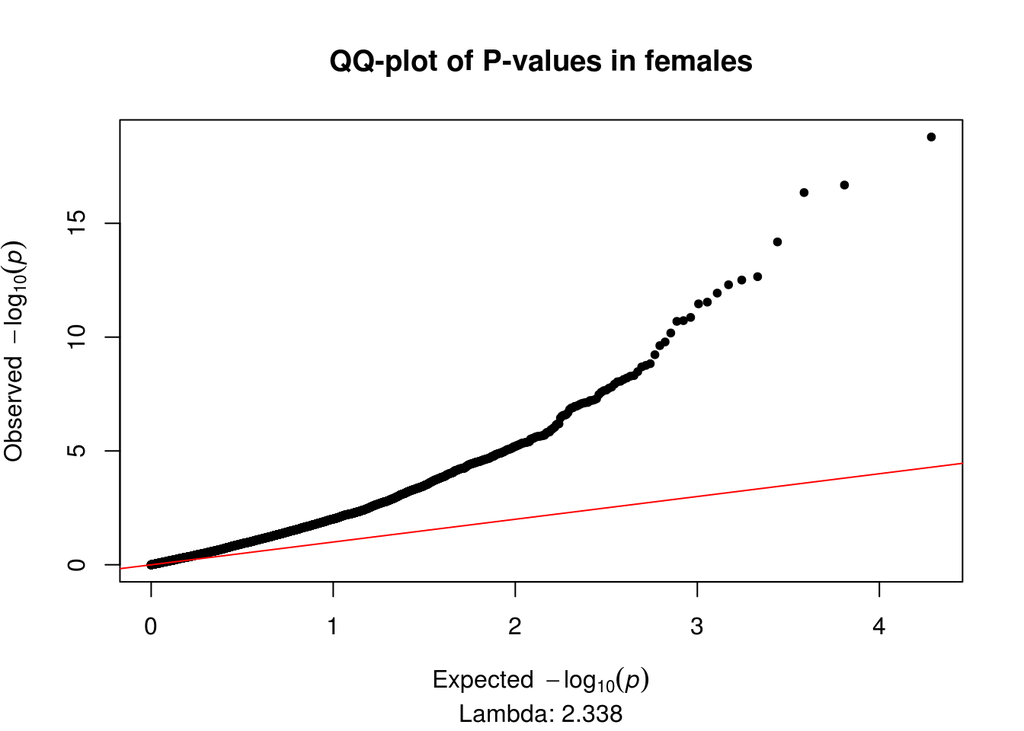

### Model All (43 SV)

The ANOVA of diagnosis has been run with all SVs. Tables of the top 1000 DMPs have been produced for each variable of interest.

#### Top DMPs

**ANOVA:**  
38 probes pass the epigenome-wide significance threshold of 2.4x10-7  
*The top 50 diagnosis associated DMPs:*

| ProbeID | Position | F | p (F) | FDR.Anova | Difference | CI lower | CI upper | pCvM | FDR | Difference | CI lower | CI upper | pCvA | FDR | Difference | CI lower | CI upper | pMvA | FDR | UCSC Gene | UCSC Gene Group | UCSC Relation to CpG Island | Gene Closest TSS | Distance Closest TSS | GREAT Annotation 1 | GREAT Annotation 2 |
| --- | --- | --- | --- | --- | --- | --- | --- | --- | --- | --- | --- | --- | --- | --- | --- | --- | --- | --- | --- | --- | --- | --- | --- | --- | --- | --- |
| cg22822140 | chr X: 153046577 | 58.160 | 6.79e-20 | 6.55e-16 | 0.001 | -0.017 | 0.019 | 0.989 | 1 | -0.071 | -0.089 | -0.053 | 4.95e-14 | 4.78e-10 | -0.072 | -0.090 | -0.054 | 4.72e-14 | 2.18e-10 | SRPK3;SRPK3;SRPK3 | 1stExon;1stExon;1stExon | Island | SRPK3 | 122 | SRPK3 (122) | (NA) |
| cg24496423 | chr X: 153046480 | 51.954 | 2.86e-18 | 1.38e-14 | 0.005 | -0.01 | 0.02 | 0.67 | 1 | -0.053 | -0.068 | -0.038 | 1.54e-13 | 7.44e-10 | -0.058 | -0.073 | -0.044 | 4.85e-14 | 2.18e-10 | SRPK3;SRPK3;SRPK3;SRPK3;SRPK3;SRPK3 | 5'UTR;1stExon;1stExon;5'UTR;5'UTR;1stExon | Island | SRPK3 | 25 | SRPK3 (25) | (NA) |
| cg12230162 | chr X: 153046482 | 42.530 | 1.18e-15 | 3.79e-12 | 0.011 | -0.01 | 0.031 | 0.455 | 1 | -0.064 | -0.085 | -0.043 | 4.50e-11 | 9.52e-08 | -0.075 | -0.095 | -0.054 | 6.78e-14 | 2.18e-10 | SRPK3;SRPK3;SRPK3;SRPK3;SRPK3;SRPK3 | 5'UTR;1stExon;1stExon;5'UTR;5'UTR;1stExon | Island | SRPK3 | 27 | SRPK3 (27) | (NA) |
| cg24605338 | chr X: 17395856 | 35.401 | 1.52e-13 | 3.44e-10 | -0.032 | -0.041 | -0.023 | 1.02e-13 | 9.80e-10 | -0.018 | -0.027 | -0.008 | 3.01e-05 | 0.004 | 0.014 | 0.005 | 0.023 | 5.59e-04 | 0.045 | NHS | Body | S_Shore | NHS | 2314 | SCML1 (-359735) | NHS (2314) |
| cg09768654 | chr X: 153046386 | 35.176 | 1.78e-13 | 3.44e-10 | 0.016 | -0.003 | 0.035 | 0.119 | 0.722 | -0.049 | -0.068 | -0.029 | 3.73e-08 | 3.00e-05 | -0.065 | -0.084 | -0.046 | 4.01e-13 | 9.68e-10 | SRPK3;SRPK3;SRPK3 | TSS200;TSS200;TSS200 | Island | SRPK3 | -69 | SRPK3 (-69) | (NA) |
| cg21252909 | chr X: 30326328 | 32.281 | 1.40e-12 | 2.26e-09 | 0.026 | 0.01 | 0.042 | 7.33e-04 | 0.043 | -0.03 | -0.046 | -0.013 | 1.27e-04 | 0.01 | -0.056 | -0.072 | -0.039 | 5.39e-13 | 1.04e-09 | NR0B1 | 1stExon | N_Shore | NR0B1 | 1167 | NR0B1 (1166) | (NA) |
| cg17219209 | chr X: 149009840 | 30.909 | 3.80e-12 | 4.70e-09 | 0.021 | 0.015 | 0.028 | 3.45e-12 | 1.67e-08 | 0.007 | 5.67e-04 | 0.014 | 0.03 | 0.331 | -0.014 | -0.020 | -0.008 | 2.47e-06 | 9.52e-04 | MAGEA8;MAGEA8;MAGEA8 | TSS200;TSS200;TSS200 |  | MAGEA8 | -100 | MAGEA8 (-100) | (NA) |
| cg16529483 | chr X: 153046451 | 30.723 | 4.35e-12 | 4.70e-09 | -0.005 | -0.025 | 0.015 | 0.803 | 1 | -0.06 | -0.08 | -0.040 | 1.44e-10 | 2.31e-07 | -0.054 | -0.074 | -0.035 | 2.29e-09 | 2.01e-06 | SRPK3;SRPK3;SRPK3 | TSS200;TSS200;TSS200 | Island | SRPK3 | -4 | SRPK3 (-4) | (NA) |
| cg09513996 | chr X: 48685182 | 30.711 | 4.39e-12 | 4.70e-09 | -7.94e-04 | -0.011 | 0.009 | 0.981 | 1 | -0.029 | -0.039 | -0.019 | 4.51e-10 | 5.43e-07 | -0.029 | -0.038 | -0.019 | 6.53e-10 | 7.00e-07 |  |  | Island | ERAS | -2100 | ERAS (-2100) | (NA) |
| cg13009143 | chr X: 100548223 | 29.328 | 1.21e-11 | 1.17e-08 | -0.011 | -0.017 | -0.005 | 1.10e-04 | 0.013 | 0.009 | 0.002 | 0.015 | 0.003 | 0.087 | 0.019 | 0.013 | 0.025 | 5.04e-12 | 8.10e-09 | TAF7L | TSS200 | S_Shore | TAF7L | -164 | TAF7L (-165) | (NA) |
| cg07069575 | chr X: 49688313 | 28.879 | 1.69e-11 | 1.48e-08 | 0.005 | -0.004 | 0.015 | 0.365 | 1 | -0.023 | -0.033 | -0.014 | 1.35e-07 | 8.13e-05 | -0.029 | -0.038 | -0.019 | 5.90e-11 | 8.13e-08 | CLCN5;CLCN5 | 5'UTR;5'UTR | S_Shore | CLCN5 | 1089 | CLCN5 (1089) | AKAP4 (277350) |
| cg12468189 | chr X: 153046767 | 28.578 | 2.12e-11 | 1.70e-08 | -0.016 | -0.028 | -0.003 | 0.011 | 0.224 | -0.041 | -0.053 | -0.028 | 1.17e-11 | 3.76e-08 | -0.025 | -0.038 | -0.012 | 1.70e-05 | 0.003 | SRPK3;SRPK3;SRPK3 | Body;Body;Body | Island | SRPK3 | 312 | SRPK3 (312) | (NA) |
| cg09661041 | chr X: 153141905 | 26.958 | 7.14e-11 | 5.29e-08 | -0.006 | -0.022 | 0.011 | 0.684 | 1 | -0.047 | -0.064 | -0.031 | 9.35e-10 | 9.02e-07 | -0.042 | -0.058 | -0.025 | 3.98e-08 | 2.40e-05 | L1CAM;L1CAM;L1CAM | TSS1500;TSS1500;TSS1500 |  | L1CAM | -506 | L1CAM (-507) | (NA) |
| cg19938385 | chr X: 107020894 | 26.863 | 7.67e-11 | 5.29e-08 | -0.036 | -0.052 | -0.021 | 1.79e-07 | 1.57e-04 | -0.045 | -0.06 | -0.029 | 3.31e-10 | 4.56e-07 | -0.008 | -0.023 | 0.007 | 0.394 | 1 |  |  | S_Shore | TSC22D3 | -1692 | TSC22D3 (-1878) | (NA) |
| cg07344627 | chr X: 125687011 | 26.400 | 1.09e-10 | 7.01e-08 | -0.033 | -0.051 | -0.015 | 8.21e-05 | 0.01 | -0.056 | -0.074 | -0.037 | 4.93e-11 | 9.52e-08 | -0.023 | -0.041 | -0.005 | 0.008 | 0.256 | DCAF12L1 | TSS200 | S_Shore | DCAF12L1 | -169 | DCAF12L1 (-170) | (NA) |
| cg16152676 | chr X: 10126878 | 26.079 | 1.39e-10 | 8.39e-08 | 0.027 | 0.015 | 0.039 | 5.75e-07 | 3.65e-04 | -0.007 | -0.019 | 0.005 | 0.39 | 1 | -0.034 | -0.046 | -0.022 | 5.48e-10 | 6.60e-07 | CLCN4 | 5'UTR | Island | CLCN4 | 550 | CLCN4 (1894) | MID1 (724930) |
| cg16122592 | chr X: 26210712 | 25.413 | 2.32e-10 | 1.31e-07 | -0.023 | -0.032 | -0.015 | 4.06e-09 | 1.30e-05 | -0.022 | -0.031 | -0.013 | 4.71e-08 | 3.50e-05 | 0.001 | -0.007 | 0.010 | 0.915 | 1 | MAGEB6 | 5'UTR |  | MAGEB6 | 156 | MAGEB6 (156) | (NA) |
| cg03360001 | chr X: 53453272 | 23.458 | 1.05e-09 | 5.63e-07 | -0.004 | -0.008 | 6.19e-04 | 0.105 | 0.687 | 0.009 | 0.004 | 0.014 | 2.73e-05 | 0.004 | 0.013 | 0.008 | 0.017 | 8.73e-10 | 8.43e-07 | RIBC1;RIBC1 | Body;Body | S_Shelf | RIBC1 | 3434 | SMC1A (-3655) | (NA) |
| cg12039689 | chr X: 153141750 | 23.136 | 1.35e-09 | 6.86e-07 | -0.019 | -0.036 | -0.003 | 0.019 | 0.304 | -0.049 | -0.066 | -0.032 | 6.95e-10 | 7.45e-07 | -0.029 | -0.046 | -0.012 | 1.71e-04 | 0.02 | L1CAM;L1CAM;L1CAM | TSS1500;TSS1500;TSS1500 |  | L1CAM | -351 | L1CAM (-352) | (NA) |
| cg22090245 | chr X: 99661860 | 22.710 | 1.89e-09 | 9.11e-07 | -0.01 | -0.031 | 0.011 | 0.502 | 1 | 0.046 | 0.025 | 0.067 | 2.28e-06 | 7.87e-04 | 0.055 | 0.035 | 0.076 | 5.68e-09 | 4.57e-06 | PCDH19;PCDH19 | 1stExon;1stExon | Island | PCDH19 | 3411 | PCDH19 (3410) | (NA) |
| cg11179997 | chr X: 119125670 | 21.262 | 5.94e-09 | 2.73e-06 | 0.022 | 0.013 | 0.031 | 2.68e-08 | 4.99e-05 | 0.004 | -0.005 | 0.012 | 0.569 | 1 | -0.018 | -0.027 | -0.010 | 3.40e-06 | 0.001 |  |  | Island | AK123976 | -44530 | NKAP (-47936) | RHOXF2 (86036) |
| cg25896901 | chr X: 125300481 | 20.948 | 7.63e-09 | 3.35e-06 | 0.008 | -0.012 | 0.028 | 0.643 | 1 | -0.043 | -0.064 | -0.023 | 3.39e-06 | 0.001 | -0.051 | -0.071 | -0.031 | 2.89e-08 | 1.86e-05 | DCAF12L2 | TSS1500 | S_Shore | DCAF12L2 | -401 | DCAF12L1 (386360) | (NA) |
| cg08464958 | chr X: 2852845 | 20.802 | 8.58e-09 | 3.60e-06 | -0.02 | -0.028 | -0.012 | 3.20e-08 | 4.99e-05 | -0.004 | -0.012 | 0.004 | 0.523 | 1 | 0.017 | 0.009 | 0.025 | 5.56e-06 | 0.002 | ARSE | 3'UTR |  | ARSD | -5429 | ARSD (-5430) | ARSE (29648) |
| cg06578851 | chr X: 101315561 | 19.615 | 2.23e-08 | 8.97e-06 | 0.02 | 0.002 | 0.038 | 0.025 | 0.349 | -0.027 | -0.045 | -0.009 | 0.001 | 0.055 | -0.047 | -0.065 | -0.029 | 1.01e-08 | 7.46e-06 |  |  |  | TCEAL2 | -65098 | ZMAT1 (-128523) | TCEAL2 (-65098) |
| cg04867253 | chr X: 70472827 | 19.348 | 2.77e-08 | 1.07e-05 | -0.009 | -0.021 | 0.004 | 0.235 | 0.935 | 0.024 | 0.011 | 0.036 | 7.74e-05 | 0.007 | 0.032 | 0.020 | 0.045 | 2.88e-08 | 1.86e-05 | ZMYM3;ZMYM3;BCYRN1;ZMYM3;ZMYM3 | Body;Body;Body;Body;Body | N_Shore | ZMYM3 | 1211 | ZMYM3 (1210) | GJB1 (37766) |
| cg17405188 | chr X: 73164102 | 19.087 | 3.42e-08 | 1.27e-05 | 0.004 | -3.48e-04 | 0.008 | 0.081 | 0.612 | 0.01 | 0.006 | 0.015 | 2.38e-08 | 2.08e-05 | 0.007 | 0.003 | 0.011 | 2.62e-04 | 0.026 | LOC554203 | TSS200 | Island | JPX | -56 | ZCCHC13 (-359922) | CHIC1 (381119) |
| cg19280671 | chr X: 149013642 | 18.513 | 5.47e-08 | 1.95e-05 | 0.012 | 0.006 | 0.017 | 2.63e-06 | 0.001 | -5.39e-04 | -0.006 | 0.005 | 0.971 | 1 | -0.012 | -0.018 | -0.007 | 7.85e-07 | 3.73e-04 | MAGEA8;MAGEA8;MAGEA8 | Body;Body;Body |  | MAGEA8 | 596 | MAMLD1 (-517908) | MAGEA8 (3702) |
| cg17513789 | chr X: 73073251 | 18.417 | 5.92e-08 | 2.04e-05 | -0.031 | -0.043 | -0.019 | 2.51e-08 | 4.99e-05 | -0.016 | -0.028 | -0.004 | 0.007 | 0.142 | 0.015 | 0.003 | 0.027 | 0.009 | 0.276 | XIST | TSS1500 |  | XIST | -663 | ZCCHC13 (-450773) | CHIC1 (290268) |
| cg14917571 | chr X: 79269151 | 17.851 | 9.42e-08 | 3.03e-05 | -0.035 | -0.05 | -0.021 | 4.14e-08 | 4.99e-05 | -0.02 | -0.034 | -0.005 | 0.004 | 0.099 | 0.016 | 0.002 | 0.030 | 0.022 | 0.418 | TBX22;TBX22 | TSS1500;TSS1500 |  | TBX22 | -1103 | ITM2A (-646103) | TBX22 (-8590) |
| cg06915915 | chr X: 129657974 | 17.849 | 9.44e-08 | 3.03e-05 | 0.03 | 0.018 | 0.042 | 4.11e-08 | 4.99e-05 | 0.017 | 0.004 | 0.029 | 0.005 | 0.107 | -0.014 | -0.026 | -0.002 | 0.019 | 0.386 |  |  |  | BC043223 | 257 | RBMX2 (122032) | ENOX2 (379233) |
| cg19002579 | chr X: 21776218 | 17.567 | 1.19e-07 | 3.71e-05 | 0.038 | 0.018 | 0.059 | 6.56e-05 | 0.009 | 0.051 | 0.03 | 0.072 | 1.78e-07 | 9.53e-05 | 0.012 | -0.009 | 0.033 | 0.348 | 1 | SMPX;SMPX | 1stExon;5'UTR |  | SMPX | 60 | SMPX (59) | (NA) |
| cg17792806 | chr X: 102585107 | 17.466 | 1.29e-07 | 3.88e-05 | 0.033 | 0.02 | 0.047 | 7.13e-08 | 7.64e-05 | 0.021 | 0.007 | 0.035 | 0.001 | 0.042 | -0.012 | -0.026 | 0.001 | 0.077 | 0.734 | TCEAL7 | TSS200 |  | TCEAL7 | -6 | TCEAL7 (-6) | (NA) |
| cg08630881 | chr X: 70713213 | 17.437 | 1.33e-07 | 3.88e-05 | -0.023 | -0.032 | -0.013 | 1.12e-07 | 1.08e-04 | -0.016 | -0.026 | -0.007 | 2.52e-04 | 0.016 | 0.007 | -0.003 | 0.016 | 0.208 | 1 | BCYRN1;INGX | Body;TSS1500 | S_Shore | INGX | -609 | OGT (-39698) | TAF1 (127100) |
| cg01737010 | chr X: 101772014 | 17.335 | 1.44e-07 | 4.10e-05 | 0.004 | -0.004 | 0.012 | 0.388 | 1 | -0.014 | -0.023 | -0.006 | 1.00e-04 | 0.008 | -0.019 | -0.027 | -0.011 | 1.95e-07 | 1.11e-04 | TMSB15A | TSS1500 | S_Shore | TMSB15A | -315 | TMSB15A (-316) | (NA) |
| cg16084857 | chr X: 130216575 | 16.987 | 1.93e-07 | 5.31e-05 | -0.006 | -0.018 | 0.006 | 0.445 | 1 | -0.029 | -0.041 | -0.016 | 3.78e-07 | 1.82e-04 | -0.022 | -0.034 | -0.010 | 5.78e-05 | 0.01 | FLJ30058 | Body | Island | ARHGAP36 | -1108 | ARHGAP36 (24360) | IGSF1 (206827) |
| cg07865294 | chr X: 30248557 | 16.854 | 2.15e-07 | 5.77e-05 | 0.018 | -1.11e-04 | 0.035 | 0.052 | 0.496 | 0.044 | 0.026 | 0.061 | 1.16e-07 | 7.86e-05 | 0.026 | 0.008 | 0.044 | 0.002 | 0.097 | MAGEB3;MAGEB3 | 1stExon;5'UTR |  | MAGEB3 | 5 | NR0B1 (78937) | (NA) |
| cg27429569 | chr X: 153170461 | 16.779 | 2.29e-07 | 5.89e-05 | 0.011 | -2.86e-05 | 0.023 | 0.051 | 0.491 | 0.028 | 0.016 | 0.039 | 1.22e-07 | 7.86e-05 | 0.017 | 0.005 | 0.028 | 0.002 | 0.101 | AVPR2;AVPR2;AVPR2 | TSS200;TSS200;Body |  | AVPR2 | 34 | AVPR2 (34) | (NA) |
| ch.X.94051109R | chr X: 94164453 | 16.762 | 2.32e-07 | 5.89e-05 | 0.006 | 0.003 | 0.009 | 2.88e-05 | 0.005 | 0.007 | 0.004 | 0.011 | 6.92e-07 | 2.78e-04 | 0.001 | -0.002 | 0.004 | 0.638 | 1 |  |  |  | Mir_548 | 153771 | NONE (NA) | (NA) |
| cg06452970 | chr X: 13835264 | 16.593 | 2.67e-07 | 6.61e-05 | 0.028 | 0.016 | 0.04 | 4.58e-07 | 3.40e-04 | 0.007 | -0.006 | 0.019 | 0.409 | 1 | -0.022 | -0.034 | -0.009 | 1.25e-04 | 0.017 | GPM6B;GPM6B;GPM6B;GPM6B;GPM6B;GPM6B;GPM6B | 1stExon;5'UTR;5'UTR;Body;5'UTR;1stExon;1stExon |  | GPM6B | 50 | GPM6B (49) | (NA) |
| cg04710661 | chr X: 2848381 | 16.464 | 2.98e-07 | 7.18e-05 | 0.006 | 1.06e-04 | 0.013 | 0.045 | 0.467 | 0.015 | 0.009 | 0.022 | 1.53e-07 | 8.70e-05 | 0.009 | 0.003 | 0.015 | 0.002 | 0.125 | ARSD;ARSD | TSS1500;TSS1500 | S_Shore | ARSD | -965 | ARSD (-966) | (NA) |
| cg10262485 | chr X: 77395543 | 16.112 | 4.00e-07 | 9.41e-05 | 0.029 | 0.017 | 0.042 | 2.43e-07 | 1.96e-04 | 0.019 | 0.007 | 0.032 | 0.001 | 0.048 | -0.01 | -0.023 | 0.002 | 0.121 | 0.893 | TAF9B | TSS1500 | S_Shore | TAF9B | -364 | TAF9B (-365) | (NA) |
| cg00190642 | chr X: 103268431 | 15.961 | 4.54e-07 | 1.04e-04 | -0.009 | -0.021 | 0.003 | 0.165 | 0.83 | 0.019 | 0.007 | 0.031 | 9.67e-04 | 0.04 | 0.028 | 0.016 | 0.040 | 3.12e-07 | 1.67e-04 | H2BFWT;MIR1256 | TSS200;Body | Island | H2BFWT | -175 | H2BFWT (-176) | (NA) |
| cg00615010 | chr X: 103809062 | 15.841 | 5.02e-07 | 1.11e-04 | -0.017 | -0.032 | -0.003 | 0.013 | 0.24 | -0.035 | -0.049 | -0.020 | 2.25e-07 | 1.14e-04 | -0.017 | -0.032 | -0.003 | 0.014 | 0.335 |  |  | N_Shore | IL1RAPL2 | -1933 | IL1RAPL2 (-1933) | (NA) |
| cg03198117 | chr X: 152939967 | 15.826 | 5.08e-07 | 1.11e-04 | 0.021 | 0.009 | 0.034 | 2.00e-04 | 0.019 | -0.007 | -0.019 | 0.006 | 0.433 | 1 | -0.028 | -0.040 | -0.016 | 8.04e-07 | 3.73e-04 | PNCK;PNCK | TSS1500;TSS200 | S_Shore | PNCK | -151 | PNCK (-152) | (NA) |
| cg04768884 | chr X: 19443172 | 15.809 | 5.16e-07 | 1.11e-04 | -6.62e-04 | -0.012 | 0.01 | 0.989 | 1 | 0.022 | 0.011 | 0.034 | 1.25e-05 | 0.002 | 0.023 | 0.012 | 0.034 | 4.58e-06 | 0.002 | MAP3K15 | Body |  | MAP3K15 | 35099 | PDHA1 (81162) | MAP3K15 (90206) |
| cg16546861 | chr X: 49022452 | 15.749 | 5.42e-07 | 1.14e-04 | -0.014 | -0.02 | -0.007 | 7.12e-06 | 0.002 | -0.014 | -0.02 | -0.007 | 7.67e-06 | 0.002 | -1.27e-04 | -0.007 | 0.006 | 0.999 | 1 | MAGIX;MAGIX;MAGIX;MAGIX | Body;Body;Body;Body | Island | MAGIX | 2183 | GPKOW (-42374) | PLP2 (-5731) |
| cg17586516 | chr X: 70502859 | 15.678 | 5.76e-07 | 1.18e-04 | 0.022 | 0.008 | 0.035 | 7.74e-04 | 0.043 | 0.032 | 0.018 | 0.046 | 4.25e-07 | 1.86e-04 | 0.011 | -0.003 | 0.024 | 0.157 | 0.986 | NONO;NONO;NONO;BCYRN1;NONO | TSS200;TSS200;TSS200;Body;TSS200 | N_Shore | NONO | -182 | NONO (-182) | (NA) |
| cg20784188 | chr X: 44703983 | 15.657 | 5.86e-07 | 1.18e-04 | 3.23e-04 | -0.008 | 0.009 | 0.995 | 1 | -0.017 | -0.025 | -0.008 | 1.23e-05 | 0.002 | -0.017 | -0.025 | -0.009 | 5.64e-06 | 0.002 | DUSP21;DUSP21 | 3'UTR;1stExon | S_Shore | DUSP21 | 735 | DUSP21 (735) | (NA) |
| cg00123001 | chr X: 13395880 | 15.601 | 6.14e-07 | 1.21e-04 | -0.012 | -0.018 | -0.006 | 4.07e-05 | 0.006 | -0.014 | -0.02 | -0.008 | 2.11e-06 | 7.87e-04 | -0.002 | -0.008 | 0.004 | 0.737 | 1 |  |  | N_Shore | LOC100133123 | 42521 | EGFL6 (-191813) | ATXN3L (-57363) |
| cg06616051 | chr X: 153094332 | 15.481 | 6.80e-07 | 1.31e-04 | 0.013 | -0.002 | 0.027 | 0.097 | 0.667 | 0.034 | 0.019 | 0.049 | 4.21e-07 | 1.86e-04 | 0.021 | 0.007 | 0.036 | 0.002 | 0.097 | PDZD4 | Body | Island | PDZD4 | 1019 | IDH3G (-34366) | PDZD4 (1670) |

**CTL vs MCI:**  
11 probes pass the epigenome-wide significance threshold of 2.4x10-7

*The top 50 CTL vs MCI associated DMPs:*

| ProbeID | Position | F | p (F) | FDR.Anova | Difference | CI lower | CI upper | pCvM | FDR | Difference | CI lower | CI upper | pCvA | FDR | Difference | CI lower | CI upper | pMvA | FDR | UCSC Gene | UCSC Gene Group | UCSC Relation to CpG Island | Gene Closest TSS | Distance Closest TSS | GREAT Annotation 1 | GREAT Annotation 2 |
| --- | --- | --- | --- | --- | --- | --- | --- | --- | --- | --- | --- | --- | --- | --- | --- | --- | --- | --- | --- | --- | --- | --- | --- | --- | --- | --- |
| cg24605338 | chr X: 17395856 | 35.401 | 1.52e-13 | 3.44e-10 | -0.032 | -0.041 | -0.023 | 1.02e-13 | 9.80e-10 | -0.018 | -0.027 | -0.008 | 3.01e-05 | 0.004 | 0.014 | 0.005 | 0.023 | 5.59e-04 | 0.045 | NHS | Body | S_Shore | NHS | 2314 | SCML1 (-359735) | NHS (2314) |
| cg17219209 | chr X: 149009840 | 30.909 | 3.80e-12 | 4.70e-09 | 0.021 | 0.015 | 0.028 | 3.45e-12 | 1.67e-08 | 0.007 | 5.67e-04 | 0.014 | 0.03 | 0.331 | -0.014 | -0.02 | -0.008 | 2.47e-06 | 9.52e-04 | MAGEA8;MAGEA8;MAGEA8 | TSS200;TSS200;TSS200 |  | MAGEA8 | -100 | MAGEA8 (-100) | (NA) |
| cg16122592 | chr X: 26210712 | 25.413 | 2.32e-10 | 1.31e-07 | -0.023 | -0.032 | -0.015 | 4.06e-09 | 1.30e-05 | -0.022 | -0.031 | -0.013 | 4.71e-08 | 3.50e-05 | 0.001 | -0.007 | 0.01 | 0.915 | 1 | MAGEB6 | 5'UTR |  | MAGEB6 | 156 | MAGEB6 (156) | (NA) |
| cg17513789 | chr X: 73073251 | 18.417 | 5.92e-08 | 2.04e-05 | -0.031 | -0.043 | -0.019 | 2.51e-08 | 4.99e-05 | -0.016 | -0.028 | -0.004 | 0.007 | 0.142 | 0.015 | 0.003 | 0.027 | 0.009 | 0.276 | XIST | TSS1500 |  | XIST | -663 | ZCCHC13 (-450773) | CHIC1 (290268) |
| cg11179997 | chr X: 119125670 | 21.262 | 5.94e-09 | 2.73e-06 | 0.022 | 0.013 | 0.031 | 2.68e-08 | 4.99e-05 | 0.004 | -0.005 | 0.012 | 0.569 | 1 | -0.018 | -0.027 | -0.01 | 3.40e-06 | 0.001 |  |  | Island | AK123976 | -44530 | NKAP (-47936) | RHOXF2 (86036) |
| cg08464958 | chr X: 2852845 | 20.802 | 8.58e-09 | 3.60e-06 | -0.020 | -0.028 | -0.012 | 3.20e-08 | 4.99e-05 | -0.004 | -0.012 | 0.004 | 0.523 | 1 | 0.017 | 0.009 | 0.025 | 5.56e-06 | 0.002 | ARSE | 3'UTR |  | ARSD | -5429 | ARSD (-5430) | ARSE (29648) |
| cg06915915 | chr X: 129657974 | 17.849 | 9.44e-08 | 3.03e-05 | 0.030 | 0.018 | 0.042 | 4.11e-08 | 4.99e-05 | 0.017 | 0.004 | 0.029 | 0.005 | 0.107 | -0.014 | -0.026 | -0.002 | 0.019 | 0.386 |  |  |  | BC043223 | 257 | RBMX2 (122032) | ENOX2 (379233) |
| cg14917571 | chr X: 79269151 | 17.851 | 9.42e-08 | 3.03e-05 | -0.035 | -0.050 | -0.021 | 4.14e-08 | 4.99e-05 | -0.02 | -0.034 | -0.005 | 0.004 | 0.099 | 0.016 | 0.002 | 0.03 | 0.022 | 0.418 | TBX22;TBX22 | TSS1500;TSS1500 |  | TBX22 | -1103 | ITM2A (-646103) | TBX22 (-8590) |
| cg17792806 | chr X: 102585107 | 17.466 | 1.29e-07 | 3.88e-05 | 0.033 | 0.020 | 0.047 | 7.13e-08 | 7.64e-05 | 0.021 | 0.007 | 0.035 | 0.001 | 0.042 | -0.012 | -0.026 | 0.001 | 0.077 | 0.734 | TCEAL7 | TSS200 |  | TCEAL7 | -6 | TCEAL7 (-6) | (NA) |
| cg08630881 | chr X: 70713213 | 17.437 | 1.33e-07 | 3.88e-05 | -0.023 | -0.032 | -0.013 | 1.12e-07 | 1.08e-04 | -0.016 | -0.026 | -0.007 | 2.52e-04 | 0.016 | 0.007 | -0.003 | 0.016 | 0.208 | 1 | BCYRN1;INGX | Body;TSS1500 | S_Shore | INGX | -609 | OGT (-39698) | TAF1 (127100) |
| cg19938385 | chr X: 107020894 | 26.863 | 7.67e-11 | 5.29e-08 | -0.036 | -0.052 | -0.021 | 1.79e-07 | 1.57e-04 | -0.045 | -0.06 | -0.029 | 3.31e-10 | 4.56e-07 | -0.008 | -0.023 | 0.007 | 0.394 | 1 |  |  | S_Shore | TSC22D3 | -1692 | TSC22D3 (-1878) | (NA) |
| cg10262485 | chr X: 77395543 | 16.112 | 4.00e-07 | 9.41e-05 | 0.029 | 0.017 | 0.042 | 2.43e-07 | 1.96e-04 | 0.019 | 0.007 | 0.032 | 0.001 | 0.048 | -0.01 | -0.023 | 0.002 | 0.121 | 0.893 | TAF9B | TSS1500 | S_Shore | TAF9B | -364 | TAF9B (-365) | (NA) |
| cg06452970 | chr X: 13835264 | 16.593 | 2.67e-07 | 6.61e-05 | 0.028 | 0.016 | 0.040 | 4.58e-07 | 3.40e-04 | 0.007 | -0.006 | 0.019 | 0.409 | 1 | -0.022 | -0.034 | -0.009 | 1.25e-04 | 0.017 | GPM6B;GPM6B;GPM6B;GPM6B;GPM6B;GPM6B;GPM6B | 1stExon;5'UTR;5'UTR;Body;5'UTR;1stExon;1stExon |  | GPM6B | 50 | GPM6B (49) | (NA) |
| cg08282969 | chr X: 122993891 | 15.014 | 1.01e-06 | 1.80e-04 | 0.014 | 0.008 | 0.021 | 5.25e-07 | 3.62e-04 | 0.009 | 0.002 | 0.015 | 0.004 | 0.1 | -0.006 | -0.012 | 5.09e-04 | 0.079 | 0.743 | XIAP | TSS200 | Island | XIAP | -125 | XIAP (-125) | (NA) |
| cg16152676 | chr X: 10126878 | 26.079 | 1.39e-10 | 8.39e-08 | 0.027 | 0.015 | 0.039 | 5.75e-07 | 3.65e-04 | -0.007 | -0.019 | 0.005 | 0.39 | 1 | -0.034 | -0.046 | -0.022 | 5.48e-10 | 6.60e-07 | CLCN4 | 5'UTR | Island | CLCN4 | 550 | CLCN4 (1894) | MID1 (724930) |
| cg24834461 | chr X: 153637645 | 14.969 | 1.05e-06 | 1.84e-04 | 0.014 | 0.008 | 0.019 | 6.06e-07 | 3.65e-04 | 0.009 | 0.003 | 0.015 | 0.002 | 0.076 | -0.005 | -0.011 | 9.25e-04 | 0.117 | 0.882 | DNASE1L1;DNASE1L1;DNASE1L1;DNASE1L1 | TSS200;5'UTR;5'UTR;5'UTR | N_Shelf | DNASE1L1 | -70 | TAZ (-2231) | (NA) |
| cg09953945 | chr X: 150345040 | 14.611 | 1.42e-06 | 2.28e-04 | -0.020 | -0.029 | -0.011 | 7.68e-07 | 4.19e-04 | -0.013 | -0.022 | -0.003 | 0.004 | 0.099 | 0.008 | -0.001 | 0.017 | 0.096 | 0.81 | GPR50 | TSS200 | N_Shore | GPR50 | -15 | GPR50 (-15) | (NA) |
| cg13613450 | chr X: 136657310 | 14.439 | 1.64e-06 | 2.48e-04 | 0.029 | 0.016 | 0.041 | 7.83e-07 | 4.19e-04 | 0.014 | 9.80e-04 | 0.027 | 0.032 | 0.342 | -0.015 | -0.028 | -0.002 | 0.016 | 0.347 |  |  | S_Shore | ZIC3 | 8965 | ZIC3 (8965) | (NA) |
| cg06891491 | chr X: 134429749 | 15.241 | 8.32e-07 | 1.54e-04 | -0.031 | -0.045 | -0.017 | 9.19e-07 | 4.67e-04 | -0.023 | -0.038 | -0.009 | 3.39e-04 | 0.02 | 0.008 | -0.006 | 0.022 | 0.374 | 1 | ZNF75D | 5'UTR | Island | ZNF75D | 216 | ZNF75D (215) | (NA) |
| cg11315455 | chr X: 122997585 | 14.449 | 1.63e-06 | 2.48e-04 | -0.018 | -0.026 | -0.010 | 1.06e-06 | 5.11e-04 | -0.007 | -0.015 | 0.001 | 0.125 | 0.682 | 0.011 | 0.003 | 0.019 | 0.003 | 0.141 | XIAP | 5'UTR | S_Shelf | XIAP | 3569 | STAG2 (-96889) | XIAP (3569) |
| cg04817724 | chr X: 103809991 | 14.283 | 1.88e-06 | 2.69e-04 | 0.034 | 0.019 | 0.050 | 1.43e-06 | 6.55e-04 | 0.012 | -0.004 | 0.027 | 0.181 | 0.783 | -0.022 | -0.038 | -0.007 | 0.002 | 0.11 | IL1RAPL2 | TSS1500 | Island | IL1RAPL2 | -1004 | IL1RAPL2 (-1004) | (NA) |
| cg19280671 | chr X: 149013642 | 18.513 | 5.47e-08 | 1.95e-05 | 0.012 | 0.006 | 0.017 | 2.63e-06 | 0.001 | -5.39e-04 | -0.006 | 0.005 | 0.971 | 1 | -0.012 | -0.018 | -0.007 | 7.85e-07 | 3.73e-04 | MAGEA8;MAGEA8;MAGEA8 | Body;Body;Body |  | MAGEA8 | 596 | MAMLD1 (-517908) | MAGEA8 (3702) |
| cg05860920 | chr X: 11679501 | 13.074 | 5.31e-06 | 5.31e-04 | 0.042 | 0.022 | 0.061 | 2.74e-06 | 0.001 | 0.024 | 0.005 | 0.044 | 0.011 | 0.178 | -0.017 | -0.037 | 0.002 | 0.085 | 0.773 | ARHGAP6;ARHGAP6 | Body;Body | N_Shelf | ARHGAP6 | 4320 | ARHGAP6 (4319) | AMELX (367969) |
| cg09979033 | chr X: 16726904 | 13.055 | 5.40e-06 | 5.31e-04 | -0.015 | -0.021 | -0.008 | 3.13e-06 | 0.001 | -0.009 | -0.016 | -0.002 | 0.006 | 0.121 | 0.005 | -0.001 | 0.012 | 0.141 | 0.957 | CTPS2;CTPS2;CTPS2 | 5'UTR;5'UTR;5'UTR | N_Shelf | CTPS2 | 3436 | CTPS2 (4154) | S100G (58624) |
| cg15907464 | chr X: 70712790 | 13.148 | 4.98e-06 | 5.23e-04 | -0.024 | -0.035 | -0.013 | 3.29e-06 | 0.001 | -0.016 | -0.027 | -0.004 | 0.003 | 0.09 | 0.008 | -0.003 | 0.019 | 0.201 | 1 | BCYRN1;INGX | Body;TSS200 | Island | INGX | -186 | OGT (-40121) | TAF1 (126677) |
| cg27558057 | chr X: 70712724 | 12.864 | 6.37e-06 | 5.97e-04 | -0.021 | -0.030 | -0.011 | 3.74e-06 | 0.001 | -0.008 | -0.018 | 0.001 | 0.113 | 0.643 | 0.012 | 0.003 | 0.022 | 0.009 | 0.264 | BCYRN1;INGX | Body;TSS200 | Island | INGX | -120 | OGT (-40187) | TAF1 (126611) |
| cg17003204 | chr X: 102861456 | 13.941 | 2.52e-06 | 3.20e-04 | -0.019 | -0.028 | -0.010 | 3.81e-06 | 0.001 | -0.005 | -0.014 | 0.005 | 0.468 | 1 | 0.015 | 0.006 | 0.024 | 4.88e-04 | 0.041 | TCEAL3;TCEAL3 | TSS1500;TSS1500 | N_Shore | TCEAL3 | -1377 | TCEAL3 (-1377) | (NA) |
| ch.X.153018199F | chr X: 153365005 | 14.676 | 1.34e-06 | 2.20e-04 | -0.008 | -0.012 | -0.004 | 3.82e-06 | 0.001 | -0.001 | -0.005 | 0.003 | 0.685 | 1 | 0.007 | 0.003 | 0.011 | 1.25e-04 | 0.017 |  |  | S_Shore | MECP2 | -1817 | MECP2 (-1818) | (NA) |
| cg03035653 | chr X: 99662932 | 12.573 | 8.20e-06 | 7.12e-04 | 0.029 | 0.015 | 0.043 | 4.52e-06 | 0.002 | 0.012 | -0.001 | 0.026 | 0.091 | 0.579 | -0.017 | -0.03 | -0.003 | 0.013 | 0.328 | PCDH19;PCDH19 | 1stExon;1stExon | Island | PCDH19 | 2339 | PCDH19 (2338) | (NA) |
| cg12461113 | chr X: 13587550 | 12.942 | 5.95e-06 | 5.80e-04 | -0.051 | -0.075 | -0.027 | 4.97e-06 | 0.002 | -0.017 | -0.041 | 0.008 | 0.252 | 0.892 | 0.034 | 0.01 | 0.058 | 0.003 | 0.131 | EGFL6;EGFL6 | TSS200;TSS200 | N_Shore | EGFL6 | -143 | EGFL6 (-143) | (NA) |
| cg13699065 | chr X: 136511500 | 13.566 | 3.47e-06 | 4.14e-04 | 0.029 | 0.015 | 0.043 | 5.23e-06 | 0.002 | 0.023 | 0.009 | 0.037 | 3.91e-04 | 0.022 | -0.006 | -0.019 | 0.008 | 0.578 | 1 |  |  | S_Shore | ZIC3 | -136845 | GPR101 (-397668) | ZIC3 (-136845) |
| cg04769341 | chr X: 102585202 | 12.760 | 6.97e-06 | 6.42e-04 | 0.035 | 0.018 | 0.051 | 5.68e-06 | 0.002 | 0.025 | 0.008 | 0.041 | 0.002 | 0.069 | -0.01 | -0.027 | 0.006 | 0.313 | 1 | TCEAL7;TCEAL7 | 1stExon;5'UTR |  | TCEAL7 | 89 | TCEAL7 (89) | (NA) |
| cg20367266 | chr X: 102585123 | 12.134 | 1.20e-05 | 9.31e-04 | 0.039 | 0.020 | 0.058 | 6.06e-06 | 0.002 | 0.021 | 0.002 | 0.04 | 0.023 | 0.282 | -0.018 | -0.036 | 0.001 | 0.069 | 0.699 | TCEAL7 | TSS200 |  | TCEAL7 | 10 | TCEAL7 (10) | (NA) |
| cg16546861 | chr X: 49022452 | 15.749 | 5.42e-07 | 1.14e-04 | -0.014 | -0.020 | -0.007 | 7.12e-06 | 0.002 | -0.014 | -0.02 | -0.007 | 7.67e-06 | 0.002 | -1.27e-04 | -0.007 | 0.006 | 0.999 | 1 | MAGIX;MAGIX;MAGIX;MAGIX | Body;Body;Body;Body | Island | MAGIX | 2183 | GPKOW (-42374) | PLP2 (-5731) |
| cg26484667 | chr X: 2733164 | 13.230 | 4.64e-06 | 5.09e-04 | -0.021 | -0.032 | -0.011 | 7.28e-06 | 0.002 | -0.005 | -0.015 | 0.006 | 0.515 | 1 | 0.016 | 0.006 | 0.027 | 6.26e-04 | 0.049 | XG;XG;XG | 3'UTR;3'UTR;3'UTR |  | GYG2 | -13698 | GYG2 (-13698) | XG (63072) |
| cg20881335 | chr X: 14547172 | 13.754 | 2.96e-06 | 3.66e-04 | 0.044 | 0.023 | 0.065 | 7.60e-06 | 0.002 | 0.008 | -0.014 | 0.029 | 0.691 | 1 | -0.037 | -0.058 | -0.015 | 2.21e-04 | 0.023 | GLRA2;GLRA2;GLRA2 | TSS1500;TSS1500;TSS1500 |  | GLRA2 | -247 | GLRA2 (-247) | (NA) |
| cg18096956 | chr X: 5817998 | 12.647 | 7.69e-06 | 6.86e-04 | -0.009 | -0.013 | -0.005 | 7.64e-06 | 0.002 | -0.007 | -0.011 | -0.002 | 0.001 | 0.052 | 0.002 | -0.002 | 0.007 | 0.417 | 1 | NLGN4X;NLGN4X | Body;Body | N_Shelf | NLGN4Y | 251814 | NLGN4X (328707) | (NA) |
| cg04820200 | chr X: 41191871 | 11.819 | 1.58e-05 | 0.001 | -0.013 | -0.019 | -0.007 | 8.45e-06 | 0.002 | -0.008 | -0.014 | -0.001 | 0.016 | 0.225 | 0.005 | -8.99e-04 | 0.012 | 0.109 | 0.865 | DDX3X | TSS1500 | N_Shore | DDX3X | -779 | DDX3X (-779) | (NA) |
| cg25958561 | chr X: 110187179 | 15.387 | 7.36e-07 | 1.39e-04 | 0.023 | 0.012 | 0.034 | 8.95e-06 | 0.002 | 0.023 | 0.012 | 0.034 | 1.00e-05 | 0.002 | 1.67e-04 | -0.011 | 0.011 | 0.999 | 1 | PAK3;PAK3 | TSS1500;TSS1500 |  | PAK3 | -333 | PAK3 (-179125) | CHRDL1 (-148104) |
| cg02396917 | chr X: 19988369 | 13.065 | 5.35e-06 | 5.31e-04 | -0.014 | -0.021 | -0.007 | 1.05e-05 | 0.003 | -0.003 | -0.01 | 0.004 | 0.617 | 1 | 0.011 | 0.004 | 0.018 | 4.61e-04 | 0.041 | CXorf23 | 1stExon |  | CXorf23 | 13 | CXorf23 (12) | (NA) |
| cg17481638 | chr X: 10090596 | 11.786 | 1.63e-05 | 0.001 | -0.017 | -0.026 | -0.009 | 1.08e-05 | 0.003 | -0.011 | -0.02 | -0.003 | 0.006 | 0.125 | 0.006 | -0.003 | 0.014 | 0.232 | 1 | WWC3 | Body | N_Shelf | CLCN4 | -34388 | CLCN4 (-34388) | SHROOM2 (336101) |
| cg25831435 | chr X: 137714452 | 12.661 | 7.59e-06 | 6.84e-04 | -0.020 | -0.030 | -0.010 | 1.31e-05 | 0.003 | -0.017 | -0.027 | -0.006 | 4.75e-04 | 0.024 | 0.004 | -0.006 | 0.013 | 0.677 | 1 | FGF13;FGF13;FGF13;FGF13;FGF13;FGF13 | 3'UTR;3'UTR;3'UTR;3'UTR;3'UTR;3'UTR |  | LOC158696 | -14653 | FGF13 (572732) | (NA) |
| cg14495593 | chr X: 27999546 | 11.791 | 1.62e-05 | 0.001 | 0.019 | 0.009 | 0.028 | 1.59e-05 | 0.004 | 0.014 | 0.004 | 0.024 | 0.002 | 0.069 | -0.005 | -0.014 | 0.005 | 0.443 | 1 | DCAF8L1;DCAF8L1 | 5'UTR;1stExon |  | DCAF8L1 | 20 | IL1RAPL1 (-606134) | SMEK3P (-518089) |
| cg01067505 | chr X: 107178820 | 15.119 | 9.22e-07 | 1.68e-04 | 0.039 | 0.020 | 0.059 | 1.63e-05 | 0.004 | -4.88e-04 | -0.021 | 0.02 | 0.998 | 1 | -0.04 | -0.059 | -0.02 | 1.15e-05 | 0.003 |  |  | N_Shore | BC070370 | 4978 | VSIG1 (-109379) | MID2 (109737) |
| cg17814335 | chr X: 74143945 | 11.002 | 3.25e-05 | 0.002 | -0.024 | -0.036 | -0.012 | 1.68e-05 | 0.004 | -0.012 | -0.024 | 2.97e-04 | 0.058 | 0.471 | 0.012 | -4.77e-06 | 0.024 | 0.05 | 0.623 | KIAA2022 | 5'UTR | Island | KIAA2022 | 1342 | RLIM (-309485) | KIAA2022 (1341) |
| cg25433595 | chr X: 100183764 | 13.458 | 3.81e-06 | 4.43e-04 | 0.028 | 0.014 | 0.042 | 1.70e-05 | 0.004 | 0.026 | 0.012 | 0.04 | 8.35e-05 | 0.008 | -0.002 | -0.016 | 0.012 | 0.943 | 1 | XKRX;XKRX | 5'UTR;1stExon | N_Shore | XKRX | 134 | XKRX (133) | (NA) |
| cg06442844 | chr X: 117958793 | 12.684 | 7.44e-06 | 6.77e-04 | -0.037 | -0.057 | -0.018 | 2.01e-05 | 0.004 | -0.033 | -0.052 | -0.014 | 2.37e-04 | 0.016 | 0.004 | -0.015 | 0.023 | 0.843 | 1 | ZCCHC12 | 5'UTR | S_Shore | ZCCHC12 | -414 | LONRF3 (-149919) | ZCCHC12 (1007) |
| cg05376895 | chr X: 152225366 | 11.276 | 2.55e-05 | 0.002 | 0.036 | 0.018 | 0.055 | 2.17e-05 | 0.004 | 0.012 | -0.007 | 0.03 | 0.313 | 0.974 | -0.025 | -0.043 | -0.006 | 0.005 | 0.199 | PNMA3 | 5'UTR | S_Shore | PNMA3 | -46 | PNMA3 (601) | (NA) |
| cg23117386 | chr X: 27882053 | 13.358 | 4.16e-06 | 4.77e-04 | 0.052 | 0.025 | 0.078 | 2.26e-05 | 0.004 | 0.049 | 0.023 | 0.076 | 6.94e-05 | 0.007 | -0.002 | -0.029 | 0.024 | 0.975 | 1 |  |  | Island | MAGEB10 | 42630 | IL1RAPL1 (-723627) | SMEK3P (-400596) |
| cg17970282 | chr X: 70712810 | 10.612 | 4.59e-05 | 0.002 | -0.025 | -0.038 | -0.012 | 2.42e-05 | 0.005 | -0.012 | -0.025 | 7.53e-04 | 0.069 | 0.515 | 0.013 | -3.09e-05 | 0.026 | 0.051 | 0.626 | BCYRN1;INGX | Body;TSS1500 | Island | INGX | -206 | OGT (-40101) | TAF1 (126697) |

**CTL vs AD:**  
19 probes pass the epigenome-wide significance threshold of 2.4x10-7  
*The top 50 CTL vs AD associated DMPs:*

| ProbeID | Position | F | p (F) | FDR.Anova | Difference | CI lower | CI upper | pCvM | FDR | Difference | CI lower | CI upper | pCvA | FDR | Difference | CI lower | CI upper | pMvA | FDR | UCSC Gene | UCSC Gene Group | UCSC Relation to CpG Island | Gene Closest TSS | Distance Closest TSS | GREAT Annotation 1 | GREAT Annotation 2 |
| --- | --- | --- | --- | --- | --- | --- | --- | --- | --- | --- | --- | --- | --- | --- | --- | --- | --- | --- | --- | --- | --- | --- | --- | --- | --- | --- |
| cg22822140 | chr X: 153046577 | 58.160 | 6.79e-20 | 6.55e-16 | 0.001 | -0.017 | 0.019 | 0.989 | 1 | -0.071 | -0.089 | -0.053 | 4.95e-14 | 4.78e-10 | -0.072 | -0.09 | -0.054 | 4.72e-14 | 2.18e-10 | SRPK3;SRPK3;SRPK3 | 1stExon;1stExon;1stExon | Island | SRPK3 | 122 | SRPK3 (122) | (NA) |
| cg24496423 | chr X: 153046480 | 51.954 | 2.86e-18 | 1.38e-14 | 0.005 | -0.01 | 0.02 | 0.67 | 1 | -0.053 | -0.068 | -0.038 | 1.54e-13 | 7.44e-10 | -0.058 | -0.073 | -0.044 | 4.85e-14 | 2.18e-10 | SRPK3;SRPK3;SRPK3;SRPK3;SRPK3;SRPK3 | 5'UTR;1stExon;1stExon;5'UTR;5'UTR;1stExon | Island | SRPK3 | 25 | SRPK3 (25) | (NA) |
| cg12468189 | chr X: 153046767 | 28.578 | 2.12e-11 | 1.70e-08 | -0.016 | -0.028 | -0.003 | 0.011 | 0.224 | -0.041 | -0.053 | -0.028 | 1.17e-11 | 3.76e-08 | -0.025 | -0.038 | -0.012 | 1.70e-05 | 0.003 | SRPK3;SRPK3;SRPK3 | Body;Body;Body | Island | SRPK3 | 312 | SRPK3 (312) | (NA) |
| cg12230162 | chr X: 153046482 | 42.530 | 1.18e-15 | 3.79e-12 | 0.011 | -0.01 | 0.031 | 0.455 | 1 | -0.064 | -0.085 | -0.043 | 4.50e-11 | 9.52e-08 | -0.075 | -0.095 | -0.054 | 6.78e-14 | 2.18e-10 | SRPK3;SRPK3;SRPK3;SRPK3;SRPK3;SRPK3 | 5'UTR;1stExon;1stExon;5'UTR;5'UTR;1stExon | Island | SRPK3 | 27 | SRPK3 (27) | (NA) |
| cg07344627 | chr X: 125687011 | 26.400 | 1.09e-10 | 7.01e-08 | -0.033 | -0.051 | -0.015 | 8.21e-05 | 0.01 | -0.056 | -0.074 | -0.037 | 4.93e-11 | 9.52e-08 | -0.023 | -0.041 | -0.005 | 0.008 | 0.256 | DCAF12L1 | TSS200 | S_Shore | DCAF12L1 | -169 | DCAF12L1 (-170) | (NA) |
| cg16529483 | chr X: 153046451 | 30.723 | 4.35e-12 | 4.70e-09 | -0.005 | -0.025 | 0.015 | 0.803 | 1 | -0.060 | -0.080 | -0.040 | 1.44e-10 | 2.31e-07 | -0.054 | -0.074 | -0.035 | 2.29e-09 | 2.01e-06 | SRPK3;SRPK3;SRPK3 | TSS200;TSS200;TSS200 | Island | SRPK3 | -4 | SRPK3 (-4) | (NA) |
| cg19938385 | chr X: 107020894 | 26.863 | 7.67e-11 | 5.29e-08 | -0.036 | -0.052 | -0.021 | 1.79e-07 | 1.57e-04 | -0.045 | -0.060 | -0.029 | 3.31e-10 | 4.56e-07 | -0.008 | -0.023 | 0.007 | 0.394 | 1 |  |  | S_Shore | TSC22D3 | -1692 | TSC22D3 (-1878) | (NA) |
| cg09513996 | chr X: 48685182 | 30.711 | 4.39e-12 | 4.70e-09 | -7.94e-04 | -0.011 | 0.009 | 0.981 | 1 | -0.029 | -0.039 | -0.019 | 4.51e-10 | 5.43e-07 | -0.029 | -0.038 | -0.019 | 6.53e-10 | 7.00e-07 |  |  | Island | ERAS | -2100 | ERAS (-2100) | (NA) |
| cg12039689 | chr X: 153141750 | 23.136 | 1.35e-09 | 6.86e-07 | -0.019 | -0.036 | -0.003 | 0.019 | 0.304 | -0.049 | -0.066 | -0.032 | 6.95e-10 | 7.45e-07 | -0.029 | -0.046 | -0.012 | 1.71e-04 | 0.02 | L1CAM;L1CAM;L1CAM | TSS1500;TSS1500;TSS1500 |  | L1CAM | -351 | L1CAM (-352) | (NA) |
| cg09661041 | chr X: 153141905 | 26.958 | 7.14e-11 | 5.29e-08 | -0.006 | -0.022 | 0.011 | 0.684 | 1 | -0.047 | -0.064 | -0.031 | 9.35e-10 | 9.02e-07 | -0.042 | -0.058 | -0.025 | 3.98e-08 | 2.40e-05 | L1CAM;L1CAM;L1CAM | TSS1500;TSS1500;TSS1500 |  | L1CAM | -506 | L1CAM (-507) | (NA) |
| cg17405188 | chr X: 73164102 | 19.087 | 3.42e-08 | 1.27e-05 | 0.004 | -3.48e-04 | 0.008 | 0.081 | 0.612 | 0.010 | 0.006 | 0.015 | 2.38e-08 | 2.08e-05 | 0.007 | 0.003 | 0.011 | 2.62e-04 | 0.026 | LOC554203 | TSS200 | Island | JPX | -56 | ZCCHC13 (-359922) | CHIC1 (381119) |
| cg09768654 | chr X: 153046386 | 35.176 | 1.78e-13 | 3.44e-10 | 0.016 | -0.003 | 0.035 | 0.119 | 0.722 | -0.049 | -0.068 | -0.029 | 3.73e-08 | 3.00e-05 | -0.065 | -0.084 | -0.046 | 4.01e-13 | 9.68e-10 | SRPK3;SRPK3;SRPK3 | TSS200;TSS200;TSS200 | Island | SRPK3 | -69 | SRPK3 (-69) | (NA) |
| cg16122592 | chr X: 26210712 | 25.413 | 2.32e-10 | 1.31e-07 | -0.023 | -0.032 | -0.015 | 4.06e-09 | 1.30e-05 | -0.022 | -0.031 | -0.013 | 4.71e-08 | 3.50e-05 | 0.001 | -0.007 | 0.01 | 0.915 | 1 | MAGEB6 | 5'UTR |  | MAGEB6 | 156 | MAGEB6 (156) | (NA) |
| cg07865294 | chr X: 30248557 | 16.854 | 2.15e-07 | 5.77e-05 | 0.018 | -1.11e-04 | 0.035 | 0.052 | 0.496 | 0.044 | 0.026 | 0.061 | 1.16e-07 | 7.86e-05 | 0.026 | 0.008 | 0.044 | 0.002 | 0.097 | MAGEB3;MAGEB3 | 1stExon;5'UTR |  | MAGEB3 | 5 | NR0B1 (78937) | (NA) |
| cg27429569 | chr X: 153170461 | 16.779 | 2.29e-07 | 5.89e-05 | 0.011 | -2.86e-05 | 0.023 | 0.051 | 0.491 | 0.028 | 0.016 | 0.039 | 1.22e-07 | 7.86e-05 | 0.017 | 0.005 | 0.028 | 0.002 | 0.101 | AVPR2;AVPR2;AVPR2 | TSS200;TSS200;Body |  | AVPR2 | 34 | AVPR2 (34) | (NA) |
| cg07069575 | chr X: 49688313 | 28.879 | 1.69e-11 | 1.48e-08 | 0.005 | -0.004 | 0.015 | 0.365 | 1 | -0.023 | -0.033 | -0.014 | 1.35e-07 | 8.13e-05 | -0.029 | -0.038 | -0.019 | 5.90e-11 | 8.13e-08 | CLCN5;CLCN5 | 5'UTR;5'UTR | S_Shore | CLCN5 | 1089 | CLCN5 (1089) | AKAP4 (277350) |
| cg04710661 | chr X: 2848381 | 16.464 | 2.98e-07 | 7.18e-05 | 0.006 | 1.06e-04 | 0.013 | 0.045 | 0.467 | 0.015 | 0.009 | 0.022 | 1.53e-07 | 8.70e-05 | 0.009 | 0.003 | 0.015 | 0.002 | 0.125 | ARSD;ARSD | TSS1500;TSS1500 | S_Shore | ARSD | -965 | ARSD (-966) | (NA) |
| cg19002579 | chr X: 21776218 | 17.567 | 1.19e-07 | 3.71e-05 | 0.038 | 0.018 | 0.059 | 6.56e-05 | 0.009 | 0.051 | 0.030 | 0.072 | 1.78e-07 | 9.53e-05 | 0.012 | -0.009 | 0.033 | 0.348 | 1 | SMPX;SMPX | 1stExon;5'UTR |  | SMPX | 60 | SMPX (59) | (NA) |
| cg00615010 | chr X: 103809062 | 15.841 | 5.02e-07 | 1.11e-04 | -0.017 | -0.032 | -0.003 | 0.013 | 0.24 | -0.035 | -0.049 | -0.020 | 2.25e-07 | 1.14e-04 | -0.017 | -0.032 | -0.003 | 0.014 | 0.335 |  |  | N_Shore | IL1RAPL2 | -1933 | IL1RAPL2 (-1933) | (NA) |
| cg16084857 | chr X: 130216575 | 16.987 | 1.93e-07 | 5.31e-05 | -0.006 | -0.018 | 0.006 | 0.445 | 1 | -0.029 | -0.041 | -0.016 | 3.78e-07 | 1.82e-04 | -0.022 | -0.034 | -0.01 | 5.78e-05 | 0.01 | FLJ30058 | Body | Island | ARHGAP36 | -1108 | ARHGAP36 (24360) | IGSF1 (206827) |
| cg06616051 | chr X: 153094332 | 15.481 | 6.80e-07 | 1.31e-04 | 0.013 | -0.002 | 0.027 | 0.097 | 0.667 | 0.034 | 0.019 | 0.049 | 4.21e-07 | 1.86e-04 | 0.021 | 0.007 | 0.036 | 0.002 | 0.097 | PDZD4 | Body | Island | PDZD4 | 1019 | IDH3G (-34366) | PDZD4 (1670) |
| cg17586516 | chr X: 70502859 | 15.678 | 5.76e-07 | 1.18e-04 | 0.022 | 0.008 | 0.035 | 7.74e-04 | 0.043 | 0.032 | 0.018 | 0.046 | 4.25e-07 | 1.86e-04 | 0.011 | -0.003 | 0.024 | 0.157 | 0.986 | NONO;NONO;NONO;BCYRN1;NONO | TSS200;TSS200;TSS200;Body;TSS200 | N_Shore | NONO | -182 | NONO (-182) | (NA) |
| cg14212888 | chr X: 75647595 | 14.840 | 1.17e-06 | 1.98e-04 | -0.012 | -0.023 | -6.07e-04 | 0.036 | 0.423 | -0.027 | -0.038 | -0.015 | 5.65e-07 | 2.37e-04 | -0.015 | -0.026 | -0.003 | 0.008 | 0.255 | MAGEE1 | TSS1500 | N_Shore | MAGEE1 | -450 | MAGEE1 (-450) | (NA) |
| ch.X.94051109R | chr X: 94164453 | 16.762 | 2.32e-07 | 5.89e-05 | 0.006 | 0.003 | 0.009 | 2.88e-05 | 0.005 | 0.007 | 0.004 | 0.011 | 6.92e-07 | 2.78e-04 | 0.001 | -0.002 | 0.004 | 0.638 | 1 |  |  |  | Mir_548 | 153771 | NONE (NA) | (NA) |
| cg00123001 | chr X: 13395880 | 15.601 | 6.14e-07 | 1.21e-04 | -0.012 | -0.018 | -0.006 | 4.07e-05 | 0.006 | -0.014 | -0.020 | -0.008 | 2.11e-06 | 7.87e-04 | -0.002 | -0.008 | 0.004 | 0.737 | 1 |  |  | N_Shore | LOC100133123 | 42521 | EGFL6 (-191813) | ATXN3L (-57363) |
| cg00779763 | chr X: 47479114 | 14.018 | 2.36e-06 | 3.03e-04 | 0.005 | -0.003 | 0.014 | 0.275 | 0.989 | 0.019 | 0.010 | 0.027 | 2.25e-06 | 7.87e-04 | 0.013 | 0.005 | 0.021 | 8.98e-04 | 0.064 | SYN1;SYN1 | 1stExon;1stExon | Island | SYN1 | 142 | SYN1 (141) | (NA) |
| cg22090245 | chr X: 99661860 | 22.710 | 1.89e-09 | 9.11e-07 | -0.01 | -0.031 | 0.011 | 0.502 | 1 | 0.046 | 0.025 | 0.067 | 2.28e-06 | 7.87e-04 | 0.055 | 0.035 | 0.076 | 5.68e-09 | 4.57e-06 | PCDH19;PCDH19 | 1stExon;1stExon | Island | PCDH19 | 3411 | PCDH19 (3410) | (NA) |
| cg22574818 | chr X: 55479616 | 13.257 | 4.53e-06 | 5.05e-04 | -0.019 | -0.039 | 1.77e-04 | 0.053 | 0.499 | -0.043 | -0.062 | -0.023 | 2.29e-06 | 7.87e-04 | -0.024 | -0.043 | -0.004 | 0.013 | 0.322 | MAGEH1;MAGEH1 | 1stExon;3'UTR |  | MAGEH1 | 1079 | MAGEH1 (1079) | USP51 (36014) |
| cg00928753 | chr X: 36976515 | 13.151 | 4.97e-06 | 5.23e-04 | 0.018 | 7.16e-04 | 0.036 | 0.039 | 0.44 | 0.038 | 0.021 | 0.056 | 2.43e-06 | 8.01e-04 | 0.02 | 0.003 | 0.038 | 0.018 | 0.382 |  |  | S_Shore | FAM47C | -49916 | PRRG1 (-232012) | CXorf59 (911463) |
| cg14403309 | chr X: 37213086 | 13.146 | 4.99e-06 | 5.23e-04 | -0.012 | -0.022 | -0.002 | 0.013 | 0.247 | -0.021 | -0.031 | -0.012 | 2.49e-06 | 8.01e-04 | -0.01 | -0.019 | 1.06e-04 | 0.053 | 0.632 | PRRG1;PRRG1 | 5'UTR;5'UTR | S_Shelf | PRRG1 | 4504 | LANCL3 (-217735) | PRRG1 (4559) |
| cg16821967 | chr X: 102348005 | 13.673 | 3.17e-06 | 3.82e-04 | -0.022 | -0.037 | -0.008 | 8.31e-04 | 0.046 | -0.031 | -0.045 | -0.017 | 3.20e-06 | 9.96e-04 | -0.009 | -0.023 | 0.006 | 0.328 | 1 | NXF3;NXF3 | 5'UTR;1stExon |  | NXF3 | 17 | NXF3 (16) | (NA) |
| cg25896901 | chr X: 125300481 | 20.948 | 7.63e-09 | 3.35e-06 | 0.008 | -0.012 | 0.028 | 0.643 | 1 | -0.043 | -0.064 | -0.023 | 3.39e-06 | 0.001 | -0.051 | -0.071 | -0.031 | 2.89e-08 | 1.86e-05 | DCAF12L2 | TSS1500 | S_Shore | DCAF12L2 | -401 | DCAF12L1 (386360) | (NA) |
| cg13145750 | chr X: 110512115 | 13.860 | 2.70e-06 | 3.38e-04 | -0.015 | -0.024 | -0.006 | 3.04e-04 | 0.024 | -0.019 | -0.028 | -0.010 | 4.33e-06 | 0.001 | -0.004 | -0.013 | 0.005 | 0.522 | 1 | CAPN6 | 5'UTR |  | CAPN6 | 1659 | CAPN6 (1658) | PAK3 (145811) |
| cg17413784 | chr X: 139437320 | 12.581 | 8.14e-06 | 7.12e-04 | 0.026 | 0.006 | 0.046 | 0.006 | 0.158 | 0.042 | 0.022 | 0.062 | 4.94e-06 | 0.001 | 0.016 | -0.004 | 0.035 | 0.139 | 0.951 |  |  |  | U7 | -95992 | CXorf66 (-389644) | SOX3 (149904) |
| cg16627148 | chr X: 9963985 | 12.385 | 9.65e-06 | 8.04e-04 | 0.01 | 0.002 | 0.018 | 0.015 | 0.268 | 0.018 | 0.009 | 0.026 | 4.97e-06 | 0.001 | 0.008 | -4.48e-04 | 0.016 | 0.068 | 0.694 |  |  | S_Shelf | WWC3 | -19809 | CLCN4 (-160999) | SHROOM2 (209490) |
| cg21364342 | chr X: 107226611 | 14.322 | 1.82e-06 | 2.66e-04 | -0.014 | -0.021 | -0.006 | 1.00e-04 | 0.012 | -0.016 | -0.024 | -0.009 | 5.11e-06 | 0.001 | -0.002 | -0.01 | 0.005 | 0.724 | 1 | TEX13B | TSS1500 |  | TEX13B | -1011 | VSIG1 (-61588) | MID2 (157528) |
| cg00072799 | chr X: 78427682 | 14.111 | 2.18e-06 | 2.89e-04 | -0.004 | -0.016 | 0.007 | 0.649 | 1 | -0.024 | -0.036 | -0.013 | 5.23e-06 | 0.001 | -0.02 | -0.032 | -0.009 | 1.55e-04 | 0.019 | GPR174;GPR174 | 1stExon;3'UTR |  | GPR174 | 1214 | GPR174 (1214) | ITM2A (195366) |
| cg27633912 | chr X: 70444480 | 13.458 | 3.81e-06 | 4.43e-04 | 0.008 | -0.008 | 0.025 | 0.463 | 1 | 0.035 | 0.018 | 0.051 | 5.43e-06 | 0.001 | 0.027 | 0.01 | 0.043 | 5.05e-04 | 0.042 | GJB1;BCYRN1;GJB1 | 3'UTR;Body;3'UTR | S_Shore | GJB1 | 923 | GJB1 (9419) | ZMYM3 (29557) |
| cg09760728 | chr X: 133118344 | 12.585 | 8.11e-06 | 7.12e-04 | 0.021 | 0.006 | 0.037 | 0.004 | 0.118 | 0.033 | 0.017 | 0.048 | 5.62e-06 | 0.001 | 0.011 | -0.004 | 0.027 | 0.195 | 1 | GPC3;GPC3;GPC3;GPC3 | Body;Body;Body;Body | Island | GPC3 | 1329 | GPC4 (-569140) | GPC3 (1328) |
| cg23247524 | chr X: 35816354 | 12.323 | 1.02e-05 | 8.33e-04 | -0.016 | -0.029 | -0.004 | 0.007 | 0.183 | -0.026 | -0.039 | -0.014 | 5.99e-06 | 0.001 | -0.01 | -0.023 | 0.002 | 0.129 | 0.924 | MAGEB16 | TSS200 |  | MAGEB16 | -104 | CXorf59 (-248698) | (NA) |
| cg23914849 | chr X: 52950051 | 12.383 | 9.67e-06 | 8.04e-04 | 0.001 | -4.56e-04 | 0.003 | 0.177 | 0.852 | 0.004 | 0.002 | 0.006 | 6.54e-06 | 0.002 | 0.003 | 6.53e-04 | 0.004 | 0.005 | 0.19 |  |  | Island | FAM156A | 13799 | FAM156B (21967) | FAM156A (74599) |
| cg11307246 | chr X: 102319998 | 12.179 | 1.15e-05 | 9.13e-04 | -0.013 | -0.022 | -0.003 | 0.007 | 0.177 | -0.020 | -0.030 | -0.011 | 6.97e-06 | 0.002 | -0.008 | -0.017 | 0.002 | 0.143 | 0.961 | BEX1 | TSS1500 | S_Shore | BEX1 | -830 | BEX1 (-831) | (NA) |
| cg19937286 | chr X: 40017092 | 13.276 | 4.46e-06 | 5.05e-04 | 0.017 | 0.007 | 0.027 | 4.10e-04 | 0.03 | 0.021 | 0.011 | 0.032 | 7.06e-06 | 0.002 | 0.005 | -0.006 | 0.015 | 0.542 | 1 | BCOR;BCOR | 5'UTR;5'UTR | N_Shore | BCOR | 19490 | ATP6AP2 (-423123) | BCOR (-60374) |
| cg16546861 | chr X: 49022452 | 15.749 | 5.42e-07 | 1.14e-04 | -0.014 | -0.02 | -0.007 | 7.12e-06 | 0.002 | -0.014 | -0.020 | -0.007 | 7.67e-06 | 0.002 | -1.27e-04 | -0.007 | 0.006 | 0.999 | 1 | MAGIX;MAGIX;MAGIX;MAGIX | Body;Body;Body;Body | Island | MAGIX | 2183 | GPKOW (-42374) | PLP2 (-5731) |
| cg05585317 | chr X: 53117682 | 13.688 | 3.13e-06 | 3.82e-04 | 0.03 | 0.013 | 0.047 | 1.51e-04 | 0.015 | 0.035 | 0.018 | 0.052 | 8.20e-06 | 0.002 | 0.005 | -0.011 | 0.022 | 0.726 | 1 | TSPYL2 | 3'UTR | Island | TSPYL2 | 3969 | TSPYL2 (6141) | KDM5C (136921) |
| cg20814574 | chr X: 92928640 | 11.918 | 1.45e-05 | 0.001 | 0.004 | -0.001 | 0.008 | 0.158 | 0.82 | 0.009 | 0.005 | 0.014 | 9.22e-06 | 0.002 | 0.006 | 0.001 | 0.01 | 0.007 | 0.247 | FAM133A;FAM133A;NAP1L3;FAM133A;FAM133A | TSS1500;TSS1500;TSS200;TSS1500;TSS1500 | Island | NAP1L3 | 42 | NAP1L3 (41) | (NA) |
| cg23693475 | chr X: 13393496 | 13.171 | 4.88e-06 | 5.23e-04 | -0.013 | -0.021 | -0.005 | 2.88e-04 | 0.023 | -0.016 | -0.024 | -0.008 | 9.86e-06 | 0.002 | -0.003 | -0.01 | 0.005 | 0.649 | 1 |  |  | N_Shelf | LOC100133123 | 40137 | EGFL6 (-194197) | ATXN3L (-54979) |
| cg24352688 | chr X: 13751727 | 14.106 | 2.19e-06 | 2.89e-04 | 0.001 | -0.005 | 0.008 | 0.861 | 1 | 0.013 | 0.007 | 0.019 | 9.98e-06 | 0.002 | 0.012 | 0.005 | 0.018 | 6.43e-05 | 0.011 | TRAPPC2;OFD1;TRAPPC2;TRAPPC2 | 5'UTR;TSS1500;5'UTR;5'UTR | N_Shore | TRAPPC2 | 1027 | OFD1 (-1104) | TRAPPC2 (1026) |
| cg25958561 | chr X: 110187179 | 15.387 | 7.36e-07 | 1.39e-04 | 0.023 | 0.012 | 0.034 | 8.95e-06 | 0.002 | 0.023 | 0.012 | 0.034 | 1.00e-05 | 0.002 | 1.67e-04 | -0.011 | 0.011 | 0.999 | 1 | PAK3;PAK3 | TSS1500;TSS1500 |  | PAK3 | -333 | PAK3 (-179125) | CHRDL1 (-148104) |
| cg03305185 | chr X: 134429653 | 14.063 | 2.27e-06 | 2.96e-04 | -0.036 | -0.055 | -0.016 | 6.16e-05 | 0.009 | -0.040 | -0.059 | -0.020 | 1.01e-05 | 0.002 | -0.004 | -0.023 | 0.015 | 0.876 | 1 | ZNF75D | 5'UTR | Island | ZNF75D | 312 | ZNF75D (311) | (NA) |

**MCI vs AD:**  
17 probes pass the epigenome-wide significance threshold of 2.4x10-7

*The top 50 MCI vs AD associated DMPs:*

| ProbeID | Position | F | p (F) | FDR.Anova | Difference | CI lower | CI upper | pCvM | FDR | Difference | CI lower | CI upper | pCvA | FDR | Difference | CI lower | CI upper | pMvA | FDR | UCSC Gene | UCSC Gene Group | UCSC Relation to CpG Island | Gene Closest TSS | Distance Closest TSS | GREAT Annotation 1 | GREAT Annotation 2 |
| --- | --- | --- | --- | --- | --- | --- | --- | --- | --- | --- | --- | --- | --- | --- | --- | --- | --- | --- | --- | --- | --- | --- | --- | --- | --- | --- |
| cg22822140 | chr X: 153046577 | 58.160 | 6.79e-20 | 6.55e-16 | 0.001 | -0.017 | 0.019 | 0.989 | 1 | -0.071 | -0.089 | -0.053 | 4.95e-14 | 4.78e-10 | -0.072 | -0.090 | -0.054 | 4.72e-14 | 2.18e-10 | SRPK3;SRPK3;SRPK3 | 1stExon;1stExon;1stExon | Island | SRPK3 | 122 | SRPK3 (122) | (NA) |
| cg24496423 | chr X: 153046480 | 51.954 | 2.86e-18 | 1.38e-14 | 0.005 | -0.01 | 0.02 | 0.67 | 1 | -0.053 | -0.068 | -0.038 | 1.54e-13 | 7.44e-10 | -0.058 | -0.073 | -0.044 | 4.85e-14 | 2.18e-10 | SRPK3;SRPK3;SRPK3;SRPK3;SRPK3;SRPK3 | 5'UTR;1stExon;1stExon;5'UTR;5'UTR;1stExon | Island | SRPK3 | 25 | SRPK3 (25) | (NA) |
| cg12230162 | chr X: 153046482 | 42.530 | 1.18e-15 | 3.79e-12 | 0.011 | -0.01 | 0.031 | 0.455 | 1 | -0.064 | -0.085 | -0.043 | 4.50e-11 | 9.52e-08 | -0.075 | -0.095 | -0.054 | 6.78e-14 | 2.18e-10 | SRPK3;SRPK3;SRPK3;SRPK3;SRPK3;SRPK3 | 5'UTR;1stExon;1stExon;5'UTR;5'UTR;1stExon | Island | SRPK3 | 27 | SRPK3 (27) | (NA) |
| cg09768654 | chr X: 153046386 | 35.176 | 1.78e-13 | 3.44e-10 | 0.016 | -0.003 | 0.035 | 0.119 | 0.722 | -0.049 | -0.068 | -0.029 | 3.73e-08 | 3.00e-05 | -0.065 | -0.084 | -0.046 | 4.01e-13 | 9.68e-10 | SRPK3;SRPK3;SRPK3 | TSS200;TSS200;TSS200 | Island | SRPK3 | -69 | SRPK3 (-69) | (NA) |
| cg21252909 | chr X: 30326328 | 32.281 | 1.40e-12 | 2.26e-09 | 0.026 | 0.01 | 0.042 | 7.33e-04 | 0.043 | -0.03 | -0.046 | -0.013 | 1.27e-04 | 0.01 | -0.056 | -0.072 | -0.039 | 5.39e-13 | 1.04e-09 | NR0B1 | 1stExon | N_Shore | NR0B1 | 1167 | NR0B1 (1166) | (NA) |
| cg13009143 | chr X: 100548223 | 29.328 | 1.21e-11 | 1.17e-08 | -0.011 | -0.017 | -0.005 | 1.10e-04 | 0.013 | 0.009 | 0.002 | 0.015 | 0.003 | 0.087 | 0.019 | 0.013 | 0.025 | 5.04e-12 | 8.10e-09 | TAF7L | TSS200 | S_Shore | TAF7L | -164 | TAF7L (-165) | (NA) |
| cg07069575 | chr X: 49688313 | 28.879 | 1.69e-11 | 1.48e-08 | 0.005 | -0.004 | 0.015 | 0.365 | 1 | -0.023 | -0.033 | -0.014 | 1.35e-07 | 8.13e-05 | -0.029 | -0.038 | -0.019 | 5.90e-11 | 8.13e-08 | CLCN5;CLCN5 | 5'UTR;5'UTR | S_Shore | CLCN5 | 1089 | CLCN5 (1089) | AKAP4 (277350) |
| cg16152676 | chr X: 10126878 | 26.079 | 1.39e-10 | 8.39e-08 | 0.027 | 0.015 | 0.039 | 5.75e-07 | 3.65e-04 | -0.007 | -0.019 | 0.005 | 0.39 | 1 | -0.034 | -0.046 | -0.022 | 5.48e-10 | 6.60e-07 | CLCN4 | 5'UTR | Island | CLCN4 | 550 | CLCN4 (1894) | MID1 (724930) |
| cg09513996 | chr X: 48685182 | 30.711 | 4.39e-12 | 4.70e-09 | -7.94e-04 | -0.011 | 0.009 | 0.981 | 1 | -0.029 | -0.039 | -0.019 | 4.51e-10 | 5.43e-07 | -0.029 | -0.038 | -0.019 | 6.53e-10 | 7.00e-07 |  |  | Island | ERAS | -2100 | ERAS (-2100) | (NA) |
| cg03360001 | chr X: 53453272 | 23.458 | 1.05e-09 | 5.63e-07 | -0.004 | -0.008 | 6.19e-04 | 0.105 | 0.687 | 0.009 | 0.004 | 0.014 | 2.73e-05 | 0.004 | 0.013 | 0.008 | 0.017 | 8.73e-10 | 8.43e-07 | RIBC1;RIBC1 | Body;Body | S_Shelf | RIBC1 | 3434 | SMC1A (-3655) | (NA) |
| cg16529483 | chr X: 153046451 | 30.723 | 4.35e-12 | 4.70e-09 | -0.005 | -0.025 | 0.015 | 0.803 | 1 | -0.06 | -0.08 | -0.04 | 1.44e-10 | 2.31e-07 | -0.054 | -0.074 | -0.035 | 2.29e-09 | 2.01e-06 | SRPK3;SRPK3;SRPK3 | TSS200;TSS200;TSS200 | Island | SRPK3 | -4 | SRPK3 (-4) | (NA) |
| cg22090245 | chr X: 99661860 | 22.710 | 1.89e-09 | 9.11e-07 | -0.01 | -0.031 | 0.011 | 0.502 | 1 | 0.046 | 0.025 | 0.067 | 2.28e-06 | 7.87e-04 | 0.055 | 0.035 | 0.076 | 5.68e-09 | 4.57e-06 | PCDH19;PCDH19 | 1stExon;1stExon | Island | PCDH19 | 3411 | PCDH19 (3410) | (NA) |
| cg06578851 | chr X: 101315561 | 19.615 | 2.23e-08 | 8.97e-06 | 0.02 | 0.002 | 0.038 | 0.025 | 0.349 | -0.027 | -0.045 | -0.009 | 0.001 | 0.055 | -0.047 | -0.065 | -0.029 | 1.01e-08 | 7.46e-06 |  |  |  | TCEAL2 | -65098 | ZMAT1 (-128523) | TCEAL2 (-65098) |
| cg04867253 | chr X: 70472827 | 19.348 | 2.77e-08 | 1.07e-05 | -0.009 | -0.021 | 0.004 | 0.235 | 0.935 | 0.024 | 0.011 | 0.036 | 7.74e-05 | 0.007 | 0.032 | 0.020 | 0.045 | 2.88e-08 | 1.86e-05 | ZMYM3;ZMYM3;BCYRN1;ZMYM3;ZMYM3 | Body;Body;Body;Body;Body | N_Shore | ZMYM3 | 1211 | ZMYM3 (1210) | GJB1 (37766) |
| cg25896901 | chr X: 125300481 | 20.948 | 7.63e-09 | 3.35e-06 | 0.008 | -0.012 | 0.028 | 0.643 | 1 | -0.043 | -0.064 | -0.023 | 3.39e-06 | 0.001 | -0.051 | -0.071 | -0.031 | 2.89e-08 | 1.86e-05 | DCAF12L2 | TSS1500 | S_Shore | DCAF12L2 | -401 | DCAF12L1 (386360) | (NA) |
| cg09661041 | chr X: 153141905 | 26.958 | 7.14e-11 | 5.29e-08 | -0.006 | -0.022 | 0.011 | 0.684 | 1 | -0.047 | -0.064 | -0.031 | 9.35e-10 | 9.02e-07 | -0.042 | -0.058 | -0.025 | 3.98e-08 | 2.40e-05 | L1CAM;L1CAM;L1CAM | TSS1500;TSS1500;TSS1500 |  | L1CAM | -506 | L1CAM (-507) | (NA) |
| cg01737010 | chr X: 101772014 | 17.335 | 1.44e-07 | 4.10e-05 | 0.004 | -0.004 | 0.012 | 0.388 | 1 | -0.014 | -0.023 | -0.006 | 1.00e-04 | 0.008 | -0.019 | -0.027 | -0.011 | 1.95e-07 | 1.11e-04 | TMSB15A | TSS1500 | S_Shore | TMSB15A | -315 | TMSB15A (-316) | (NA) |
| cg00190642 | chr X: 103268431 | 15.961 | 4.54e-07 | 1.04e-04 | -0.009 | -0.021 | 0.003 | 0.165 | 0.83 | 0.019 | 0.007 | 0.031 | 9.67e-04 | 0.04 | 0.028 | 0.016 | 0.040 | 3.12e-07 | 1.67e-04 | H2BFWT;MIR1256 | TSS200;Body | Island | H2BFWT | -175 | H2BFWT (-176) | (NA) |
| cg19280671 | chr X: 149013642 | 18.513 | 5.47e-08 | 1.95e-05 | 0.012 | 0.006 | 0.017 | 2.63e-06 | 0.001 | -5.39e-04 | -0.006 | 0.005 | 0.971 | 1 | -0.012 | -0.018 | -0.007 | 7.85e-07 | 3.73e-04 | MAGEA8;MAGEA8;MAGEA8 | Body;Body;Body |  | MAGEA8 | 596 | MAMLD1 (-517908) | MAGEA8 (3702) |
| cg03198117 | chr X: 152939967 | 15.826 | 5.08e-07 | 1.11e-04 | 0.021 | 0.009 | 0.034 | 2.00e-04 | 0.019 | -0.007 | -0.019 | 0.006 | 0.433 | 1 | -0.028 | -0.040 | -0.016 | 8.04e-07 | 3.73e-04 | PNCK;PNCK | TSS1500;TSS200 | S_Shore | PNCK | -151 | PNCK (-152) | (NA) |
| cg04553232 | chr X: 8700576 | 14.373 | 1.74e-06 | 2.58e-04 | 0.015 | 0.002 | 0.029 | 0.025 | 0.348 | -0.015 | -0.029 | -0.002 | 0.023 | 0.283 | -0.031 | -0.044 | -0.017 | 8.11e-07 | 3.73e-04 | KAL1 | TSS1500 | S_Shore | KAL1 | -349 | KAL1 (-350) | (NA) |
| cg17732141 | chr X: 48694446 | 14.701 | 1.32e-06 | 2.19e-04 | 0.012 | -0.005 | 0.03 | 0.223 | 0.924 | -0.027 | -0.044 | -0.009 | 0.001 | 0.049 | -0.039 | -0.056 | -0.022 | 9.85e-07 | 4.32e-04 | PCSK1N | TSS1500 | S_Shore | PCSK1N | -486 | PCSK1N (-487) | (NA) |
| cg24743423 | chr X: 8701002 | 14.129 | 2.14e-06 | 2.89e-04 | 0.015 | 0.003 | 0.028 | 0.009 | 0.205 | -0.012 | -0.024 | 4.94e-04 | 0.063 | 0.492 | -0.027 | -0.040 | -0.015 | 1.10e-06 | 4.63e-04 | KAL1 | TSS1500 | S_Shore | KAL1 | -775 | KAL1 (-776) | (NA) |
| cg00632130 | chr X: 47931806 | 14.910 | 1.10e-06 | 1.90e-04 | -0.005 | -0.015 | 0.006 | 0.56 | 1 | 0.019 | 0.008 | 0.03 | 2.01e-04 | 0.014 | 0.023 | 0.013 | 0.034 | 1.81e-06 | 7.27e-04 | ZNF630 | TSS1500 | S_Shore | ZNF630 | -781 | ZNF630 (-1299) | (NA) |
| cg17219209 | chr X: 149009840 | 30.909 | 3.80e-12 | 4.70e-09 | 0.021 | 0.015 | 0.028 | 3.45e-12 | 1.67e-08 | 0.007 | 5.67e-04 | 0.014 | 0.03 | 0.331 | -0.014 | -0.020 | -0.008 | 2.47e-06 | 9.52e-04 | MAGEA8;MAGEA8;MAGEA8 | TSS200;TSS200;TSS200 |  | MAGEA8 | -100 | MAGEA8 (-100) | (NA) |
| cg06472309 | chr X: 108776114 | 14.580 | 1.46e-06 | 2.31e-04 | -0.004 | -0.016 | 0.008 | 0.715 | 1 | 0.022 | 0.009 | 0.034 | 1.31e-04 | 0.01 | 0.026 | 0.014 | 0.038 | 3.39e-06 | 0.001 |  |  | N_Shelf | NXT2 | -2895 | NXT2 (-2895) | (NA) |
| cg11179997 | chr X: 119125670 | 21.262 | 5.94e-09 | 2.73e-06 | 0.022 | 0.013 | 0.031 | 2.68e-08 | 4.99e-05 | 0.004 | -0.005 | 0.012 | 0.569 | 1 | -0.018 | -0.027 | -0.010 | 3.40e-06 | 0.001 |  |  | Island | AK123976 | -44530 | NKAP (-47936) | RHOXF2 (86036) |
| cg10482495 | chr X: 71351314 | 12.929 | 6.02e-06 | 5.81e-04 | -0.005 | -0.013 | 0.002 | 0.218 | 0.915 | 0.01 | 0.003 | 0.018 | 0.004 | 0.097 | 0.015 | 0.008 | 0.023 | 4.08e-06 | 0.001 | NHSL2;RGAG4 | Body;1stExon | Island | RGAG4 | 76 | CXCR3 (-512948) | PIN4 (-50211) |
| cg04768884 | chr X: 19443172 | 15.809 | 5.16e-07 | 1.11e-04 | -6.62e-04 | -0.012 | 0.01 | 0.989 | 1 | 0.022 | 0.011 | 0.034 | 1.25e-05 | 0.002 | 0.023 | 0.012 | 0.034 | 4.58e-06 | 0.002 | MAP3K15 | Body |  | MAP3K15 | 35099 | PDHA1 (81162) | MAP3K15 (90206) |
| cg22926378 | chr X: 6144633 | 14.252 | 1.93e-06 | 2.70e-04 | 0.011 | 0.005 | 0.017 | 1.65e-04 | 0.016 | -0.002 | -0.008 | 0.004 | 0.709 | 1 | -0.013 | -0.019 | -0.007 | 5.17e-06 | 0.002 | NLGN4X;NLGN4X | 5'UTR;5'UTR | Island | NLGN4X | 483 | NLGN4X (2072) | (NA) |
| cg14191108 | chr X: 43515457 | 12.247 | 1.09e-05 | 8.75e-04 | 0.009 | -8.17e-04 | 0.019 | 0.079 | 0.605 | -0.012 | -0.022 | -0.001 | 0.02 | 0.261 | -0.021 | -0.031 | -0.011 | 5.55e-06 | 0.002 | MAOA;MAOA | 1stExon;5'UTR | Island | MAOA | 49 | MAOA (49) | (NA) |
| cg08464958 | chr X: 2852845 | 20.802 | 8.58e-09 | 3.60e-06 | -0.02 | -0.028 | -0.012 | 3.20e-08 | 4.99e-05 | -0.004 | -0.012 | 0.004 | 0.523 | 1 | 0.017 | 0.009 | 0.025 | 5.56e-06 | 0.002 | ARSE | 3'UTR |  | ARSD | -5429 | ARSD (-5430) | ARSE (29648) |
| cg20784188 | chr X: 44703983 | 15.657 | 5.86e-07 | 1.18e-04 | 3.23e-04 | -0.008 | 0.009 | 0.995 | 1 | -0.017 | -0.025 | -0.008 | 1.23e-05 | 0.002 | -0.017 | -0.025 | -0.009 | 5.64e-06 | 0.002 | DUSP21;DUSP21 | 3'UTR;1stExon | S_Shore | DUSP21 | 735 | DUSP21 (735) | (NA) |
| cg22873668 | chr X: 118699347 | 12.253 | 1.08e-05 | 8.75e-04 | -0.009 | -0.019 | 0.001 | 0.11 | 0.699 | 0.012 | 0.002 | 0.023 | 0.013 | 0.206 | 0.021 | 0.011 | 0.031 | 5.82e-06 | 0.002 | CXorf56;CXorf56;CXorf56;CXorf56;CXorf56;CXorf56 | 1stExon;5'UTR;5'UTR;1stExon;1stExon;5'UTR |  | CXorf56 | 25 | UBE2A (-9151) | SLC25A5 (96985) |
| cg17395800 | chr X: 49087762 | 14.548 | 1.50e-06 | 2.33e-04 | -0.003 | -0.02 | 0.014 | 0.926 | 1 | 0.033 | 0.015 | 0.05 | 4.95e-05 | 0.005 | 0.035 | 0.018 | 0.052 | 7.07e-06 | 0.002 | CACNA1F | Body | S_Shore | CACNA1F | 2071 | CCDC22 (-4164) | CACNA1F (2070) |
| cg12720637 | chr X: 151619769 | 14.105 | 2.19e-06 | 2.89e-04 | 0.003 | -0.012 | 0.019 | 0.865 | 1 | -0.029 | -0.045 | -0.013 | 9.19e-05 | 0.008 | -0.033 | -0.048 | -0.017 | 7.58e-06 | 0.002 | GABRA3;GABRA3 | 1stExon;5'UTR |  | GABRA3 | 62 | GABRA3 (61) | (NA) |
| cg14602622 | chr X: 105064204 | 11.699 | 1.76e-05 | 0.001 | 0.011 | -2.96e-04 | 0.023 | 0.058 | 0.523 | -0.012 | -0.024 | -5.63e-04 | 0.038 | 0.376 | -0.023 | -0.035 | -0.012 | 8.87e-06 | 0.002 |  |  | N_Shelf | NRK | -2331 | NRK (-2331) | (NA) |
| cg23722334 | chr X: 106515943 | 12.049 | 1.29e-05 | 9.68e-04 | 0.01 | -0.005 | 0.024 | 0.248 | 0.951 | -0.02 | -0.035 | -0.005 | 0.005 | 0.114 | -0.030 | -0.044 | -0.015 | 8.94e-06 | 0.002 |  |  | Island | CXorf41 | 66082 | KIAA1817 (-327691) | NUP62CL (-66274) |
| cg13530507 | chr X: 54833796 | 11.729 | 1.71e-05 | 0.001 | 0.008 | -0.001 | 0.018 | 0.104 | 0.683 | -0.011 | -0.021 | -0.001 | 0.019 | 0.256 | -0.019 | -0.029 | -0.010 | 9.07e-06 | 0.002 | MAGED2;MAGED2 | TSS1500;TSS1500 | N_Shore | MAGED2 | -374 | TRO (-113452) | ITIH6 (-9124) |
| cg11390960 | chr X: 43517029 | 11.615 | 1.89e-05 | 0.001 | 0.011 | 6.03e-04 | 0.022 | 0.035 | 0.419 | -0.01 | -0.021 | 4.53e-04 | 0.064 | 0.495 | -0.021 | -0.032 | -0.011 | 9.72e-06 | 0.002 | MAOA | Body | S_Shore | MAOA | 1621 | MAOA (1621) | MAOB (224691) |
| cg21128398 | chr X: 12600986 | 12.323 | 1.02e-05 | 8.33e-04 | -0.011 | -0.018 | -0.003 | 0.003 | 0.094 | 0.004 | -0.003 | 0.012 | 0.351 | 1 | 0.015 | 0.008 | 0.022 | 9.74e-06 | 0.002 | FRMPD4 | Body | N_Shore | Mir_548 | -32900 | PRPS2 (-208487) | FRMPD4 (444402) |
| cg25880538 | chr X: 68840309 | 13.250 | 4.56e-06 | 5.05e-04 | -0.013 | -0.02 | -0.005 | 3.50e-04 | 0.027 | 0.003 | -0.005 | 0.01 | 0.682 | 1 | 0.016 | 0.008 | 0.023 | 1.01e-05 | 0.002 | EDA;EDA;EDA;EDA;EDA | Body;Body;Body;Body;Body | S_Shelf | EDA | 4399 | EDA (4399) | AWAT2 (429478) |
| cg24401049 | chr X: 11157158 | 11.598 | 1.92e-05 | 0.001 | 0.017 | -0.004 | 0.038 | 0.135 | 0.765 | -0.025 | -0.046 | -0.004 | 0.015 | 0.22 | -0.042 | -0.063 | -0.021 | 1.07e-05 | 0.002 | ARHGAP6;ARHGAP6 | Body;Body | Island | HCCS | 27753 | AMELX (-154374) | HCCS (27753) |
| cg01067505 | chr X: 107178820 | 15.119 | 9.22e-07 | 1.68e-04 | 0.039 | 0.02 | 0.059 | 1.63e-05 | 0.004 | -4.88e-04 | -0.021 | 0.02 | 0.998 | 1 | -0.040 | -0.059 | -0.020 | 1.15e-05 | 0.003 |  |  | N_Shore | BC070370 | 4978 | VSIG1 (-109379) | MID2 (109737) |
| cg09167861 | chr X: 135251741 | 11.824 | 1.58e-05 | 0.001 | 0.005 | -0.003 | 0.013 | 0.309 | 1 | -0.011 | -0.019 | -0.003 | 0.004 | 0.103 | -0.016 | -0.024 | -0.008 | 1.21e-05 | 0.003 | FHL1;FHL1;FHL1;FHL1;FHL1;FHL1;FHL1;FHL1 | Body;1stExon;5'UTR;5'UTR;TSS200;5'UTR;5'UTR;5'UTR |  | FHL1 | -54 | FHL1 (22183) | MAP7D3 (81996) |
| cg04918728 | chr X: 18845875 | 11.972 | 1.38e-05 | 0.001 | -0.018 | -0.031 | -0.006 | 0.002 | 0.089 | 0.007 | -0.006 | 0.02 | 0.418 | 1 | 0.025 | 0.013 | 0.038 | 1.48e-05 | 0.003 | PPEF1;PPEF1;PPEF1 | 3'UTR;3'UTR;3'UTR |  | LOC100132163 | -62538 | PPEF1 (136831) | PHKA2 (156604) |
| cg13788827 | chr X: 12990209 | 12.111 | 1.23e-05 | 9.31e-04 | -0.003 | -0.011 | 0.004 | 0.576 | 1 | 0.012 | 0.004 | 0.02 | 0.001 | 0.044 | 0.015 | 0.008 | 0.023 | 1.61e-05 | 0.003 |  |  | N_Shelf | TMSB4X | -3016 | TMSB4X (-3016) | (NA) |
| cg12468189 | chr X: 153046767 | 28.578 | 2.12e-11 | 1.70e-08 | -0.016 | -0.028 | -0.003 | 0.011 | 0.224 | -0.041 | -0.053 | -0.028 | 1.17e-11 | 3.76e-08 | -0.025 | -0.038 | -0.012 | 1.70e-05 | 0.003 | SRPK3;SRPK3;SRPK3 | Body;Body;Body | Island | SRPK3 | 312 | SRPK3 (312) | (NA) |
| cg04751886 | chr X: 53220515 | 13.082 | 5.27e-06 | 5.31e-04 | -0.013 | -0.02 | -0.006 | 1.34e-04 | 0.014 | 0.001 | -0.006 | 0.009 | 0.922 | 1 | 0.014 | 0.007 | 0.021 | 2.48e-05 | 0.005 | KDM5C;KDM5C | 3'UTR;3'UTR |  | AY927613 | -1382 | KDM5C (34088) | TSPYL2 (108974) |
| cg26735834 | chr X: 48329975 | 11.023 | 3.19e-05 | 0.002 | -0.009 | -0.016 | -0.002 | 0.007 | 0.17 | 0.004 | -0.003 | 0.012 | 0.311 | 0.973 | 0.014 | 0.007 | 0.021 | 2.57e-05 | 0.005 | SLC38A5 | TSS1500 |  | SLC38A5 | -1331 | FTSJ1 (-4573) | SLC38A5 (-1332) |

#### Q-Q plot

To inspect whether there is any inflation, a Q-Q plot of p-values has been created and lambda has been calculated as a measure of inflation.

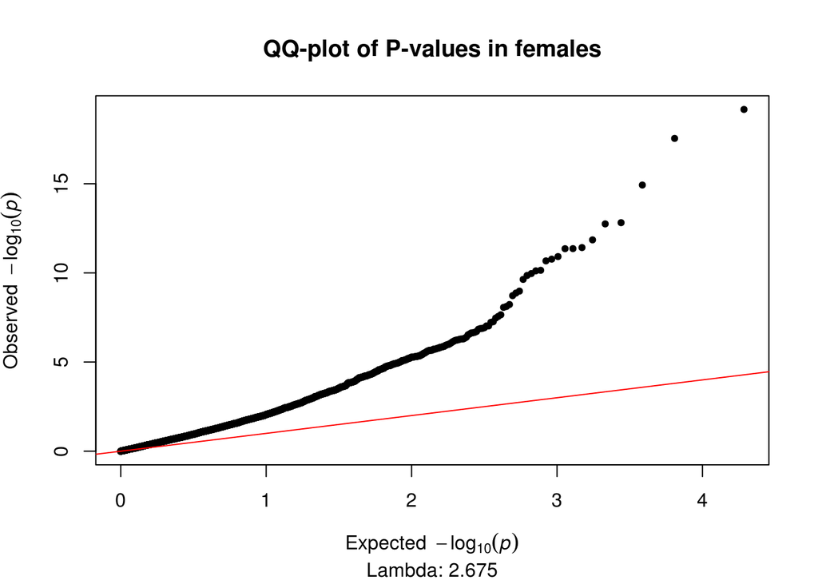